# Disater Analysis

Ishita Tripathi

2023-11-30

## Group18

```r
setwd("D:/Post graduation/Semester 1/Data Analysis/Coursework/Group 18")
```

#Libraries

```r
library(dplyr)
library(tidyr)
library(ggplot2)
library(randomForest)
library(car)
library(glmnet)
library(caret)
library(cluster)
```

## ASIA

Raw Data Reading

```r
turkey <- read.csv("turkey.csv",header=TRUE,na.strings=c(""))
colnames(turkey) <- gsub("^\\s+|\\s+$", "", colnames(turkey))
vietnam <- read.csv("vietnam.csv",header=TRUE,na.strings=c(""))
colnames(vietnam) <- gsub("^\\s+|\\s+$", "", colnames(vietnam))
yemen <- read.csv("yemen.csv",header=TRUE,na.strings=c(""))
colnames(yemen) <- gsub("^\\s+|\\s+$", "", colnames(yemen))
pakistan <- read.csv("pakistan.csv",header=TRUE,na.strings=c(""))
colnames(pakistan) <- gsub("^\\s+|\\s+$", "", colnames(pakistan))
srilanka <- read.csv("srilanka.csv",header=TRUE,na.strings=c(""))
colnames(srilanka ) <- gsub("^\\s+|\\s+$", "", colnames(yemen))
```

Data PreProcessing: Missing Values, Duplicate Values

```r
print("Total Missing Values: ")
```

```
## [1] "Total Missing Values: "
```

```r
print(paste("Turkey: ",sum(is.na(turkey))))
```

```
## [1] "Turkey:  1"
```

```r
print(paste("Vietnam: ",sum(is.na(vietnam))))
```

```
## [1] "Vietnam:  3"
```

```r
print(paste("Yemen: ",sum(is.na(yemen))))
```

```
## [1] "Yemen:  2"
```

```r
print(paste("Pakistan: ",sum(is.na(pakistan))))
```

```
## [1] "Pakistan:  3"
```

```r
print(paste("Srilanka: ",sum(is.na(srilanka))))
```

```
## [1] "Srilanka:  3"
```

```r
turkey <- na.omit(turkey, cols = c('Event'))
vietnam <- na.omit(vietnam, cols = c('Event', 'Directly.affected', 'Losses..USD'))
yemen <- na.omit(yemen, cols = c('Event', 'Losses..USD'))
pakistan <- na.omit(pakistan, cols = c('Event', 'Losses..USD' , 'Losses..Local'))
srilanka <- na.omit(srilanka, cols = c('Event', 'Directly.affected', 'Losses..USD'))
```

```r
print("Total Missing Values: ")
```

```
## [1] "Total Missing Values: "
```

```r
print(paste("Turkey: ",sum(is.na(turkey))))
```

```
## [1] "Turkey:  0"
```

```r
print(paste("Vietnam: ",sum(is.na(vietnam))))
```

```
## [1] "Vietnam:  0"
```

```r
print(paste("Yemen: ",sum(is.na(yemen))))
```

```
## [1] "Yemen:  0"
```

```r
print(paste("Pakistan: ",sum(is.na(pakistan))))
```

```
## [1] "Pakistan:  0"
```

```r
print(paste("Srilanka: ",sum(is.na(srilanka))))
```

```
## [1] "Srilanka:  0"
```

```r
print("Total Duplicate values")
```

```
## [1] "Total Duplicate values"
```

```r
print(paste("Turkey: ", sum(duplicated(turkey))))
```

```
## [1] "Turkey:  0"
```

```r
print(paste("Vietnam: ", sum(duplicated(vietnam))))
```

```
## [1] "Vietnam:  0"
```

```r
print(paste("Yemen: ", sum(duplicated(yemen))))
```

```
## [1] "Yemen:  0"
```

```r
print(paste("Pakistan: ",sum(duplicated(pakistan))))
```

```
## [1] "Pakistan:  0"
```

```r
print(paste("Srilanka: ",sum(duplicated(srilanka))))
```

```
## [1] "Srilanka:  0"
```

cleaning text in Event

```r
turkey$Event <- toupper(turkey$Event)
vietnam$Event <- toupper(vietnam$Event)
yemen$Event <- toupper(yemen$Event)
pakistan$Event <- toupper(pakistan$Event)
srilanka$Event <- toupper(srilanka$Event)
```

Data Tranformation

```r
turkey$Houses.Ruined <-turkey$Houses.Destroyed + turkey$Houses.Damaged
turkey$Affected <-turkey$Directly.affected + turkey$Indirectly.Affected

turkey$Monetary.LossUSD<-turkey$Losses..USD + turkey$Losses..Local * (0.035)
turkey$Monetary.LossUSD <- as.integer(turkey$Monetary.LossUSD)

# AS There were 19 values highter than e9
max_value <- max(turkey$Monetary.LossUSD, na.rm = TRUE)
turkey$Monetary.LossUSD[is.na(turkey$Monetary.LossUSD)] <- max_value
turkey = select(turkey, -5:-10)
head(turkey)
```

```
##   Year      Event DataCards Deaths Houses.Ruined Affected Monetary.LossUSD
## 1 1894 EARTHQUAKE         1   1500          1773    12500                0
## 2 1900 EARTHQUAKE         5    141          2056        0                0
## 3 1901 EARTHQUAKE         2      0          2104        0                0
## 4 1902 EARTHQUAKE         1      4          6000        0                0
## 5 1903 EARTHQUAKE         4   3857         20000        0                0
## 6 1905 EARTHQUAKE         1      0            15        0                0
```

```r
summary(turkey)
```

```
##      Year              Event             DataCards          Deaths
##  Length:596         Length:596         Min.   :  1.00   Min.   :    0.0
##  Class :character   Class :character   1st Qu.:  1.00   1st Qu.:    0.0
##  Mode  :character   Mode  :character   Median :  3.00   Median :    0.0
##                                        Mean   : 10.88   Mean   :  166.8
##                                        3rd Qu.: 10.00   3rd Qu.:   12.0
##                                        Max.   :205.00   Max.   :33065.0
##  Houses.Ruined         Affected        Monetary.LossUSD
##  Min.   :     0.0   Min.   :       0   Min.   :0.000e+00
##  1st Qu.:     0.0   1st Qu.:       0   1st Qu.:0.000e+00
##  Median :    10.0   Median :       0   Median :0.000e+00
##  Mean   :  2282.8   Mean   :   27217   Mean   :6.679e+07
##  3rd Qu.:   162.2   3rd Qu.:     211   3rd Qu.:0.000e+00
##  Max.   :377879.0   Max.   :15901844   Max.   :1.812e+09
```

```r
vietnam$Houses.Ruined <-vietnam$Houses.Destroyed + vietnam$Houses.Damaged
vietnam$Affected <-vietnam$Directly.affected + vietnam$Indirectly.Affected

vietnam$Monetary.LossUSD<-vietnam$Losses..USD + vietnam$Losses..Local * (0.00004)
vietnam$Monetary.LossUSD <- as.integer(vietnam$Monetary.LossUSD)

vietnam = select(vietnam, -5:-10)
head(vietnam)
```

```
##   Year       Event DataCards Deaths Houses.Ruined Affected Monetary.LossUSD
## 1 1989   HAILSTORM         2      9           884        0                0
## 2 1989       STORM         8    113         89223        0                0
## 3 1990 FLASH FLOOD         5    112           849    20000                0
## 4 1990       FLOOD         6     23          2755        0                0
## 5 1990   HAILSTORM         7     74          1326        0                0
## 6 1990       STORM         7     41          6796  1035300                0
```

```r
summary(vietnam)
```

```
##      Year              Event             DataCards         Deaths
##  Length:92          Length:92          Min.   : 1.00   Min.   :  0.00
##  Class :character   Class :character   1st Qu.: 6.00   1st Qu.: 13.75
##  Mode  :character   Mode  :character   Median :10.50   Median : 36.50
##                                        Mean   :15.98   Mean   :108.11
##                                        3rd Qu.:20.75   3rd Qu.:115.00
##                                        Max.   :75.00   Max.   :875.00
##  Houses.Ruined         Affected       Monetary.LossUSD
##  Min.   :     0.0   Min.   :      0   Min.   :       0
##  1st Qu.:   418.8   1st Qu.:      0   1st Qu.:       0
##  Median :  2866.0   Median :      0   Median :       0
##  Mean   : 14442.7   Mean   :  89600   Mean   : 1084676
##  3rd Qu.:  9709.2   3rd Qu.:      0   3rd Qu.:       0
##  Max.   :195823.0   Max.   :2388454   Max.   :86436800
```

```r
yemen$Houses.Ruined <-yemen$Houses.Destroyed + yemen$Houses.Damaged
yemen$Affected <-yemen$Directly.affected + yemen$Indirectly.Affected

yemen$Monetary.LossUSD<-yemen$Losses..USD + yemen$Losses..Local * (0.0040)
yemen$Monetary.LossUSD <- as.integer(yemen$Monetary.LossUSD)

yemen = select(yemen, -5:-10)
head(yemen)
```

```
##   Year         Event DataCards Deaths Houses.Ruined Affected Monetary.LossUSD
## 1 1979    SUBSIDENCE         1      0             0        0                0
## 2 1981  LIQUEFACTION         1      0            73        0                0
## 3 1981 THUNDER STORM         1      0             1        0                0
## 4 1982    EARTHQUAKE         2   2500         12000        0                0
## 5 1982  LIQUEFACTION         2      0          2000        0                0
## 6 1982         RAINS         1      0            20        0                0
```

```r
summary(yemen)
```

```
##      Year              Event             DataCards           Deaths
##  Length:188         Length:188         Min.   :   1.00   Min.   :   0.00
##  Class :character   Class :character   1st Qu.:   1.00   1st Qu.:   0.00
##  Mode  :character   Mode  :character   Median :   3.00   Median :   1.00
##                                        Mean   :  37.67   Mean   :  41.24
##                                        3rd Qu.:   9.00   3rd Qu.:   8.00
##                                        Max.   :1299.00   Max.   :2500.00
##  Houses.Ruined        Affected       Monetary.LossUSD
##  Min.   :    0.0   Min.   :    0.0   Min.   :       0
##  1st Qu.:    0.0   1st Qu.:    0.0   1st Qu.:       0
##  Median :    0.0   Median :    0.0   Median :       0
##  Mean   :  252.8   Mean   :  162.5   Mean   :  548310
##  3rd Qu.:    1.0   3rd Qu.:    0.0   3rd Qu.:       0
##  Max.   :12000.0   Max.   :18000.0   Max.   :52848884
```

```r
pakistan$Houses.Ruined <-pakistan$Houses.Destroyed + pakistan$Houses.Damaged
pakistan$Affected <-pakistan$Directly.affected + pakistan$Indirectly.Affected

pakistan$Monetary.LossUSD<-pakistan$Losses..USD + pakistan$Losses..Local * (0.003)
pakistan$Monetary.LossUSD <- as.integer(pakistan$Monetary.LossUSD)

pakistan = select(pakistan, -5:-10)
head(pakistan)
```

```
##   Year       Event DataCards Deaths Houses.Ruined Affected Monetary.LossUSD
## 1 1980   AVALANCHE         1      3            22        0                0
## 2 1980  EARTHQUAKE         7    254          2631      277                0
## 3 1980    EPIDEMIC        15     44             0      625                0
## 4 1980 FLASH FLOOD        13     69           367     7928                0
## 5 1980       FLOOD        25    158          1571    15595                0
## 6 1980   LANDSLIDE         7     32            17      175                0
```

```r
summary(pakistan)
```

```
##      Year              Event             DataCards          Deaths
##  Length:461         Length:461         Min.   :  1.00   Min.   :    0.0
##  Class :character   Class :character   1st Qu.:  3.00   1st Qu.:    7.0
##  Mode  :character   Mode  :character   Median :  7.00   Median :   49.0
##                                        Mean   : 15.79   Mean   :  286.5
##                                        3rd Qu.: 15.00   3rd Qu.:  144.0
##                                        Max.   :203.00   Max.   :38319.0
##  Houses.Ruined        Affected       Monetary.LossUSD
##  Min.   :      0   Min.   :      0   Min.   :0
##  1st Qu.:      2   1st Qu.:      0   1st Qu.:0
##  Median :     22   Median :    730   Median :0
##  Mean   :  13546   Mean   :  79847   Mean   :0
##  3rd Qu.:    446   3rd Qu.:   8159   3rd Qu.:0
##  Max.   :1377063   Max.   :2614437   Max.   :0
```

```r
srilanka$Houses.Ruined <-srilanka$Houses.Destroyed + srilanka$Houses.Damaged
srilanka$Affected <-srilanka$Directly.affected + srilanka$Indirectly.Affected

srilanka$Monetary.LossUSD<-srilanka$Losses..USD + srilanka$Losses..Local * (0.003)
srilanka$Monetary.LossUSD <- as.integer(srilanka$Monetary.LossUSD)

srilanka = select(srilanka, -5:-10)
head(srilanka)
```

```
##   Year         Event DataCards Deaths Houses.Ruined Affected Monetary.LossUSD
## 1 1965          GALE         1      0             6       30                0
## 2 1968      EPIDEMIC         1      0             0        9                0
## 3 1974 ANIMAL ATTACK         3      2             0        0                0
## 4 1974       DROUGHT        11      0             0     6737                0
## 5 1974      EPIDEMIC      1794    324             0    12213                0
## 6 1974          FIRE         3      0             0        0                0
```

```r
summary(srilanka)
```

```
##      Year              Event             DataCards          Deaths
##  Length:751         Length:751         Min.   :   1.0   Min.   :    0.00
##  Class :character   Class :character   1st Qu.:   2.0   1st Qu.:    0.00
##  Mode  :character   Mode  :character   Median :   8.0   Median :    0.00
##                                        Mean   : 173.3   Mean   :   49.19
##                                        3rd Qu.:  38.0   3rd Qu.:    4.00
##                                        Max.   :4797.0   Max.   :30959.00
##  Houses.Ruined         Affected       Monetary.LossUSD
##  Min.   :     0.0   Min.   :      0   Min.   :    0.0
##  1st Qu.:     0.0   1st Qu.:      0   1st Qu.:    0.0
##  Median :     1.0   Median :     74   Median :    0.0
##  Mean   :   915.4   Mean   :  56381   Mean   :  105.2
##  3rd Qu.:    45.5   3rd Qu.:   3262   3rd Qu.:    0.0
##  Max.   :105154.0   Max.   :3128156   Max.   :48390.0
```

Feature Addition 1

```r
add_Event_Severity <- function(data) {
  data$Event_Severity <- data$Deaths / data$DataCards

  a_countries <- c("turkey", "vietnam", "pakistan")
  b_countries <- c("yemen", "srilanka")

  for (country in a_countries) {
    data$Event_Severity[data$Country == country & data$Event_Severity > 1] <- 1
    data$Event_Severity[data$Country == country & data$Event_Severity < 0.5] <- 0.5
  }


  for (country in b_countries) {
    data$Event_Severity[data$Country == country & data$Event_Severity > 2] <- 2
    data$Event_Severity[data$Country == country & data$Event_Severity < 1] <- 1
  }
  data$Event_Severity <- round(data$Event_Severity * 100)
  return(data$Event_Severity)
}

turkey$Event_Severity <- add_Event_Severity(turkey)
vietnam$Event_Severity <- add_Event_Severity(vietnam)
pakistan$Event_Severity <- add_Event_Severity(pakistan)
yemen$Event_Severity<- add_Event_Severity(yemen)
srilanka$Event_Severity <- add_Event_Severity(srilanka)
head(turkey)
```

```
##   Year      Event DataCards Deaths Houses.Ruined Affected Monetary.LossUSD
## 1 1894 EARTHQUAKE         1   1500          1773    12500                0
## 2 1900 EARTHQUAKE         5    141          2056        0                0
## 3 1901 EARTHQUAKE         2      0          2104        0                0
## 4 1902 EARTHQUAKE         1      4          6000        0                0
## 5 1903 EARTHQUAKE         4   3857         20000        0                0
## 6 1905 EARTHQUAKE         1      0            15        0                0
##   Event_Severity
## 1         150000
## 2           2820
## 3              0
## 4            400
## 5          96425
## 6              0
```

Feature Addition 2

```r
turkey$Event_factor<-as.integer(as.factor(turkey$Event))
vietnam$Event_factor<-as.integer(as.factor(vietnam$Event))
yemen$Event_factor<-as.integer(as.factor(yemen$Event))
pakistan$Event_factor<-as.integer(as.factor(pakistan$Event))
srilanka$Event_factor<-as.integer(as.factor(srilanka$Event))
```

Write Cleaned csv

```r
write.csv(turkey, file = "turkey_cleaned.csv", row.names = FALSE)
write.csv(vietnam, file = "vietnam_cleaned.csv", row.names = FALSE)
write.csv(yemen, file = "yemen_cleaned.csv", row.names = FALSE)
write.csv(pakistan, file = "pakistan_cleaned.csv", row.names = FALSE)
write.csv(srilanka, file = "srilanka_cleaned.csv", row.names = FALSE)
```

Read Cleaned csv

```r
turkey_c <- read.csv("turkey_cleaned.csv",header=TRUE)
vietnam_c <- read.csv("vietnam_cleaned.csv",header=TRUE)
yemen_c <- read.csv("yemen_cleaned.csv",header=TRUE)
pakistan_c <- read.csv("pakistan_cleaned.csv",header=TRUE)
srilanka_c <- read.csv("srilanka_cleaned.csv",header=TRUE)
```

Combining into one continent

```r
asia <- rbind(turkey_c, vietnam_c, yemen_c, pakistan_c, srilanka_c)
```

#Preprocessing Visualization (Asia)

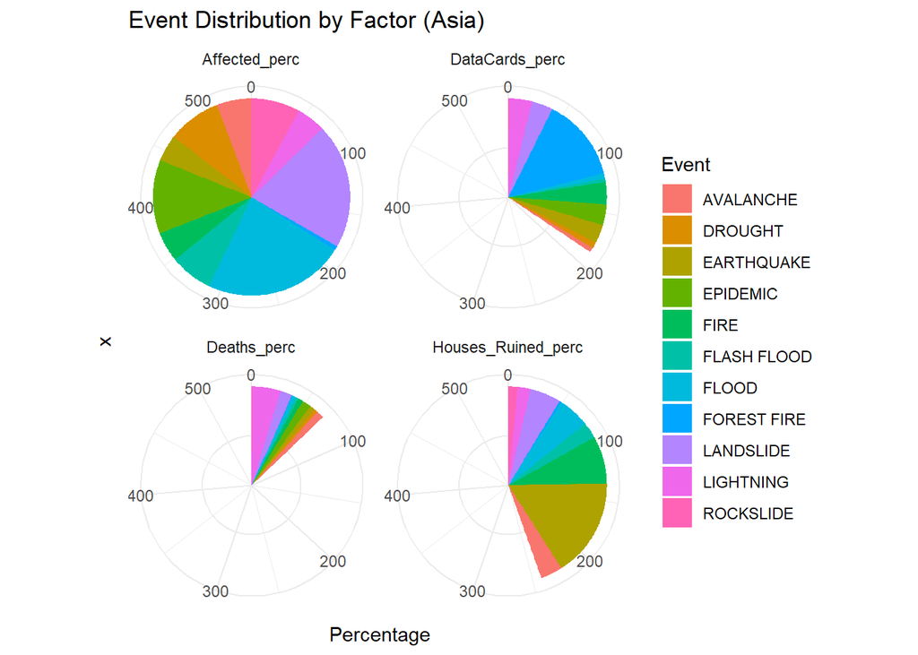

```r
asia_perc <- asia %>%
  mutate(
    Total = DataCards + Deaths + `Houses.Ruined` + Affected,
    DataCards_perc = DataCards / Total,
    Deaths_perc = Deaths / Total,
    Houses_Ruined_perc = `Houses.Ruined` / Total,
    Affected_perc = Affected / Total
  ) %>%
  select(Event, DataCards_perc, Deaths_perc, Houses_Ruined_perc, Affected_perc)

asia_long <- asia_perc %>%
  pivot_longer(cols = -Event, names_to = "Factor", values_to = "Percentage")

threshold <- 50

filtered_asia_long <- asia_long %>%
  group_by(Event) %>%
  summarise(Total_Percentage = sum(Percentage)) %>%
  filter(Total_Percentage > threshold) %>%
  inner_join(asia_long, by = "Event") %>%
  ungroup()

ggplot(filtered_asia_long, aes(x = "", y = Percentage, fill = Event)) +
  geom_bar(stat = "identity", width = 1) +
  facet_wrap(~Factor) +
  coord_polar(theta = "y") +
  theme_minimal() +
  ggtitle("Event Distribution by Factor (Asia)")
```

Preprocessing Visualization(individual)

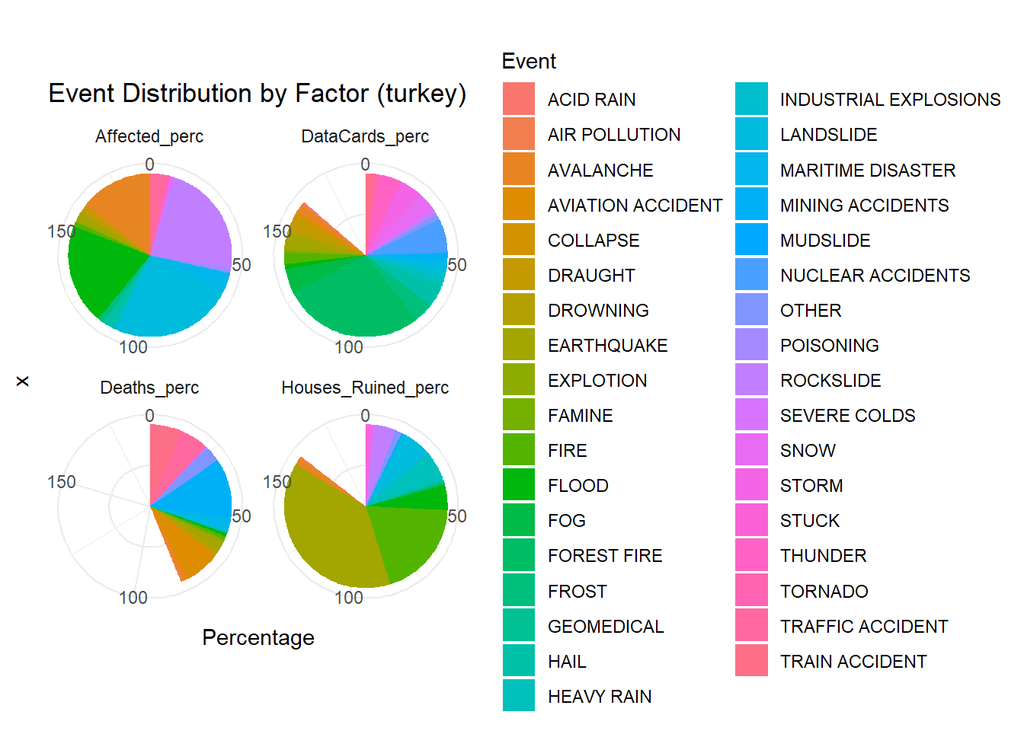

```r
turkey_c <- turkey_c %>%
  mutate(Total = DataCards + Deaths + Houses.Ruined + Affected)

turkey_c_perc <- turkey_c %>%
  mutate(
    DataCards_perc = DataCards / Total,
    Deaths_perc = Deaths / Total,
    Houses_Ruined_perc = Houses.Ruined / Total,
    Affected_perc = Affected / Total
  ) %>%
  select(Event, DataCards_perc, Deaths_perc, Houses_Ruined_perc, Affected_perc)

turkey_c_long <- turkey_c_perc %>%
  pivot_longer(cols = -Event, names_to = "Factor", values_to = "Percentage")

ggplot(turkey_c_long, aes(x = "", y = Percentage, fill = Event)) +
  geom_bar(stat = "identity", width = 1) +
  facet_wrap(~Factor) +
  coord_polar(theta = "y") +
  theme_minimal() +
  ggtitle("Event Distribution by Factor (turkey)")
```

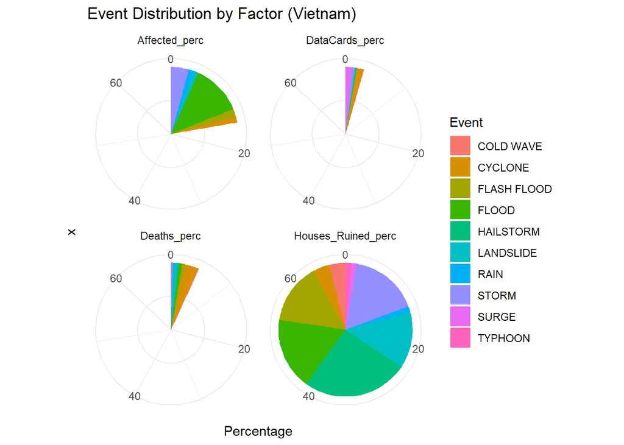

```r
 vietnam_c <- vietnam_c %>%
  mutate(Total = DataCards + Deaths + Houses.Ruined + Affected)

 vietnam_c_perc <- vietnam_c %>%
  mutate(
    DataCards_perc = DataCards / Total,
    Deaths_perc = Deaths / Total,
    Houses_Ruined_perc = Houses.Ruined / Total,
    Affected_perc = Affected / Total
  ) %>%
  select(Event, DataCards_perc, Deaths_perc, Houses_Ruined_perc, Affected_perc)

 vietnam_c_long <-  vietnam_c_perc %>%
  pivot_longer(cols = -Event, names_to = "Factor", values_to = "Percentage")

ggplot( vietnam_c_long, aes(x = "", y = Percentage, fill = Event)) +
  geom_bar(stat = "identity", width = 1) +
  facet_wrap(~Factor) +
  coord_polar(theta = "y") +
  theme_minimal() +
  ggtitle("Event Distribution by Factor (Vietnam)")
```

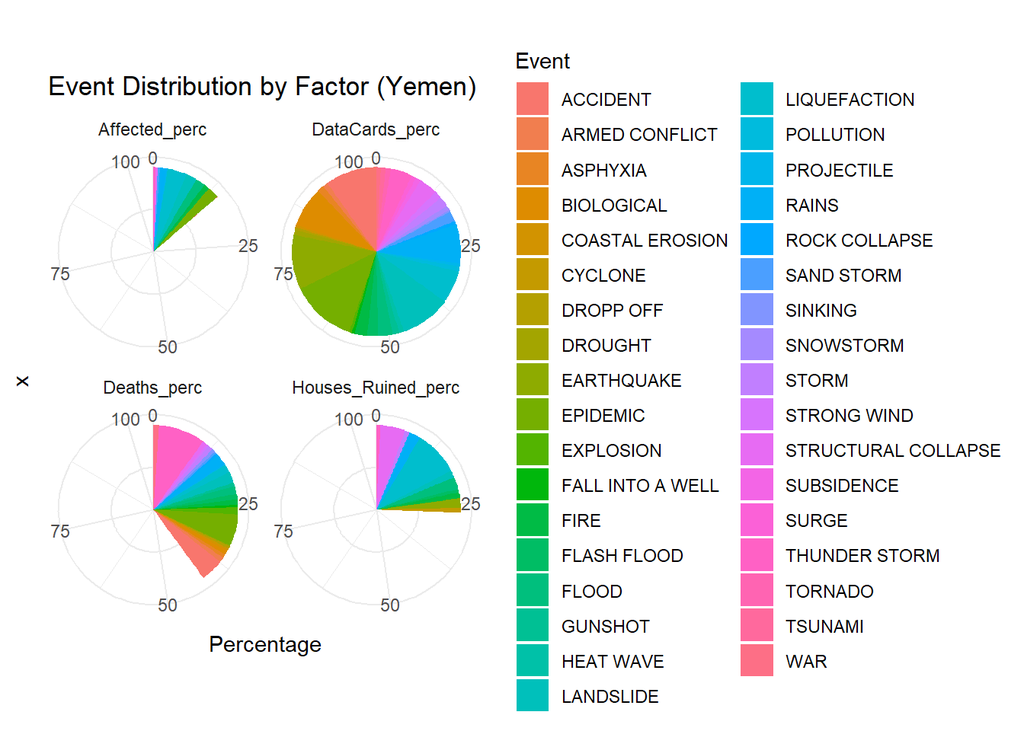

```r
yemen_c <- yemen_c %>%
  mutate(Total = DataCards + Deaths + Houses.Ruined + Affected)

 yemen_c_perc <- yemen_c %>%
  mutate(
    DataCards_perc = DataCards / Total,
    Deaths_perc = Deaths / Total,
    Houses_Ruined_perc = Houses.Ruined / Total,
    Affected_perc = Affected / Total
  ) %>%
  select(Event, DataCards_perc, Deaths_perc, Houses_Ruined_perc, Affected_perc)

 yemen_c_long <-  yemen_c_perc %>%
  pivot_longer(cols = -Event, names_to = "Factor", values_to = "Percentage")

ggplot( yemen_c_long, aes(x = "", y = Percentage, fill = Event)) +
  geom_bar(stat = "identity", width = 1) +
  facet_wrap(~Factor) +
  coord_polar(theta = "y") +
  theme_minimal() +
  ggtitle("Event Distribution by Factor (Yemen)")
```

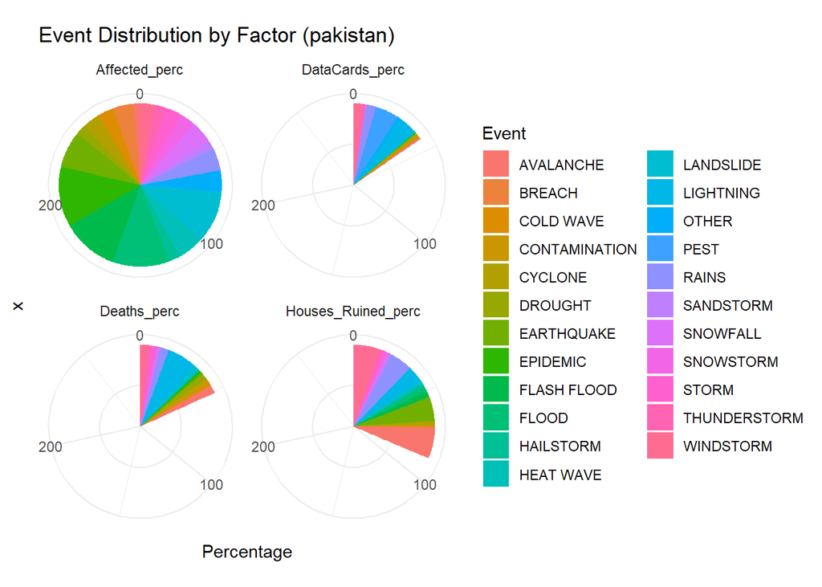

```r
pakistan_c <- pakistan_c  %>%
  mutate(Total = DataCards + Deaths + Houses.Ruined + Affected)

 pakistan_c_perc <- pakistan_c  %>%
  mutate(
    DataCards_perc = DataCards / Total,
    Deaths_perc = Deaths / Total,
    Houses_Ruined_perc = Houses.Ruined / Total,
    Affected_perc = Affected / Total
  ) %>%
  select(Event, DataCards_perc, Deaths_perc, Houses_Ruined_perc, Affected_perc)

 pakistan_c_long <-  pakistan_c_perc %>%
  pivot_longer(cols = -Event, names_to = "Factor", values_to = "Percentage")

ggplot( pakistan_c_long, aes(x = "", y = Percentage, fill = Event)) +
  geom_bar(stat = "identity", width = 1) +
  facet_wrap(~Factor) +
  coord_polar(theta = "y") +
  theme_minimal() +
  ggtitle("Event Distribution by Factor (pakistan)")
```

[figure not shown]

```r
srilanka_c <- srilanka_c %>%
  mutate(Total = DataCards + Deaths + Houses.Ruined + Affected)

 srilanka_c_perc <- srilanka_c %>%
  mutate(
    DataCards_perc = DataCards / Total,
    Deaths_perc = Deaths / Total,
    Houses_Ruined_perc = Houses.Ruined / Total,
    Affected_perc = Affected/ Total
  ) %>%
  select(Event, DataCards_perc, Deaths_perc, Houses_Ruined_perc, Affected_perc)

 srilanka_c_long <-  srilanka_c_perc %>%
  pivot_longer(cols = -Event, names_to = "Factor", values_to = "Percentage")

ggplot( srilanka_c_long, aes(x = "", y = Percentage, fill = Event)) +
  geom_bar(stat = "identity", width = 1) +
  facet_wrap(~Factor) +
  coord_polar(theta = "y") +
  theme_minimal() +
  ggtitle("Event Distribution by Factor (Srilanka)")
```

Split(Asia) and parameter

```r
# Get only numeric Values
numeric_data <- asia[, sapply(asia, is.numeric)]

# find PCA
scaled_data <- scale(numeric_data)
pca_result <- prcomp(scaled_data, center = TRUE, scale. = TRUE)
summary(pca_result)
```

```
## Importance of components:
##                           PC1    PC2    PC3    PC4    PC5    PC6     PC7
## Standard deviation     1.4510 1.0624 1.0135 1.0008 0.9777 0.9175 0.78356
## Proportion of Variance 0.2632 0.1411 0.1284 0.1252 0.1195 0.1052 0.07675
## Cumulative Proportion  0.2632 0.4042 0.5326 0.6578 0.7773 0.8826 0.95931
##                            PC8
## Standard deviation     0.57057
## Proportion of Variance 0.04069
## Cumulative Proportion  1.00000
```

```r
formula <- numeric_data$Deaths ~ numeric_data$DataCards + numeric_data$Deaths + numeric_data$Monetary.LossUSD + numeric_data$Event_Severity + numeric_data$Houses.Ruined + numeric_data$Affected
  model <- lm(formula, data = numeric_data)

  vif_result <- car::vif(model)

  cat("\n","VIF results for Deaths", ":\n")
```

```
##
##  VIF results for Deaths :
```

```r
  print(vif_result)
```

```
##                                   GVIF Df GVIF^(1/(2*Df))
## numeric_data$DataCards        1.001121  1        1.000560
## numeric_data$Deaths           1.239666  0             Inf
## numeric_data$Monetary.LossUSD 1.032591  1        1.016165
## numeric_data$Event_Severity   1.107786  1        1.052514
## numeric_data$Houses.Ruined    1.109179  1        1.053176
## numeric_data$Affected         1.235341  1        1.111459
```

```r
  cat("\n")
```

```r
#check for correlation matrix
cor_matrix <- cor(numeric_data)
print("Correlation matrix ")
```

```
## [1] "Correlation matrix "
```

```r
print(cor_matrix)
```

```
##                           Year     DataCards       Deaths Houses.Ruined
## Year              1.0000000000  0.0344797187 -0.055014404  0.0261648620
## DataCards         0.0344797187  1.0000000000 -0.004511555  0.0007679541
## Deaths           -0.0550144042 -0.0045115551  1.000000000  0.2762375990
## Houses.Ruined     0.0261648620  0.0007679541  0.276237599  1.0000000000
## Affected          0.0485475613  0.0222210207  0.378501365  0.3113000710
## Monetary.LossUSD -0.0003304129 -0.0086274514  0.055375621  0.0343570056
## Event_Severity   -0.1498355017 -0.0132848201  0.649714915  0.1267788210
## Event_factor      0.0552831495 -0.0124988927 -0.036961186 -0.0471297338
##                     Affected Monetary.LossUSD Event_Severity Event_factor
## Year              0.04854756    -0.0003304129    -0.14983550   0.05528315
## DataCards         0.02222102    -0.0086274514    -0.01328482  -0.01249889
## Deaths            0.37850137     0.0553756215     0.64971492  -0.03696119
## Houses.Ruined     0.31130007     0.0343570056     0.12677882  -0.04712973
## Affected          1.00000000     0.1726409292     0.30779548  -0.04798512
## Monetary.LossUSD  0.17264093     1.0000000000     0.08541792  -0.04022166
## Event_Severity    0.30779548     0.0854179214     1.00000000  -0.05497875
## Event_factor     -0.04798512    -0.0402216621    -0.05497875   1.00000000
```

```r
set.seed(123)
split_indices <- createDataPartition(asia$Year, p = 0.7, list = FALSE)

training_data_asia <- numeric_data[split_indices, ]
testing_data_asia <- numeric_data[-split_indices, ]
```

```r
train_data <- training_data_asia
test_data <-  testing_data_asia

X_train <- as.matrix(subset(train_data, select =- c(Deaths)))
y_train <- train_data$Deaths
X_test <- as.matrix(subset(test_data, select = - c(Deaths)))
y_test <- test_data$Deaths

X_train_std <- scale(X_train)
X_test_std <- scale(X_test)

enet_model_combined<- cv.glmnet(X_train_std, y_train, alpha = 0.5)

best_lambda <- enet_model_combined$lambda.min

y_pred <- predict(enet_model_combined, newx = X_test_std, s = best_lambda)

mse <- mean((y_pred - y_test)^2)
rsquared <- cor(y_pred, y_test)^2

cat("Best Lambda:", best_lambda, "\n")
```

```
## Best Lambda: 145.7942
```

```r
cat("Mean Squared Error:", mse, "\n")
```

```
## Mean Squared Error: 601791.4
```

```r
cat("R-squared:", rsquared, "\n")
```

```
## R-squared: 0.4741821
```

Model 2 random forest on death ~ !Event - 40% accuracy

```r
rf_model_complex <- randomForest(
  X_train, y_train,
  ntree = 1000,
  mtry = sqrt(ncol(X_train)),
  max_depth = NULL
)

y_pred_rf_complex <- predict(rf_model_complex, X_test, type = "response")
mse_rf_complex <- mean((y_pred_rf_complex - y_test)^2)
rsquared_rf_complex <- cor(y_pred_rf_complex, y_test)^2

cat("Random Forest- Mean Squared Error:", mse_rf_complex, "\n")
```

```
## Random Forest- Mean Squared Error: 198384.4
```

```r
cat("Random Forest - R-squared:", rsquared_rf_complex, "\n")
```

```
## Random Forest - R-squared: 0.4096434
```

Split(individual)

```r
set.seed(123)
split_indices <- createDataPartition(turkey_c$Year, p = 0.7, list = FALSE)

training_data_turkey <- turkey_c[split_indices, ]
testing_data_turkey <- turkey_c[-split_indices, ]
```

```r
set.seed(123)
split_indices <- createDataPartition(vietnam_c$Year, p = 0.7, list = FALSE)
training_data_vietnam <- vietnam_c[split_indices, ]
testing_data_vietnam <- vietnam_c[-split_indices, ]
```

```r
set.seed(123)
split_indices <- createDataPartition(yemen_c$Year, p = 0.7, list = FALSE)
training_data_yemen <- yemen_c[split_indices, ]
testing_data_yemen <- yemen_c[-split_indices, ]
```

```r
set.seed(123)
split_indices <- createDataPartition(pakistan_c$Year, p = 0.7, list = FALSE)
training_data_pakistan <- pakistan_c[split_indices, ]
testing_data_pakistan <- pakistan_c[-split_indices, ]
```

```r
set.seed(123)
split_indices <- createDataPartition(srilanka_c$Year, p = 0.7, list = FALSE)
training_data_srilanka <- srilanka_c[split_indices, ]
testing_data_srilanka <- srilanka_c[-split_indices, ]
```

PCA VIF AND CORR MATRIX (indivual)

```r
turkey_no_event <- turkey_c[, !names(turkey_c) %in% c("Event")]
scaled_data <- scale(turkey_no_event)
pca_result <- prcomp(scaled_data, center = TRUE, scale. = TRUE)
summary(pca_result)
```

```
## Importance of components:
##                           PC1    PC2    PC3    PC4     PC5     PC6     PC7
## Standard deviation     1.9492 1.2313 1.0687 1.0384 0.85932 0.80532 0.25943
## Proportion of Variance 0.4222 0.1685 0.1269 0.1198 0.08205 0.07206 0.00748
## Cumulative Proportion  0.4222 0.5906 0.7175 0.8374 0.91939 0.99145 0.99893
##                            PC8       PC9
## Standard deviation     0.09808 9.154e-16
## Proportion of Variance 0.00107 0.000e+00
## Cumulative Proportion  1.00000 1.000e+00
```

```r
formula <- turkey_c$Deaths ~ turkey_c$DataCards + turkey_c$Deaths + turkey_c$Monetary.LossUSD + turkey_c$Event_Severity + turkey_c$Houses.Ruined + turkey_c$Affected
  model <- lm(formula, data = turkey_c)

  vif_result <- car::vif(model)

  cat("\n","VIF results for Deaths", ":\n")
```

```
##
##  VIF results for Deaths :
```

```r
  print(vif_result)
```

```
##                                GVIF Df GVIF^(1/(2*Df))
## turkey_c$DataCards         1.102769  1        1.050128
## turkey_c$Deaths           16.047078  0             Inf
## turkey_c$Monetary.LossUSD  1.158418  1        1.076298
## turkey_c$Event_Severity    2.367413  1        1.538640
## turkey_c$Houses.Ruined    10.105481  1        3.178912
## turkey_c$Affected          7.034644  1        2.652290
```

```r
  cat("\n")
```

```r
cor_matrix <- cor(turkey_c[c("DataCards", "Deaths", "Monetary.LossUSD", "Event_Severity", "Houses.Ruined", "Affected")])
print("Correlation matrix ")
```

```
## [1] "Correlation matrix "
```

```r
print(cor_matrix)
```

```
##                    DataCards      Deaths Monetary.LossUSD Event_Severity
## DataCards         1.00000000 -0.03258618       0.28650141    -0.03956167
## Deaths           -0.03258618  1.00000000       0.08817371     0.98361699
## Monetary.LossUSD  0.28650141  0.08817371       1.00000000     0.07313396
## Event_Severity   -0.03956167  0.98361699       0.07313396     1.00000000
## Houses.Ruined    -0.03654990  0.70759242       0.21232640     0.62506107
## Affected         -0.01205248  0.46407637       0.21577984     0.36258799
##                  Houses.Ruined    Affected
## DataCards           -0.0365499 -0.01205248
## Deaths               0.7075924  0.46407637
## Monetary.LossUSD     0.2123264  0.21577984
## Event_Severity       0.6250611  0.36258799
## Houses.Ruined        1.0000000  0.89179612
## Affected             0.8917961  1.00000000
```

```r
vietnam_no_event <- vietnam_c[, !names(vietnam_c) %in% c("Event")]
scaled_data <- scale(turkey_no_event)
pca_result <- prcomp(scaled_data, center = TRUE, scale. = TRUE)
summary(pca_result)
```

```
## Importance of components:
##                           PC1    PC2    PC3    PC4     PC5     PC6     PC7
## Standard deviation     1.9492 1.2313 1.0687 1.0384 0.85932 0.80532 0.25943
## Proportion of Variance 0.4222 0.1685 0.1269 0.1198 0.08205 0.07206 0.00748
## Cumulative Proportion  0.4222 0.5906 0.7175 0.8374 0.91939 0.99145 0.99893
##                            PC8       PC9
## Standard deviation     0.09808 9.154e-16
## Proportion of Variance 0.00107 0.000e+00
## Cumulative Proportion  1.00000 1.000e+00
```

```r
formula <- vietnam_c$Deaths ~ vietnam_c$DataCards + vietnam_c$Deaths + vietnam_c$Monetary.LossUSD + vietnam_c$Event_Severity + vietnam_c$Houses.Ruined + vietnam_c$Affected
  model <- lm(formula, data = turkey_c)

  vif_result <- car::vif(model)

  cat("\n","VIF results for Deaths", ":\n")
```

```
##
##  VIF results for Deaths :
```

```r
  print(vif_result)
```

```
##                                GVIF Df GVIF^(1/(2*Df))
## vietnam_c$DataCards        1.315111  1        1.146783
## vietnam_c$Deaths           1.944891  0             Inf
## vietnam_c$Monetary.LossUSD 1.404872  1        1.185273
## vietnam_c$Event_Severity   1.054341  1        1.026811
## vietnam_c$Houses.Ruined    1.662489  1        1.289375
## vietnam_c$Affected         1.093065  1        1.045498
```

```r
  cat("\n")
```

```r
cor_matrix <- cor(vietnam_c[c("DataCards", "Deaths", "Monetary.LossUSD", "Event_Severity", "Houses.Ruined", "Affected")])
print("Correlation matrix ")
```

```
## [1] "Correlation matrix "
```

```r
print(cor_matrix)
```

```
##                    DataCards      Deaths Monetary.LossUSD Event_Severity
## DataCards         1.00000000  0.73842547      -0.01270774     0.08002147
## Deaths            0.73842547  1.00000000      -0.03492199     0.50447030
## Monetary.LossUSD -0.01270774 -0.03492199       1.00000000    -0.03942195
## Event_Severity    0.08002147  0.50447030      -0.03942195     1.00000000
## Houses.Ruined     0.38539186  0.35055575       0.48590477     0.08326066
## Affected          0.21559867  0.24409741      -0.03278637     0.19601371
##                  Houses.Ruined    Affected
## DataCards           0.38539186  0.21559867
## Deaths              0.35055575  0.24409741
## Monetary.LossUSD    0.48590477 -0.03278637
## Event_Severity      0.08326066  0.19601371
## Houses.Ruined       1.00000000  0.02102411
## Affected            0.02102411  1.00000000
```

```r
yemen_no_event <- yemen_c[, !names(yemen_c) %in% c("Event")]
scaled_data <- scale(yemen_no_event)
pca_result <- prcomp(scaled_data, center = TRUE, scale. = TRUE)
summary(pca_result)
```

```
## Importance of components:
##                           PC1    PC2    PC3    PC4     PC5     PC6     PC7
## Standard deviation     1.7823 1.2740 1.1322 0.9655 0.91431 0.89487 0.54137
## Proportion of Variance 0.3529 0.1803 0.1424 0.1036 0.09289 0.08898 0.03256
## Cumulative Proportion  0.3529 0.5333 0.6757 0.7793 0.87217 0.96115 0.99371
##                            PC8       PC9
## Standard deviation     0.23791 8.218e-16
## Proportion of Variance 0.00629 0.000e+00
## Cumulative Proportion  1.00000 1.000e+00
```

```r
formula <- yemen_c$Deaths ~ yemen_c$DataCards + yemen_c$Deaths + yemen_c$Monetary.LossUSD + yemen_c$Event_Severity + yemen_c$Houses.Ruined + yemen_c$Affected
  model <- lm(formula, data = yemen_c)

  vif_result <- car::vif(model)

  cat("\n","VIF results for Deaths", ":\n")
```

```
##
##  VIF results for Deaths :
```

```r
  print(vif_result)
```

```
##                              GVIF Df GVIF^(1/(2*Df))
## yemen_c$DataCards        1.001606  1        1.000803
## yemen_c$Deaths           3.058866  0             Inf
## yemen_c$Monetary.LossUSD 1.443985  1        1.201659
## yemen_c$Event_Severity   2.066982  1        1.437700
## yemen_c$Houses.Ruined    2.511406  1        1.584742
## yemen_c$Affected         1.085435  1        1.041842
```

```r
  cat("\n")
```

```r
cor_matrix <- cor(turkey_c[c("DataCards", "Deaths", "Monetary.LossUSD", "Event_Severity", "Houses.Ruined", "Affected")])
print("Correlation matrix ")
```

```
## [1] "Correlation matrix "
```

```r
print(cor_matrix)
```

```
##                    DataCards      Deaths Monetary.LossUSD Event_Severity
## DataCards         1.00000000 -0.03258618       0.28650141    -0.03956167
## Deaths           -0.03258618  1.00000000       0.08817371     0.98361699
## Monetary.LossUSD  0.28650141  0.08817371       1.00000000     0.07313396
## Event_Severity   -0.03956167  0.98361699       0.07313396     1.00000000
## Houses.Ruined    -0.03654990  0.70759242       0.21232640     0.62506107
## Affected         -0.01205248  0.46407637       0.21577984     0.36258799
##                  Houses.Ruined    Affected
## DataCards           -0.0365499 -0.01205248
## Deaths               0.7075924  0.46407637
## Monetary.LossUSD     0.2123264  0.21577984
## Event_Severity       0.6250611  0.36258799
## Houses.Ruined        1.0000000  0.89179612
## Affected             0.8917961  1.00000000
```

```r
pakistan_no_event <- pakistan_c[, !names(pakistan_c) %in% c("Event", "Monetary.LossUSD")]
scaled_data <- scale(pakistan_no_event)
pca_result <- prcomp(scaled_data, center = TRUE, scale. = TRUE)
summary(pca_result)
```

```
## Importance of components:
##                           PC1    PC2    PC3    PC4     PC5     PC6    PC7
## Standard deviation     1.8687 1.1818 0.9961 0.9757 0.82689 0.57857 0.3857
## Proportion of Variance 0.4365 0.1746 0.1240 0.1190 0.08547 0.04184 0.0186
## Cumulative Proportion  0.4365 0.6111 0.7351 0.8541 0.93956 0.98140 1.0000
##                              PC8
## Standard deviation     3.994e-16
## Proportion of Variance 0.000e+00
## Cumulative Proportion  1.000e+00
```

```r
formula <- pakistan_c$Deaths ~ pakistan_c$DataCards + pakistan_c$Deaths + pakistan_c$Event_Severity + pakistan_c$Houses.Ruined + pakistan_c$Affected
  model <- lm(formula, data = pakistan_c)

  vif_result <- car::vif(model)

  cat("\n","VIF results for Deaths", ":\n")
```

```
##
##  VIF results for Deaths :
```

```r
  print(vif_result)
```

```
##                               GVIF Df GVIF^(1/(2*Df))
## pakistan_c$DataCards      2.025023  1        1.423033
## pakistan_c$Deaths         2.504744  0             Inf
## pakistan_c$Event_Severity 1.162658  1        1.078266
## pakistan_c$Houses.Ruined  1.264417  1        1.124463
## pakistan_c$Affected       2.378151  1        1.542126
```

```r
  cat("\n")
```

```r
cor_matrix <- cor(pakistan_c[c("DataCards", "Deaths", "Monetary.LossUSD", "Event_Severity", "Houses.Ruined", "Affected")])
print("Correlation matrix ")
```

```
## [1] "Correlation matrix "
```

```r
print(cor_matrix)
```

```
##                   DataCards    Deaths Monetary.LossUSD Event_Severity
## DataCards        1.00000000 0.3033786               NA     0.08429092
## Deaths           0.30337858 1.0000000               NA     0.81654472
## Monetary.LossUSD         NA        NA                1             NA
## Event_Severity   0.08429092 0.8165447               NA     1.00000000
## Houses.Ruined    0.36152017 0.2790103               NA     0.17794799
## Affected         0.69402042 0.4953112               NA     0.31793845
##                  Houses.Ruined  Affected
## DataCards            0.3615202 0.6940204
## Deaths               0.2790103 0.4953112
## Monetary.LossUSD            NA        NA
## Event_Severity       0.1779480 0.3179385
## Houses.Ruined        1.0000000 0.4490146
## Affected             0.4490146 1.0000000
```

```r
srilanka_no_event <- srilanka_c[, !names(srilanka_c) %in% c("Event")]
scaled_data <- scale(srilanka_no_event)
pca_result <- prcomp(scaled_data, center = TRUE, scale. = TRUE)
summary(pca_result)
```

```
## Importance of components:
##                           PC1    PC2    PC3    PC4    PC5     PC6     PC7
## Standard deviation     1.8816 1.3926 1.0552 1.0005 0.9099 0.67413 0.34035
## Proportion of Variance 0.3934 0.2155 0.1237 0.1112 0.0920 0.05049 0.01287
## Cumulative Proportion  0.3934 0.6089 0.7326 0.8438 0.9358 0.98629 0.99916
##                            PC8       PC9
## Standard deviation     0.08701 7.745e-16
## Proportion of Variance 0.00084 0.000e+00
## Cumulative Proportion  1.00000 1.000e+00
```

```r
formula <- srilanka_c$Deaths ~ srilanka_c$DataCards + srilanka_c$Deaths + srilanka_c$Monetary.LossUSD + srilanka_c$Event_Severity + srilanka_c$Houses.Ruined + srilanka_c$Affected
  model <- lm(formula, data = srilanka_c)

  vif_result <- car::vif(model)

  cat("\n","VIF results for Deaths", ":\n")
```

```
##
##  VIF results for Deaths :
```

```r
  print(vif_result)
```

```
##                                 GVIF Df GVIF^(1/(2*Df))
## srilanka_c$DataCards        1.003480  1        1.001738
## srilanka_c$Deaths           6.705296  0             Inf
## srilanka_c$Monetary.LossUSD 5.497781  1        2.344735
## srilanka_c$Event_Severity   6.223067  1        2.494608
## srilanka_c$Houses.Ruined    1.877298  1        1.370145
## srilanka_c$Affected         1.094307  1        1.046091
```

```r
  cat("\n")
```

```r
cor_matrix <- cor(srilanka_c[c("DataCards", "Deaths", "Monetary.LossUSD", "Event_Severity", "Houses.Ruined", "Affected")])
print("Correlation matrix ")
```

```
## [1] "Correlation matrix "
```

```r
print(cor_matrix)
```

```
##                     DataCards       Deaths Monetary.LossUSD Event_Severity
## DataCards         1.000000000 -0.003244725      0.005161207    -0.01418698
## Deaths           -0.003244725  1.000000000      0.913095516     0.99205287
## Monetary.LossUSD  0.005161207  0.913095516      1.000000000     0.90430646
## Event_Severity   -0.014186981  0.992052869      0.904306463     1.00000000
## Houses.Ruined     0.009079973  0.657722236      0.594515561     0.65389639
## Affected          0.033491810  0.137691823      0.120516074     0.13194544
##                  Houses.Ruined   Affected
## DataCards          0.009079973 0.03349181
## Deaths             0.657722236 0.13769182
## Monetary.LossUSD   0.594515561 0.12051607
## Event_Severity     0.653896389 0.13194544
## Houses.Ruined      1.000000000 0.28346289
## Affected           0.283462887 1.00000000
```

Regression Model and Visual Turkey model 1 - 0.90 death ~ - c(Event, Deaths)

```r
train_data <- training_data_turkey
test_data <-  testing_data_turkey

X_train <- as.matrix(subset(train_data, select =- c(Event,Deaths)))
y_train <- train_data$Deaths
X_test <- as.matrix(subset(test_data, select = - c(Event,Deaths)))
y_test <- test_data$Deaths

X_train_std <- scale(X_train)
X_test_std <- scale(X_test)

enet_model_turkey <- cv.glmnet(X_train_std, y_train, alpha = 0.5)

best_lambda <- enet_model_turkey$lambda.min

y_pred <- predict(enet_model_turkey, newx = X_test_std, s = best_lambda)

mse <- mean((y_pred - y_test)^2)
rsquared <- cor(y_pred, y_test)^2

cat("Best Lambda:", best_lambda, "\n")
```

```
## Best Lambda: 8.257864
```

```r
cat("Mean Squared Error:", mse, "\n")
```

```
## Mean Squared Error: 3325823
```

```r
cat("R-squared:", rsquared, "\n")
```

```
## R-squared: 0.9002606
```

```r
y <- training_data_vietnam$Deaths
X <- subset(training_data_vietnam, select = - c(Event,Deaths ))

train_data <- training_data_vietnam
test_data <-  testing_data_vietnam

X_train <- as.matrix(subset(train_data, select =- c(Event,Deaths )))
y_train <- train_data$Deaths
X_test <- as.matrix(subset(test_data, select = - c(Event,Deaths )))
y_test <- test_data$Deaths

X_train_std <- scale(X_train)
X_test_std <- scale(X_test)

enet_model_vietnam <- cv.glmnet(X_train_std, y_train, alpha = 0.5)

best_lambda <- enet_model_vietnam$lambda.min

y_pred <- predict(enet_model_vietnam, newx = X_test_std, s = best_lambda)

mse <- mean((y_pred - y_test)^2)
rsquared <- cor(y_pred, y_test)^2

cat("Best Lambda:", best_lambda, "\n")
```

```
## Best Lambda: 6.24639
```

```r
cat("Mean Squared Error:", mse, "\n")
```

```
## Mean Squared Error: 11421.34
```

```r
cat("R-squared:", rsquared, "\n")
```

```
## R-squared: 0.6810291
```

Yemen - model1- 0.58 death ~ - c(Event, Deaths)

```r
y <- training_data_yemen$Deaths
X <- subset(training_data_yemen, select = - c(Event,Deaths ))

train_data <- training_data_yemen
test_data <-  testing_data_yemen

X_train <- as.matrix(subset(train_data, select =- c(Event,Deaths )))
y_train <- train_data$Deaths
X_test <- as.matrix(subset(test_data, select = - c(Event,Deaths )))
y_test <- test_data$Deaths

X_train_std <- scale(X_train)
X_test_std <- scale(X_test)

enet_model_yemen <- cv.glmnet(X_train_std, y_train, alpha = 0.5)

best_lambda <- enet_model_yemen$lambda.min

y_pred <- predict(enet_model_vietnam, newx = X_test_std, s = best_lambda)

mse <- mean((y_pred - y_test)^2)
rsquared <- cor(y_pred, y_test)^2

cat("Best Lambda:", best_lambda, "\n")
```

```
## Best Lambda: 0.04308227
```

```r
cat("Mean Squared Error:", mse, "\n")
```

```
## Mean Squared Error: 11236.24
```

```r
cat("R-squared:", rsquared, "\n")
```

```
## R-squared: 0.5856701
```

```r
y <- training_data_pakistan$Deaths
X <- subset(training_data_pakistan, select = - c(Event,Deaths, Monetary.LossUSD ))

train_data <- training_data_pakistan
test_data <-  testing_data_pakistan

X_train <- as.matrix(subset(train_data, select =- c(Event,Deaths, Monetary.LossUSD )))
y_train <- train_data$Deaths
X_test <- as.matrix(subset(test_data, select = - c(Event,Deaths, Monetary.LossUSD )))
y_test <- test_data$Deaths

X_train_std <- scale(X_train)
X_test_std <- scale(X_test)

enet_model_pakistan <- cv.glmnet(X_train_std, y_train, alpha = 0.5)

best_lambda <- enet_model_pakistan$lambda.min

y_pred <- predict(enet_model_pakistan, newx = X_test_std, s = best_lambda)

mse <- mean((y_pred - y_test)^2)
rsquared <- cor(y_pred, y_test)^2

cat("Best Lambda:", best_lambda, "\n")
```

```
## Best Lambda: 9.290432
```

```r
cat("Mean Squared Error:", mse, "\n")
```

```
## Mean Squared Error: 2443637
```

```r
cat("R-squared:", rsquared, "\n")
```

```
## R-squared: 0.3762481
```

```r
y <- training_data_srilanka$Deaths
X <- subset(training_data_srilanka, select = - c(Event,Deaths ))

train_data <- training_data_srilanka
test_data <-  testing_data_srilanka

X_train <- as.matrix(subset(train_data, select =- c(Event,Deaths )))
y_train <- train_data$Deaths
X_test <- as.matrix(subset(test_data, select = - c(Event,Deaths )))
y_test <- test_data$Deaths

X_train_std <- scale(X_train)
X_test_std <- scale(X_test)

enet_model_srilanka <- cv.glmnet(X_train_std, y_train, alpha = 0.5)

best_lambda <- enet_model_srilanka$lambda.min

y_pred <- predict(enet_model_srilanka, newx = X_test_std, s = best_lambda)

mse <- mean((y_pred - y_test)^2)
rsquared <- cor(y_pred, y_test)^2

cat("Best Lambda:", best_lambda, "\n")
```

```
## Best Lambda: 5.255941
```

```r
cat("Mean Squared Error:", mse, "\n")
```

```
## Mean Squared Error: 1432200
```

```r
cat("R-squared:", rsquared, "\n")
```

```
## R-squared: 0.5059631
```

#Cluster 1

```r
turkey_c$Severity_Class <- ifelse(turkey_c$Event_Severity >= mean(turkey_c$Event_Severity), "High Severity", "Low Severity")


year_quantiles <- quantile(turkey_c$Year, probs = c(0, 1/3, 2/3, 1))

turkey_c$Temporal_Class <- cut(turkey_c$Year,
                                  breaks = year_quantiles,
                                  labels = c("Early Period", "Mid Period", "Recent Period"),
                                  include.lowest = TRUE)

turkey_c$Combined_Impact <- rowSums(subset(turkey_c, select =  c(Deaths, Houses.Ruined, Affected, Monetary.LossUSD)))

quantiles <- quantile(turkey_c$Combined_Impact, probs = c(0, 0.25, 0.75, 1))

turkey_c$Impact_Class <- cut(turkey_c$Combined_Impact,
                                breaks = quantiles,
                                labels = c("Minimal Impact", "Moderate Impact", "Severe Impact"),
                                include.lowest = TRUE)

kmeans_result <- kmeans(turkey_c$DataCards, centers = 4)
turkey_c$cluster_id <- factor(kmeans_result$cluster)

cluster_means <- aggregate(turkey_c$DataCards, by = list(turkey_c$cluster_id), FUN = mean)

sorted_clusters <- cluster_means[order(cluster_means$x),]

label_mapping <- c("Most DataCards", "Moderately High DataCards", "Moderately Less DataCards", "Least DataCards")

turkey_c$cluster_label <- label_mapping[match(turkey_c$cluster_id, sorted_clusters$Group.1)]
```

```r
vietnam_c$Severity_Class <- ifelse(vietnam_c$Event_Severity >= mean(vietnam_c$Event_Severity ), "High Severity", "Low Severity")

year_quantiles <- quantile(vietnam_c$Year, probs = c(0, 1/3, 2/3, 1))


vietnam_c$Temporal_Class <- cut(vietnam_c$Year,
                                  breaks = year_quantiles,
                                  labels = c("Early Period", "Mid Period", "Recent Period"),
                                  include.lowest = TRUE)

vietnam_c$Combined_Impact <- rowSums(subset(vietnam_c, select =  c(Deaths, Houses.Ruined, Affected, Monetary.LossUSD)))

quantiles <- quantile(vietnam_c$Combined_Impact, probs = c(0, 0.25, 0.75, 1))

vietnam_c$Impact_Class <- cut(vietnam_c$Combined_Impact,
                                breaks = quantiles,
                                labels = c("Minimal Impact", "Moderate Impact", "Severe Impact"),
                                include.lowest = TRUE)

kmeans_result <- kmeans(vietnam_c$DataCards, centers = 4)
vietnam_c$cluster_id <- factor(kmeans_result$cluster)

cluster_means <- aggregate(vietnam_c$DataCards, by = list(vietnam_c$cluster_id), FUN = mean)


sorted_clusters <- cluster_means[order(cluster_means$x),]

label_mapping <- c("Most DataCards", "Moderately High DataCards", "Moderately Less DataCards", "Least DataCards")

vietnam_c$cluster_label <- label_mapping[match(vietnam_c$cluster_id, sorted_clusters$Group.1)]
```

```r
yemen_c$Severity_Class <- ifelse(yemen_c$Event_Severity >= mean(yemen_c$Event_Severity), "High Severity", "Low Severity")



year_quantiles <- quantile(yemen_c$Year, probs = c(0, 1/3, 2/3, 1))
yemen_c$Temporal_Class <- cut(yemen_c$Year,
                                  breaks = year_quantiles,
                                  labels = c("Early Period", "Mid Period", "Recent Period"),
                                  include.lowest = TRUE)

yemen_c$Combined_Impact <- rowSums(subset(yemen_c, select = c(Deaths, Houses.Ruined, Affected, Monetary.LossUSD)))
quantiles <- quantile(yemen_c$Combined_Impact, probs = c(0, 0.25, 0.75, 1))
quantiles <- unique(quantiles)

labels <- c("Minimal Impact", "Moderate Impact", "Severe Impact", "Very Severe Impact")
yemen_c$Impact_Class <- cut(yemen_c$Combined_Impact,
                            breaks = quantiles,
                            labels = labels[1:(length(quantiles) - 1)],
                            include.lowest = TRUE)

kmeans_result <- kmeans(yemen_c$DataCards, centers = 4)
yemen_c$cluster_id <- factor(kmeans_result$cluster)
cluster_means <- aggregate(yemen_c$DataCards, by = list(yemen_c$cluster_id), FUN = mean)
sorted_clusters <- cluster_means[order(cluster_means$x),]
label_mapping <- c("Most DataCards", "Moderately High DataCards", "Moderately Less DataCards", "Least DataCards")
yemen_c$cluster_label <- label_mapping[match(yemen_c$cluster_id, sorted_clusters$Group.1)]
```

```r
pakistan_c$Severity_Class <- ifelse(pakistan_c$Event_Severity >= mean(pakistan_c$Event_Severity), "High Severity", "Low Severity")

year_quantiles <- quantile(pakistan_c$Year, probs = c(0, 1/3, 2/3, 1))
pakistan_c$Temporal_Class <- cut(pakistan_c$Year,
                                  breaks = year_quantiles,
                                  labels = c("Early Period", "Mid Period", "Recent Period"),
                                  include.lowest = TRUE)

pakistan_c$Combined_Impact <- rowSums(subset(pakistan_c, select = c(Deaths, Houses.Ruined, Affected)))
quantiles <- quantile(pakistan_c$Combined_Impact, probs = c(0, 0.25, 0.75, 1))
quantiles <- unique(quantiles)

labels <- c("Minimal Impact", "Moderate Impact", "Severe Impact", "Very Severe Impact")
pakistan_c$Impact_Class <- cut(pakistan_c$Combined_Impact,
                            breaks = quantiles,
                            labels = labels[1:(length(quantiles) - 1)],
                            include.lowest = TRUE)

kmeans_result <- kmeans(pakistan_c$DataCards, centers = 4)
pakistan_c$cluster_id <- factor(kmeans_result$cluster)
cluster_means <- aggregate(pakistan_c$DataCards, by = list(pakistan_c$cluster_id), FUN = mean)
sorted_clusters <- cluster_means[order(cluster_means$x),]
label_mapping <- c("Most DataCards", "Moderately High DataCards", "Moderately Less DataCards", "Least DataCards")
pakistan_c$cluster_label <- label_mapping[match(pakistan_c$cluster_id, sorted_clusters$Group.1)]
```

```r
srilanka_c$Severity_Class <- ifelse(srilanka_c$Event_Severity >= mean(srilanka_c$Event_Severity), "High Severity", "Low Severity")

year_quantiles <- quantile(srilanka_c$Year, probs = c(0, 1/3, 2/3, 1))
srilanka_c$Temporal_Class <- cut(srilanka_c$Year,
                                  breaks = year_quantiles,
                                  labels = c("Early Period", "Mid Period", "Recent Period"),
                                  include.lowest = TRUE)

srilanka_c$Combined_Impact <- rowSums(subset(srilanka_c, select = c(Deaths, Houses.Ruined, Affected)))
quantiles <- quantile(srilanka_c$Combined_Impact, probs = c(0, 0.25, 0.75, 1))
quantiles <- unique(quantiles)

labels <- c("Minimal Impact", "Moderate Impact", "Severe Impact", "Very Severe Impact")
srilanka_c$Impact_Class <- cut(srilanka_c$Combined_Impact,
                            breaks = quantiles,
                            labels = labels[1:(length(quantiles) - 1)],
                            include.lowest = TRUE)

kmeans_result <- kmeans(srilanka_c$DataCards, centers = 4)
srilanka_c$cluster_id <- factor(kmeans_result$cluster)
cluster_means <- aggregate(srilanka_c$DataCards, by = list(srilanka_c$cluster_id), FUN = mean)
sorted_clusters <- cluster_means[order(cluster_means$x),]
label_mapping <- c("Most DataCards", "Moderately High DataCards", "Moderately Less DataCards", "Least DataCards")

srilanka_c$cluster_label <- label_mapping[match(srilanka_c$cluster_id, sorted_clusters$Group.1)]
```

```r
# Combine the datasets
combined_data_asia <- rbind(
  data.frame(Country = "Turkey", Severity_Class = turkey_c$Severity_Class, Temporal_Class =turkey_c$Temporal_Class, Impact_Class = turkey_c$Impact_Class,  cluster_id =  turkey_c$cluster_label, Year = turkey_c$Year ),
  data.frame(Country = "Vietnam", Severity_Class = vietnam_c$Severity_Class, Temporal_Class =vietnam_c$Temporal_Class, Impact_Class = vietnam_c$Impact_Class, cluster_id =  vietnam_c$cluster_label, Year = vietnam_c$Year),
  data.frame(Country = "Yemen", Severity_Class = yemen_c$Severity_Class, Temporal_Class =yemen_c$Temporal_Class, Impact_Class = yemen_c$Impact_Class, cluster_id =  yemen_c$cluster_label, Year = yemen_c$Year),
  data.frame(Country = "Pakistan", Severity_Class = pakistan_c$Severity_Class, Temporal_Class =pakistan_c$Temporal_Class, Impact_Class = pakistan_c$Impact_Class,  cluster_id =  pakistan_c$cluster_label, Year = pakistan_c$Year ),
  data.frame(Country = "Sri Lanka", Severity_Class = srilanka_c$Severity_Class, Temporal_Class =srilanka_c$Temporal_Class, Impact_Class = srilanka_c$Impact_Class,  cluster_id =  srilanka_c$cluster_label, Year = srilanka_c$Year )
)
```

```r
classify_disaster <- function(severity, impact, cluster) {
  risk_level <- character(length = length(severity))

 for (i in 1:length(severity)) {
    if (severity[i] == "High Severity") {
      if (impact[i] == "Very Severe Impact") {
        risk_level[i] <- "Extremely High Risk"
      } else if (impact[i] == "Severe Impact") {
        risk_level[i] <- "Very High Risk"
      } else if (impact[i] == "Moderate Impact") {
        risk_level[i] <- "High-Moderate Risk"
      } else {
        risk_level[i] <- "High-Low Risk"
      }
    } else if (severity[i] == "Low Severity") {
      if (impact[i] == "Severe Impact") {
        risk_level[i] <- "Moderate-High Risk"
      } else if (impact[i] == "Moderate Impact") {
        risk_level[i] <- "Moderate Risk"
      } else {
        risk_level[i] <- "Low Risk"
      }
    } else if (impact[i] == "Severe Impact") {
      risk_level[i] <- "High Risk"
    } else if (cluster[i] == "Most DataCards") {
      risk_level[i] <- "Clustered Risk"
    } else if (cluster[i] == "Moderately High DataCards") {
      risk_level[i] <- "Moderately High DataCards Risk"
    } else if (cluster[i] == "Moderately Less DataCards") {
      risk_level[i] <- "Moderately Less DataCards Risk"
    } else if (cluster[i] == "Least DataCards") {
      risk_level[i] <- "Least DataCards Risk"
    } else {
      risk_level[i] <- "Undefined Risk"
    }
  }

  return(risk_level)
}

combined_data_asia$Disaster_Risk <- classify_disaster(
  combined_data_asia$Severity_Class,
  combined_data_asia$Impact_Class,
  combined_data_asia$cluster_id
)
```

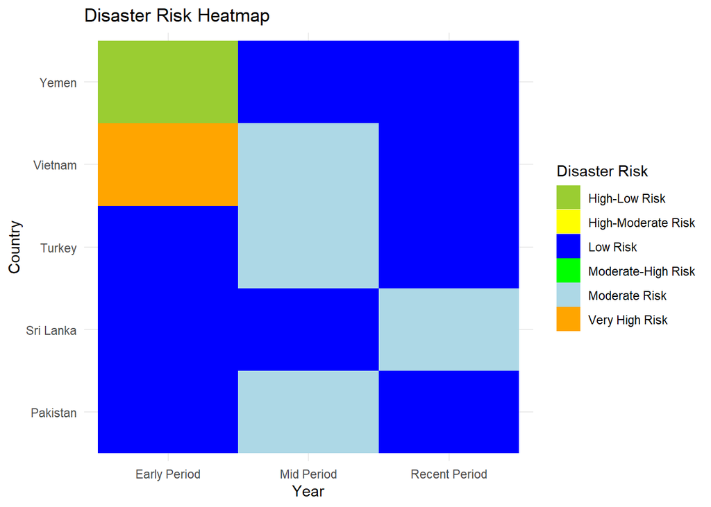

```r
combined_data_asia$Year <- as.factor(combined_data_asia$Temporal_Class)

heatmap_asia <- ggplot(combined_data_asia, aes(x = Year, y = Country, fill = Disaster_Risk)) +
  geom_tile() +
  scale_fill_manual(values = c(
    "Extremely High Risk" = "red",
    "Very High Risk" = "orange",
    "High-Moderate Risk" = "yellow",
    "High-Low Risk" = "yellowgreen",
    "Moderate-High Risk" = "green",
    "Moderate Risk" = "lightblue",
    "Low Risk" = "blue",
    "High Risk" = "purple",
    "Clustered Risk" = "skyblue",
    "Moderately High DataCards Risk" = "pink",
    "Moderately Less DataCards Risk" = "violet",
    "Least DataCards Risk" = "grey",
    "Undefined Risk" = "white"
  )) +
  labs(
    title = "Disaster Risk Heatmap",
    x = "Year",
    y = "Country",
    fill = "Disaster Risk"
  ) +
  theme_minimal()
print(heatmap_asia)
```

#Cluster 2

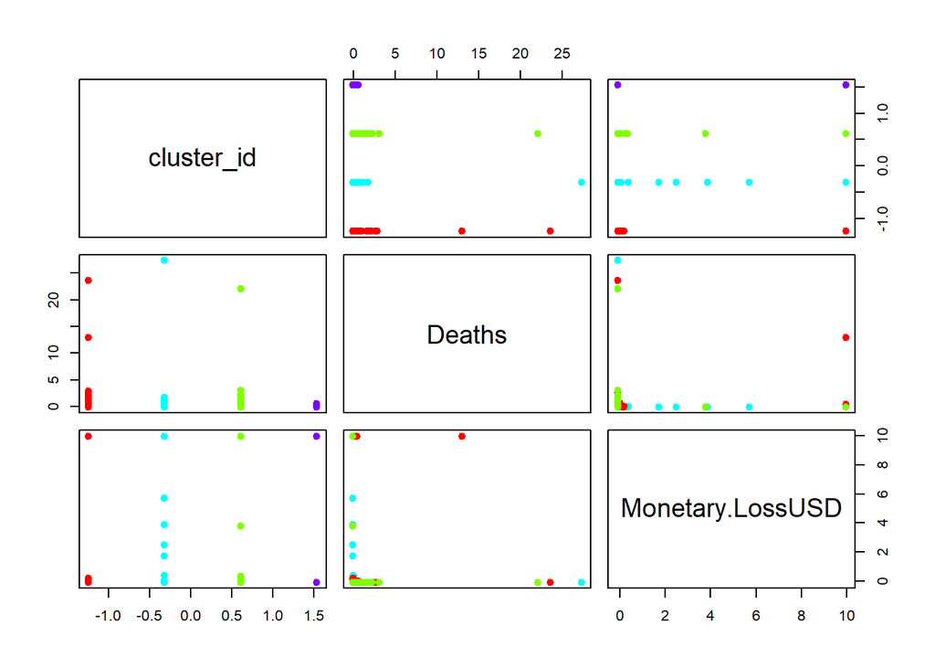

```r
turkey_c$Country <- "Turkey"
vietnam_c$Country <- "Vietnam"
yemen_c$Country <- "Yemen"
pakistan_c$Country <- "Pakistan"
srilanka_c$Country <- "Sri Lanka"

asias <- rbind(turkey_c, vietnam_c, yemen_c, pakistan_c, srilanka_c)
asias$cluster_id <- as.integer(as.character(asias$cluster_id))
data_for_clustering <-asias[, c("cluster_id", "Deaths", "Monetary.LossUSD")]

scaled_data <- scale(data_for_clustering)

set.seed(123)
clara_output <- clara(scaled_data, k = 4, samples = 500)
colors <- rainbow(length(unique(clara_output$clustering)))

scaled_data_with_clusters <- cbind(scaled_data, Cluster = clara_output$clustering)

pairs(scaled_data_with_clusters[, -ncol(scaled_data_with_clusters)],
      col = colors[clara_output$clustering], pch = 19)

legend("left", legend = unique(clara_output$clustering), fill = colors, title = "Clusters")
```

## AFRICA

Raw Data Reading

```r
tanzania<- read.csv("tanzania.csv",header=TRUE,na.strings=c(""))
colnames(tanzania) <- gsub("^\\s+|\\s+$", "", colnames(tanzania))
uganda <- read.csv("uganda.csv",header=TRUE,na.strings=c(""))
colnames(uganda) <- gsub("^\\s+|\\s+$", "", colnames(uganda))
zambia <- read.csv("zambia.csv",header=TRUE,na.strings=c(""))
colnames(zambia) <- gsub("^\\s+|\\s+$", "", colnames(zambia))
senegal <- read.csv("senegal.csv",header=TRUE,na.strings=c(""))
colnames(senegal) <- gsub("^\\s+|\\s+$", "", colnames(senegal))
tunisia <- read.csv("tunisia.csv",header=TRUE,na.strings=c(""))
colnames(tunisia) <- gsub("^\\s+|\\s+$", "", colnames(tunisia))
```

Data PreProcessing: Missing Values, Duplicate Values

```r
print("Total Missing Values: ")
```

```
## [1] "Total Missing Values: "
```

```r
print(paste("Tanzania: ",sum(is.na(tanzania))))
```

```
## [1] "Tanzania:  1"
```

```r
print(paste("Uganda: ",sum(is.na(uganda))))
```

```
## [1] "Uganda:  3"
```

```r
print(paste("Zambia: ",sum(is.na(zambia))))
```

```
## [1] "Zambia:  1"
```

```r
print(paste("senegal: ",sum(is.na(senegal))))
```

```
## [1] "senegal:  1"
```

```r
print(paste("tunisia: ",sum(is.na(tunisia))))
```

```
## [1] "tunisia:  1"
```

```r
tanzania <- na.omit(tanzania, cols = c('Event'))

uganda <- na.omit(uganda, cols = c('Event', 'Directly.affected', 'Losses..USD'))

zambia <- na.omit(zambia, cols = c('Event'))

senegal <- na.omit(senegal, cols = c('Event'))

tunisia <- na.omit(tunisia, cols = c('Event'))
```

```r
print("Total Missing Values: ")
```

```
## [1] "Total Missing Values: "
```

```r
print(paste("Tanzania: ",sum(is.na(tanzania))))
```

```
## [1] "Tanzania:  0"
```

```r
print(paste("Uganda: ",sum(is.na(uganda))))
```

```
## [1] "Uganda:  0"
```

```r
print(paste("Zambia: ",sum(is.na(zambia))))
```

```
## [1] "Zambia:  0"
```

```r
print(paste("senegal: ",sum(is.na(senegal))))
```

```
## [1] "senegal:  0"
```

```r
print(paste("tunisia: ",sum(is.na(tunisia))))
```

```
## [1] "tunisia:  0"
```

```r
print("Total Duplicate values")
```

```
## [1] "Total Duplicate values"
```

```r
print(paste("Tanzania: ", sum(duplicated(tanzania))))
```

```
## [1] "Tanzania:  0"
```

```r
print(paste("Uganda: ", sum(duplicated(uganda))))
```

```
## [1] "Uganda:  0"
```

```r
print(paste("Zambia: ", sum(duplicated(zambia))))
```

```
## [1] "Zambia:  0"
```

```r
print(paste("senegal: ", sum(duplicated(senegal))))
```

```
## [1] "senegal:  0"
```

```r
print(paste("tunisia: ", sum(duplicated(tunisia))))
```

```
## [1] "tunisia:  0"
```

```r
tanzania$Event <- toupper(tanzania$Event)
uganda$Event <- toupper(uganda$Event)
zambia$Event <- toupper(zambia$Event)
senegal$Event <- toupper(senegal$Event)
tunisia$Event <- toupper(tunisia$Event)
```

Data Tranformation

```r
uganda$Houses.Ruined <-uganda$Houses.Destroyed + uganda$Houses.Damaged
uganda$Affected <-uganda$Directly.affected + uganda$Indirectly.Affected

uganda$Monetary.LossUSD<-uganda$Losses..USD + uganda$Losses..Local * (0.00026)
uganda$Monetary.LossUSD <- as.integer(uganda$Monetary.LossUSD)

uganda = select(uganda, -5:-10)
head(uganda)
```

```
##   Year      Event DataCards Deaths Houses.Ruined Affected Monetary.LossUSD
## 1 1933      FLOOD         2     50             0        0                0
## 2 1933  LANDSLIDE         2     50             0        0                0
## 3 1945 EARTHQUAKE         1      5             0        0                0
## 4 1964  LANDSLIDE         2     36             0        0                0
## 5 1966 EARTHQUAKE         2    257          6752        0                0
## 6 1970  LANDSLIDE         2    120             0        0                0
```

```r
summary(uganda)
```

```
##      Year              Event             DataCards          Deaths
##  Length:367         Length:367         Min.   :  1.00   Min.   :   0.00
##  Class :character   Class :character   1st Qu.:  1.00   1st Qu.:   0.00
##  Mode  :character   Mode  :character   Median :  4.00   Median :   1.00
##                                        Mean   : 13.21   Mean   :  48.65
##                                        3rd Qu.: 10.00   3rd Qu.:  14.00
##                                        Max.   :305.00   Max.   :3353.00
##  Houses.Ruined        Affected       Monetary.LossUSD
##  Min.   :    0.0   Min.   :      0   Min.   :0
##  1st Qu.:    0.0   1st Qu.:      0   1st Qu.:0
##  Median :    0.0   Median :      0   Median :0
##  Mean   :  284.2   Mean   :  30864   Mean   :0
##  3rd Qu.:   19.0   3rd Qu.:   2499   3rd Qu.:0
##  Max.   :18469.0   Max.   :3022627   Max.   :0
```

```r
tanzania$Houses.Ruined <-tanzania$Houses.Destroyed + tanzania$Houses.Damaged
tanzania$Affected <-tanzania$Directly.affected + tanzania$Indirectly.Affected

tanzania$Monetary.LossUSD<-tanzania$Losses..USD + tanzania$Losses..Local * (0.00040)
tanzania$Monetary.LossUSD <- as.integer(tanzania$Monetary.LossUSD)

tanzania = select(tanzania, -5:-10)
head(tanzania)
```

```
##   Year   Event DataCards Deaths Houses.Ruined Affected Monetary.LossUSD
## 1 1872 CYCLONE         1      0             0        0                0
## 2 1913 DROUGHT         1      0             0        0                0
## 3 1919 DROUGHT         1      0             0        0                0
## 4 1929 DROUGHT         1      0             0        0                0
## 5 1931 DROUGHT         2      0             0    48000                0
## 6 1934   FLOOD         1      0             0        0                0
```

```r
summary(tanzania)
```

```
##      Year              Event             DataCards          Deaths
##  Length:296         Length:296         Min.   : 1.000   Min.   :  0.00
##  Class :character   Class :character   1st Qu.: 1.000   1st Qu.:  0.00
##  Mode  :character   Mode  :character   Median : 1.000   Median :  0.00
##                                        Mean   : 4.264   Mean   : 18.02
##                                        3rd Qu.: 3.000   3rd Qu.:  3.00
##                                        Max.   :86.000   Max.   :833.00
##  Houses.Ruined        Affected         Monetary.LossUSD
##  Min.   :    0.0   Min.   :      0.0   Min.   :       0
##  1st Qu.:    0.0   1st Qu.:      0.0   1st Qu.:       0
##  Median :    0.0   Median :    194.5   Median :       0
##  Mean   :  652.5   Mean   :  23156.4   Mean   :  421047
##  3rd Qu.:   43.0   3rd Qu.:   4047.2   3rd Qu.:   11004
##  Max.   :39163.0   Max.   :1014067.0   Max.   :19307577
```

```r
zambia$Houses.Ruined <-zambia$Houses.Destroyed + zambia$Houses.Damaged
zambia$Affected <-zambia$Directly.affected + zambia$Indirectly.Affected

zambia$Monetary.LossUSD<-zambia$Losses..USD + zambia$Losses..Local * (0.043)
zambia$Monetary.LossUSD <- as.integer(zambia$Monetary.LossUSD)

zambia = select(zambia, -5:-10)
head(zambia)
```

```
##   Year Event DataCards Deaths Houses.Ruined Affected Monetary.LossUSD
## 1 1999 STORM         2      0             0        0              452
## 2 2000  FIRE         1      0             0    14000                0
## 3 2000 FLOOD         2      0             0       10                0
## 4 2001 FLOOD         5      0          1142     4534                0
## 5 2004 FLOOD         5      0             0    36738                0
## 6 2005  FIRE         1      0            15       54                0
```

```r
summary(zambia)
```

```
##      Year              Event             DataCards           Deaths
##  Length:77          Length:77          Min.   :   1.00   Min.   :0.0000
##  Class :character   Class :character   1st Qu.:   2.00   1st Qu.:0.0000
##  Mode  :character   Mode  :character   Median :   4.00   Median :0.0000
##                                        Mean   :  28.17   Mean   :0.5325
##                                        3rd Qu.:   9.00   3rd Qu.:0.0000
##                                        Max.   :1078.00   Max.   :9.0000
##  Houses.Ruined       Affected      Monetary.LossUSD
##  Min.   :   0.0   Min.   :     0   Min.   :      0
##  1st Qu.:   0.0   1st Qu.:     0   1st Qu.:      0
##  Median :   1.0   Median :    22   Median :      0
##  Mean   : 113.3   Mean   : 12395   Mean   : 126391
##  3rd Qu.:  70.0   3rd Qu.:   877   3rd Qu.:      0
##  Max.   :2037.0   Max.   :578784   Max.   :9308159
```

```r
senegal$Houses.Ruined <-senegal$Houses.Destroyed + senegal$Houses.Damaged
senegal$Affected <-senegal$Directly.affected + senegal$Indirectly.Affected

senegal$Monetary.LossUSD<-senegal$Losses..USD + senegal$Losses..Local * (0.00166)
senegal$Monetary.LossUSD <- as.integer(senegal$Monetary.LossUSD)

senegal = select(senegal, -5:-10)
head(senegal)
```

```
##   Year           Event DataCards Deaths Houses.Ruined Affected Monetary.LossUSD
## 1 1980 COASTAL EROSION         3      0             0        0                0
## 2 1981 COASTAL EROSION         3      0             0        0                0
## 3 1982 COASTAL EROSION         3      0             0        0                0
## 4 1982         DROUGHT         5      0             0        0                0
## 5 1983 COASTAL EROSION         3      0             0        0                0
## 6 1984 COASTAL EROSION         3      0             0        0                0
```

```r
summary(senegal)
```

```
##      Year              Event             DataCards           Deaths
##  Length:170         Length:170         Min.   :   1.00   Min.   :   0.00
##  Class :character   Class :character   1st Qu.:   2.00   1st Qu.:   0.00
##  Mode  :character   Mode  :character   Median :   4.00   Median :   1.00
##                                        Mean   :  44.08   Mean   :  25.31
##                                        3rd Qu.:  16.75   3rd Qu.:   8.00
##                                        Max.   :1234.00   Max.   :1868.00
##  Houses.Ruined        Affected      Monetary.LossUSD
##  Min.   :    0.0   Min.   :     0   Min.   :       0
##  1st Qu.:    0.0   1st Qu.:     0   1st Qu.:       0
##  Median :    0.0   Median :     0   Median :       0
##  Mean   :  415.4   Mean   :  3309   Mean   :  159473
##  3rd Qu.:    1.0   3rd Qu.:     0   3rd Qu.:       0
##  Max.   :28053.0   Max.   :300000   Max.   :20921713
```

```r
tunisia$Houses.Ruined <-tunisia$Houses.Destroyed + tunisia$Houses.Damaged
tunisia$Affected <-tunisia$Directly.affected + tunisia$Indirectly.Affected
tunisia$Monetary.LossUSD<-tunisia$Losses..USD + tunisia$Losses..Local * (0.32)
tunisia$Monetary.LossUSD <- as.integer(tunisia$Monetary.LossUSD)
tunisia = select(tunisia, -5:-10)
head(tunisia)
```

```
##   Year       Event DataCards Deaths Houses.Ruined Affected Monetary.LossUSD
## 1 1982       FLOOD        40    124          7725        0          7369423
## 2 1982   HAILSTORM         6      0             0        0                0
## 3 1982 STRONG WIND         4      0             0        0                0
## 4 1983     DROUGHT        15      0             0        0           164296
## 5 1983   LANDSLIDE         1      2             0        0                0
## 6 1984    EPIDEMIC         1      0             0       61                0
```

```r
summary(tunisia)
```

```
##      Year              Event             DataCards          Deaths
##  Length:207         Length:207         Min.   :  1.00   Min.   :  0.000
##  Class :character   Class :character   1st Qu.:  1.00   1st Qu.:  0.000
##  Mode  :character   Mode  :character   Median :  2.00   Median :  0.000
##                                        Mean   : 10.47   Mean   :  2.614
##                                        3rd Qu.:  6.00   3rd Qu.:  0.000
##                                        Max.   :165.00   Max.   :124.000
##  Houses.Ruined        Affected       Monetary.LossUSD
##  Min.   :    0.0   Min.   :    0.0   Min.   :       0
##  1st Qu.:    0.0   1st Qu.:    0.0   1st Qu.:       0
##  Median :    0.0   Median :    0.0   Median :       0
##  Mean   :  205.6   Mean   :  688.4   Mean   : 1933172
##  3rd Qu.:    0.0   3rd Qu.:    8.0   3rd Qu.:   64000
##  Max.   :27306.0   Max.   :60000.0   Max.   :53402131
```

Feature addition 1

```r
add_Event_Severity <- function(data) {
  data$Event_Severity <- data$Deaths / data$DataCards

  a_countries <- c("uganda", "tanzania", "senegal")
  b_countries <- c("tunisia", "zambia")

  for (country in a_countries) {
    data$Event_Severity[data$Country == country & data$Event_Severity > 1] <- 1
    data$Event_Severity[data$Country == country & data$Event_Severity < 0.5] <- 0.5
  }


  for (country in b_countries) {
    data$Event_Severity[data$Country == country & data$Event_Severity > 2] <- 2
    data$Event_Severity[data$Country == country & data$Event_Severity < 1] <- 1
  }
  data$Event_Severity <- round(data$Event_Severity * 100)
  return(data$Event_Severity)
}

uganda$Event_Severity <- add_Event_Severity(uganda)
tanzania$Event_Severity <- add_Event_Severity(tanzania)
senegal$Event_Severity <- add_Event_Severity(senegal)
tunisia$Event_Severity<- add_Event_Severity(tunisia)
zambia$Event_Severity <- add_Event_Severity(zambia)
```

Feature 2

```r
tanzania$Event_factor<-as.integer(as.factor(tanzania$Event))
senegal$Event_factor<-as.integer(as.factor(senegal$Event))
uganda$Event_factor<-as.integer(as.factor(uganda$Event))
tunisia$Event_factor<-as.integer(as.factor(tunisia$Event))
zambia$Event_factor<-as.integer(as.factor(zambia$Event))
head(tanzania)
```

```
##   Year   Event DataCards Deaths Houses.Ruined Affected Monetary.LossUSD
## 1 1872 CYCLONE         1      0             0        0                0
## 2 1913 DROUGHT         1      0             0        0                0
## 3 1919 DROUGHT         1      0             0        0                0
## 4 1929 DROUGHT         1      0             0        0                0
## 5 1931 DROUGHT         2      0             0    48000                0
## 6 1934   FLOOD         1      0             0        0                0
##   Event_Severity Event_factor
## 1              0            6
## 2              0            7
## 3              0            7
## 4              0            7
## 5              0            7
## 6              0           12
```

writeCsv

```r
write.csv(tanzania, file = "tanzania_cleaned.csv", row.names = FALSE)
write.csv(uganda, file = "uganda_cleaned.csv", row.names = FALSE)
write.csv(zambia, file = "zambia_cleaned.csv", row.names=FALSE)
write.csv(tunisia, file = "tunisia_cleaned.csv", row.names = FALSE)
write.csv(senegal, file = "senegal_cleaned.csv", row.names = FALSE)
```

Read Csv

```r
tanzania_c <- read.csv("tanzania_cleaned.csv",header=TRUE)
uganda_c <- read.csv("uganda_cleaned.csv",header=TRUE)
zambia_c <- read.csv("zambia_cleaned.csv",header=TRUE)
tunisia_c <- read.csv("tunisia_cleaned.csv",header=TRUE)
senegal_c <- read.csv("senegal_cleaned.csv",header=TRUE)
```

Combining into one continent

```r
africa <- rbind(tanzania_c,tunisia_c, senegal_c, zambia_c, uganda_c)
```

Preprocessing Visualization (Africa)

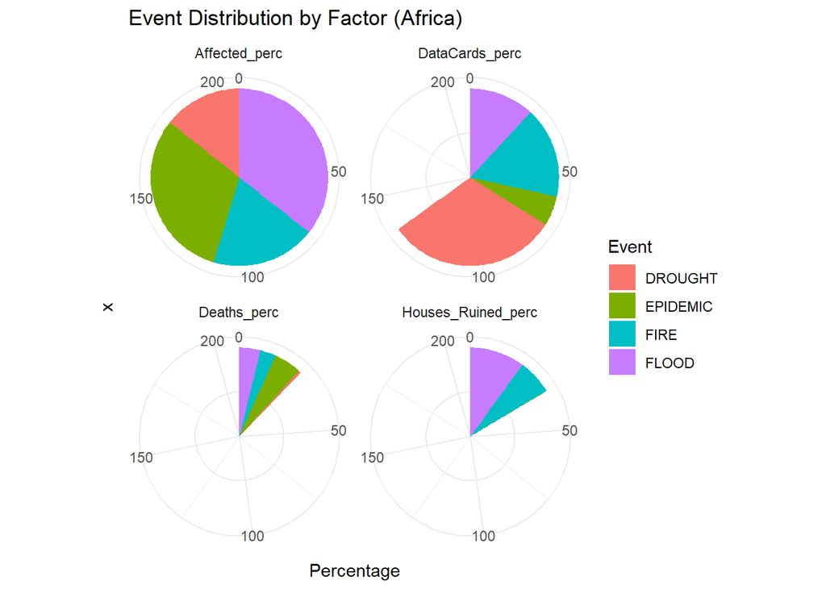

```r
africa_perc <- africa %>%
  mutate(
    Total = DataCards + Deaths + `Houses.Ruined` + Affected,
    DataCards_perc = DataCards / Total,
    Deaths_perc = Deaths / Total,
    Houses_Ruined_perc = `Houses.Ruined` / Total,
    Affected_perc = Affected / Total
  ) %>%
  select(Event, DataCards_perc, Deaths_perc, Houses_Ruined_perc, Affected_perc)

africa_long <- africa_perc %>%
  pivot_longer(cols = -Event, names_to = "Factor", values_to = "Percentage")

threshold <- 50

filtered_africa_long <- africa_long %>%
  group_by(Event) %>%
  summarise(Total_Percentage = sum(Percentage)) %>%
  filter(Total_Percentage > threshold) %>%
  inner_join(africa_long  , by = "Event") %>%
  ungroup()

ggplot(filtered_africa_long, aes(x = "", y = Percentage, fill = Event)) +
  geom_bar(stat = "identity", width = 1) +
  facet_wrap(~Factor) +
  coord_polar(theta = "y") +
  theme_minimal() +
  ggtitle("Event Distribution by Factor (Africa)")
```

Preprocessing visualization(individual)

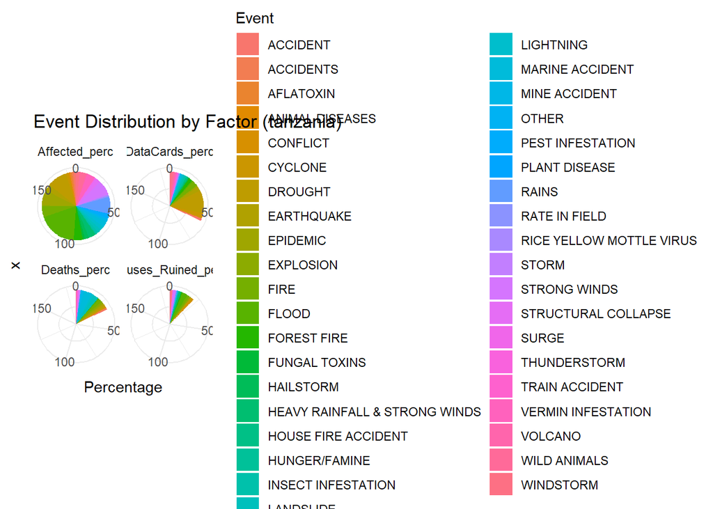

```r
tanzania_c<- tanzania_c %>%
  mutate(Total = DataCards + Deaths + Houses.Ruined + Affected)

 tanzania_c_perc <- tanzania_c %>%
  mutate(
    DataCards_perc = DataCards / Total,
    Deaths_perc = Deaths / Total,
    Houses_Ruined_perc = Houses.Ruined / Total,
    Affected_perc = Affected / Total
  ) %>%
  select(Event, DataCards_perc, Deaths_perc, Houses_Ruined_perc, Affected_perc)

 tanzania_c_long <-  tanzania_c_perc %>%
  pivot_longer(cols = -Event, names_to = "Factor", values_to = "Percentage")

ggplot( tanzania_c_long, aes(x = "", y = Percentage, fill = Event)) +
  geom_bar(stat = "identity", width = 1) +
  facet_wrap(~Factor) +
  coord_polar(theta = "y") +
  theme_minimal() +
  ggtitle("Event Distribution by Factor (tanzania)")
```

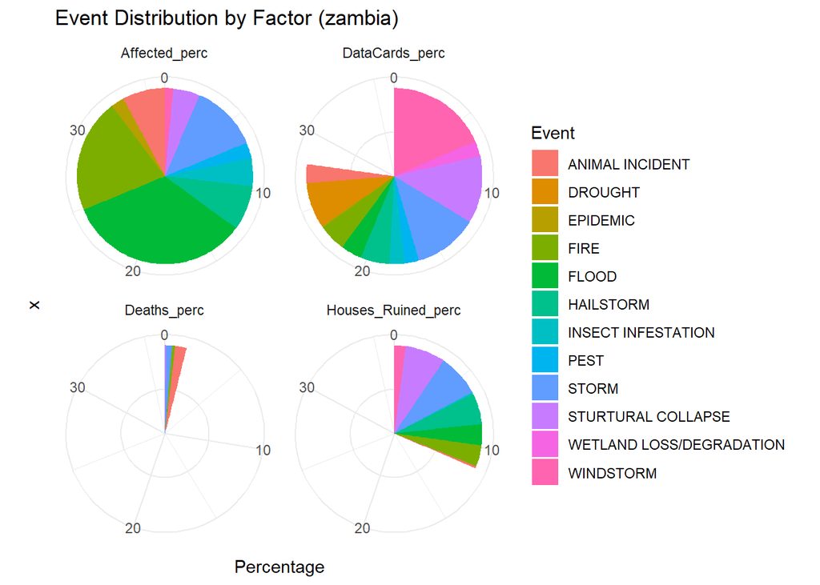

```r
zambia_c<- zambia_c %>%
  mutate(Total = DataCards + Deaths + Houses.Ruined + Affected)

 zambia_c_perc <- zambia_c %>%
  mutate(
    DataCards_perc = DataCards / Total,
    Deaths_perc = Deaths / Total,
    Houses_Ruined_perc = Houses.Ruined / Total,
    Affected_perc = Affected / Total
  ) %>%
  select(Event, DataCards_perc, Deaths_perc, Houses_Ruined_perc, Affected_perc)

  zambia_c_long <-  zambia_c_perc %>%
  pivot_longer(cols = -Event, names_to = "Factor", values_to = "Percentage")

ggplot( zambia_c_long, aes(x = "", y = Percentage, fill = Event)) +
  geom_bar(stat = "identity", width = 1) +
  facet_wrap(~Factor) +
  coord_polar(theta = "y") +
  theme_minimal() +
  ggtitle("Event Distribution by Factor (zambia)")
```

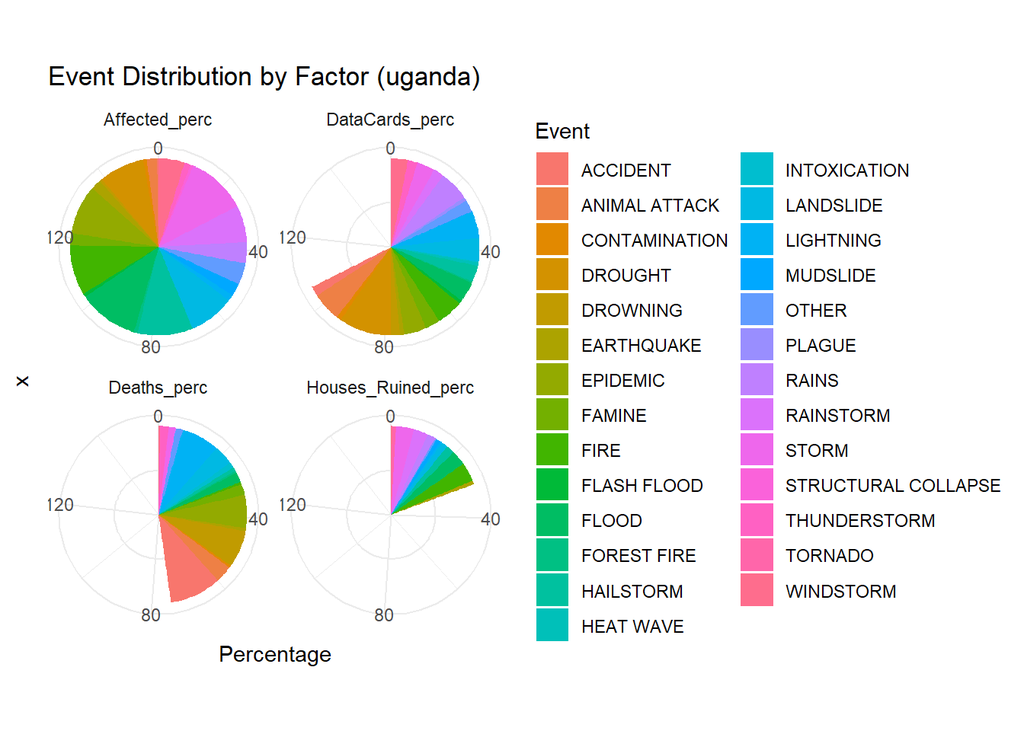

```r
uganda_c<- uganda_c %>%
  mutate(Total = DataCards + Deaths + Houses.Ruined + Affected)

 uganda_c_perc <- uganda_c %>%
  mutate(
    DataCards_perc = DataCards / Total,
    Deaths_perc = Deaths / Total,
    Houses_Ruined_perc = Houses.Ruined / Total,
    Affected_perc = Affected / Total
  ) %>%
  select(Event, DataCards_perc, Deaths_perc, Houses_Ruined_perc, Affected_perc)

 uganda_c_long <-  uganda_c_perc %>%
  pivot_longer(cols = -Event, names_to = "Factor", values_to = "Percentage")
ggplot( uganda_c_long, aes(x = "", y = Percentage, fill = Event)) +
  geom_bar(stat = "identity", width = 1) +
  facet_wrap(~Factor) +
  coord_polar(theta = "y") +
  theme_minimal() +
  ggtitle("Event Distribution by Factor (uganda)")
```

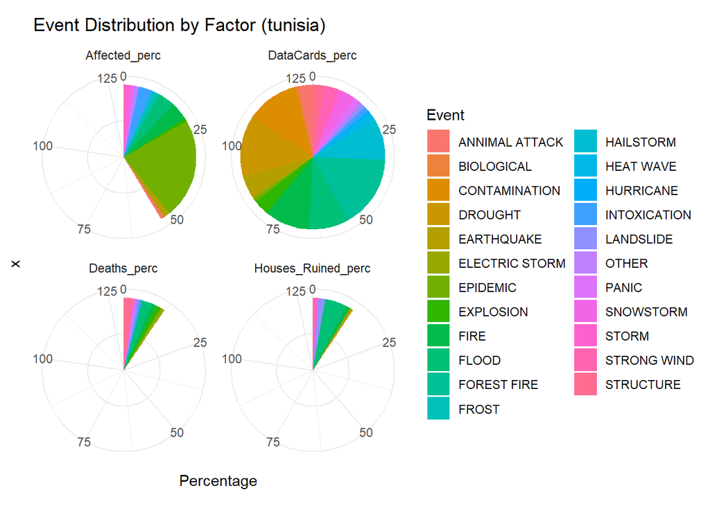

```r
tunisia_c<- tunisia_c %>%
  mutate(Total = DataCards + Deaths + Houses.Ruined + Affected)

 tunisia_c_perc <- tunisia_c %>%
  mutate(
    DataCards_perc = DataCards / Total,
    Deaths_perc = Deaths / Total,
    Houses_Ruined_perc = Houses.Ruined / Total,
    Affected_perc = Affected / Total
  ) %>%
  select(Event, DataCards_perc, Deaths_perc, Houses_Ruined_perc, Affected_perc)

 tunisia_c_long <-  tunisia_c_perc %>%
  pivot_longer(cols = -Event, names_to = "Factor", values_to = "Percentage")

ggplot( tunisia_c_long, aes(x = "", y = Percentage, fill = Event)) +
  geom_bar(stat = "identity", width = 1) +
  facet_wrap(~Factor) +
  coord_polar(theta = "y") +
  theme_minimal() +
  ggtitle("Event Distribution by Factor (tunisia)")
```

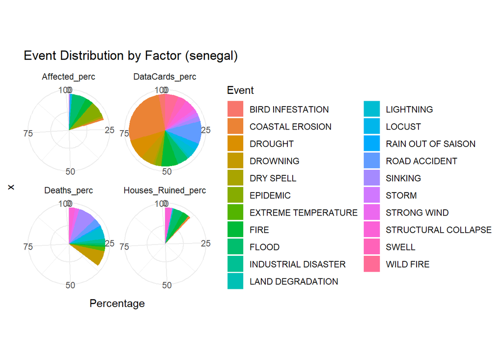

```r
senegal_c<- senegal_c %>%
  mutate(Total = DataCards + Deaths + Houses.Ruined + Affected)

senegal_c_perc <- senegal_c %>%
  mutate(
    DataCards_perc = DataCards / Total,
    Deaths_perc = Deaths / Total,
    Houses_Ruined_perc = Houses.Ruined / Total,
    Affected_perc = Affected / Total
  ) %>%
  select(Event, DataCards_perc, Deaths_perc, Houses_Ruined_perc, Affected_perc)

 senegal_c_long <-  senegal_c_perc %>%
  pivot_longer(cols = -Event, names_to = "Factor", values_to = "Percentage")

ggplot( senegal_c_long, aes(x = "", y = Percentage, fill = Event)) +
  geom_bar(stat = "identity", width = 1) +
  facet_wrap(~Factor) +
  coord_polar(theta = "y") +
  theme_minimal() +
  ggtitle("Event Distribution by Factor (senegal)")
```

Split parameter and model (Africa)

```r
numeric_data <- africa[, sapply(africa, is.numeric)]

scaled_data <- scale(numeric_data)
pca_result <- prcomp(scaled_data, center = TRUE, scale. = TRUE)
summary(pca_result)
```

```
## Importance of components:
##                           PC1    PC2    PC3    PC4    PC5     PC6     PC7
## Standard deviation     1.2256 1.1757 1.0978 1.0098 0.9593 0.88824 0.83205
## Proportion of Variance 0.1878 0.1728 0.1507 0.1275 0.1150 0.09862 0.08654
## Cumulative Proportion  0.1878 0.3605 0.5112 0.6387 0.7537 0.85230 0.93884
##                            PC8
## Standard deviation     0.69948
## Proportion of Variance 0.06116
## Cumulative Proportion  1.00000
```

```r
formula <- numeric_data$Deaths ~ numeric_data$DataCards + numeric_data$Deaths + numeric_data$Monetary.LossUSD + numeric_data$Event_Severity + numeric_data$Houses.Ruined + numeric_data$Affected
  model <- lm(formula, data = numeric_data)

  vif_result <- car::vif(model)

  cat("\n","VIF results for Deaths", ":\n")
```

```
##
##  VIF results for Deaths :
```

```r
  print(vif_result)
```

```
##                                   GVIF Df GVIF^(1/(2*Df))
## numeric_data$DataCards        1.032556  1        1.016148
## numeric_data$Deaths           1.111004  0             Inf
## numeric_data$Monetary.LossUSD 1.036857  1        1.018262
## numeric_data$Event_Severity   1.000745  1        1.000372
## numeric_data$Houses.Ruined    1.078646  1        1.038579
## numeric_data$Affected         1.070677  1        1.034735
```

```r
  cat("\n")
```

```r
cor_matrix <- cor(numeric_data)
print("Correlation matrix ")
```

```
## [1] "Correlation matrix "
```

```r
print(cor_matrix)
```

```
##                          Year    DataCards       Deaths Houses.Ruined
## Year              1.000000000  0.093616761 -0.016684360   0.073845590
## DataCards         0.093616761  1.000000000  0.057162602   0.066573397
## Deaths           -0.016684360  0.057162602  1.000000000   0.023525484
## Houses.Ruined     0.073845590  0.066573397  0.023525484   1.000000000
## Affected         -0.003619207  0.123377249  0.030776202   0.229393292
## Monetary.LossUSD  0.017352757  0.125318084 -0.007026664   0.142280254
## Event_Severity   -0.057695939 -0.021589348  0.491039189  -0.005729485
## Event_factor      0.197268360 -0.007714172 -0.058027891  -0.015341830
##                      Affected Monetary.LossUSD Event_Severity Event_factor
## Year             -0.003619207      0.017352757   -0.057695939  0.197268360
## DataCards         0.123377249      0.125318084   -0.021589348 -0.007714172
## Deaths            0.030776202     -0.007026664    0.491039189 -0.058027891
## Houses.Ruined     0.229393292      0.142280254   -0.005729485 -0.015341830
## Affected          1.000000000      0.006110648   -0.011347033 -0.028231662
## Monetary.LossUSD  0.006110648      1.000000000   -0.016699609 -0.076164801
## Event_Severity   -0.011347033     -0.016699609    1.000000000  0.033076733
## Event_factor     -0.028231662     -0.076164801    0.033076733  1.000000000
```

```r
set.seed(123)
split_indices <- createDataPartition(africa$Year, p = 0.7, list = FALSE)

training_data_africa <- numeric_data[split_indices, ]
testing_data_africa <- numeric_data[-split_indices, ]
```

Model 1 enet on death ~ !Event, deaths - 25 % accuracy

```r
train_data <- training_data_africa
test_data <-  testing_data_africa

X_train <- as.matrix(subset(train_data, select =- c(Deaths)))
y_train <- train_data$Deaths
X_test <- as.matrix(subset(test_data, select = - c(Deaths)))
y_test <- test_data$Deaths

X_train_std <- scale(X_train)
X_test_std <- scale(X_test)

enet_model_combined<- cv.glmnet(X_train_std, y_train, alpha = 0.5)

best_lambda <- enet_model_combined$lambda.min

y_pred <- predict(enet_model_combined, newx = X_test_std, s = best_lambda)

mse <- mean((y_pred - y_test)^2)
rsquared <- cor(y_pred, y_test)^2

cat("Best Lambda:", best_lambda, "\n")
```

```
## Best Lambda: 14.65063
```

```r
cat("Mean Squared Error:", mse, "\n")
```

```
## Mean Squared Error: 49787.43
```

```r
cat("R-squared:", rsquared, "\n")
```

```
## R-squared: 0.2503724
```

Model 2 random forest on death ~ !Event, deaths - 73% accuracy

```r
rf_model_complex <- randomForest(
  X_train, y_train,
  ntree = 1000,
  mtry = sqrt(ncol(X_train)),
  max_depth = NULL
)

y_pred_rf_complex <- predict(rf_model_complex, X_test, type = "response")
mse_rf_complex <- mean((y_pred_rf_complex - y_test)^2)
rsquared_rf_complex <- cor(y_pred_rf_complex, y_test)^2

cat("Random Forest- Mean Squared Error:", mse_rf_complex, "\n")
```

```
## Random Forest- Mean Squared Error: 30439.19
```

```r
cat("Random Forest - R-squared:", rsquared_rf_complex, "\n")
```

```
## Random Forest - R-squared: 0.7349118
```

Split(individual)

```r
set.seed(123)
split_indices <- createDataPartition(tanzania_c$Year, p = 0.7, list = FALSE)
training_data_tanzania <- tanzania_c[split_indices, ]
testing_data_tanzania <- tanzania_c[-split_indices, ]
```

```r
set.seed(123)
split_indices <- createDataPartition(zambia_c$Year, p = 0.7, list = FALSE)
training_data_zambia <- zambia_c[split_indices, ]
testing_data_zambia <- zambia_c[-split_indices, ]
```

```r
set.seed(123)
split_indices <- createDataPartition(uganda_c$Year, p = 0.7, list = FALSE)
training_data_uganda <- uganda_c[split_indices, ]
testing_data_uganda <- uganda_c[-split_indices, ]
```

```r
set.seed(123)
split_indices <- createDataPartition(senegal_c$Year, p = 0.7, list = FALSE)
training_data_senegal <- senegal_c[split_indices, ]
testing_data_senegal <- senegal_c[-split_indices, ]
```

```r
# Imbalanced Distribution: There's considerable variation in the number of observations across different years. Some years have only a few observations while others have many more. View distubution by table(tunisia$Year)

unique_years <- unique(tunisia_c$Year)
train_indices <- test_indices <- c()

for (year in unique_years) {
  year_indices <- which(tunisia_c$Year == year)

  num_samples_train <- round(length(year_indices) * 0.7)

  train_indices <- c(train_indices, sample(year_indices, num_samples_train))
  test_indices <- c(test_indices, setdiff(year_indices, train_indices))
}
training_data_tunisia <- tunisia_c[train_indices, ]
testing_data_tunisia <- tunisia_c[test_indices,]
```

PCA , CORRELATION MATRIX AND VIF

```r
tanzania_no_event <- tanzania_c[, !names(tanzania_c) %in% c("Event")]
scaled_data <- scale(tanzania_no_event)
pca_result <- prcomp(scaled_data, center = TRUE, scale. = TRUE)
summary(pca_result)
```

```
## Importance of components:
##                           PC1    PC2    PC3    PC4     PC5     PC6     PC7
## Standard deviation     1.6463 1.3838 1.2960 1.1116 0.80194 0.68239 0.50709
## Proportion of Variance 0.3011 0.2128 0.1866 0.1373 0.07146 0.05174 0.02857
## Cumulative Proportion  0.3011 0.5139 0.7005 0.8378 0.90928 0.96102 0.98959
##                            PC8       PC9
## Standard deviation     0.30605 1.633e-16
## Proportion of Variance 0.01041 0.000e+00
## Cumulative Proportion  1.00000 1.000e+00
```

```r
formula <- tanzania_c$Deaths ~ tanzania_c$DataCards + tanzania_c$Deaths + tanzania_c$Monetary.LossUSD + tanzania_c$Event_Severity + tanzania_c$Houses.Ruined + tanzania_c$Affected
  model <- lm(formula, data = tanzania_c)

  vif_result <- car::vif(model)

  cat("\n","VIF results for Deaths", ":\n")
```

```
##
##  VIF results for Deaths :
```

```r
  print(vif_result)
```

```
##                                 GVIF Df GVIF^(1/(2*Df))
## tanzania_c$DataCards        2.587754  1        1.608650
## tanzania_c$Deaths           2.747427  0             Inf
## tanzania_c$Monetary.LossUSD 1.904262  1        1.379950
## tanzania_c$Event_Severity   1.003746  1        1.001871
## tanzania_c$Houses.Ruined    1.984675  1        1.408785
## tanzania_c$Affected         1.079176  1        1.038834
```

```r
  cat("\n")
```

```r
cor_matrix <- cor(tanzania_c[c("DataCards", "Deaths", "Monetary.LossUSD", "Event_Severity", "Houses.Ruined", "Affected")])
print("Correlation matrix ")
```

```
## [1] "Correlation matrix "
```

```r
print(cor_matrix)
```

```
##                    DataCards       Deaths Monetary.LossUSD Event_Severity
## DataCards         1.00000000  0.143389042       0.68070343    -0.05082766
## Deaths            0.14338904  1.000000000       0.09336899     0.88486578
## Monetary.LossUSD  0.68070343  0.093368986       1.00000000    -0.03102776
## Event_Severity   -0.05082766  0.884865781      -0.03102776     1.00000000
## Houses.Ruined     0.68563101  0.125651529       0.52748497    -0.02278572
## Affected          0.15916483 -0.004166967       0.18989364    -0.03286321
##                  Houses.Ruined     Affected
## DataCards           0.68563101  0.159164833
## Deaths              0.12565153 -0.004166967
## Monetary.LossUSD    0.52748497  0.189893640
## Event_Severity     -0.02278572 -0.032863211
## Houses.Ruined       1.00000000  0.253346791
## Affected            0.25334679  1.000000000
```

```r
zambia_no_event <- zambia_c[, !names(zambia_c) %in% c("Event")]
scaled_data <- scale(zambia_no_event)
pca_result <- prcomp(scaled_data, center = TRUE, scale. = TRUE)
summary(pca_result)
```

```
## Importance of components:
##                           PC1    PC2    PC3    PC4     PC5     PC6     PC7
## Standard deviation     1.5253 1.2924 1.0997 1.0160 0.94352 0.90990 0.83252
## Proportion of Variance 0.2585 0.1856 0.1344 0.1147 0.09892 0.09199 0.07701
## Cumulative Proportion  0.2585 0.4441 0.5785 0.6932 0.79210 0.88409 0.96110
##                           PC8       PC9
## Standard deviation     0.5917 7.308e-17
## Proportion of Variance 0.0389 0.000e+00
## Cumulative Proportion  1.0000 1.000e+00
```

```r
formula <- zambia_c$Deaths ~ zambia_c$DataCards + zambia_c$Deaths + zambia_c$Monetary.LossUSD + zambia_c$Event_Severity + zambia_c$Houses.Ruined + zambia_c$Affected
  model <- lm(formula, data = zambia_c)

  vif_result <- car::vif(model)

  cat("\n","VIF results for Deaths", ":\n")
```

```
##
##  VIF results for Deaths :
```

```r
  print(vif_result)
```

```
##                               GVIF Df GVIF^(1/(2*Df))
## zambia_c$DataCards        1.196972  1        1.094062
## zambia_c$Deaths           1.202947  0             Inf
## zambia_c$Monetary.LossUSD 1.003454  1        1.001725
## zambia_c$Event_Severity   1.003096  1        1.001547
## zambia_c$Houses.Ruined    1.004154  1        1.002075
## zambia_c$Affected         1.197580  1        1.094340
```

```r
  cat("\n")
```

```r
cor_matrix <- cor(zambia_c[c("DataCards", "Deaths", "Monetary.LossUSD", "Event_Severity", "Houses.Ruined", "Affected")])
print("Correlation matrix ")
```

```
## [1] "Correlation matrix "
```

```r
print(cor_matrix)
```

```
##                     DataCards      Deaths Monetary.LossUSD Event_Severity
## DataCards         1.000000000 -0.01560446      0.002792676    -0.04406373
## Deaths           -0.015604461  1.00000000      0.270955645     0.53225927
## Monetary.LossUSD  0.002792676  0.27095564      1.000000000     0.01073346
## Event_Severity   -0.044063730  0.53225927      0.010733458     1.00000000
## Houses.Ruined    -0.020650021  0.18404768      0.053166623    -0.01773523
## Affected          0.404455547 -0.03439533     -0.019873633    -0.04108241
##                  Houses.Ruined    Affected
## DataCards          -0.02065002  0.40445555
## Deaths              0.18404768 -0.03439533
## Monetary.LossUSD    0.05316662 -0.01987363
## Event_Severity     -0.01773523 -0.04108241
## Houses.Ruined       1.00000000 -0.02961516
## Affected           -0.02961516  1.00000000
```

```r
uganda_no_event <- uganda_c[, !names(uganda_c) %in% c("Event","Monetary.LossUSD")]
scaled_data <- scale(uganda_no_event)
pca_result <- prcomp(scaled_data, center = TRUE, scale. = TRUE)
summary(pca_result)
```

```
## Importance of components:
##                           PC1    PC2    PC3    PC4     PC5    PC6     PC7
## Standard deviation     1.6301 1.3075 1.0491 0.9284 0.85762 0.7457 0.61572
## Proportion of Variance 0.3322 0.2137 0.1376 0.1077 0.09194 0.0695 0.04739
## Cumulative Proportion  0.3322 0.5459 0.6834 0.7912 0.88311 0.9526 1.00000
##                              PC8
## Standard deviation     2.817e-16
## Proportion of Variance 0.000e+00
## Cumulative Proportion  1.000e+00
```

```r
formula <- uganda_c$Deaths ~ uganda_c$DataCards + uganda_c$Deaths  + uganda_c$Event_Severity + uganda_c$Houses.Ruined + uganda_c$Affected
  model <- lm(formula, data = uganda_c)

  vif_result <- car::vif(model)

  cat("\n","VIF results for Deaths", ":\n")
```

```
##
##  VIF results for Deaths :
```

```r
  print(vif_result)
```

```
##                             GVIF Df GVIF^(1/(2*Df))
## uganda_c$DataCards      1.380586  1        1.174983
## uganda_c$Deaths         1.505123  0             Inf
## uganda_c$Event_Severity 1.004770  1        1.002382
## uganda_c$Houses.Ruined  1.361329  1        1.166760
## uganda_c$Affected       1.340864  1        1.157957
```

```r
  cat("\n")
```

```r
cor_matrix <- cor(uganda_c[c("DataCards", "Deaths", "Monetary.LossUSD", "Event_Severity", "Houses.Ruined", "Affected")])
print("Correlation matrix ")
```

```
## [1] "Correlation matrix "
```

```r
print(cor_matrix)
```

```
##                    DataCards     Deaths Monetary.LossUSD Event_Severity
## DataCards         1.00000000 0.18289858               NA    -0.02148951
## Deaths            0.18289858 1.00000000               NA     0.52877517
## Monetary.LossUSD          NA         NA                1             NA
## Event_Severity   -0.02148951 0.52877517               NA     1.00000000
## Houses.Ruined     0.44733528 0.00674568               NA     0.04023013
## Affected          0.43609356 0.02814144               NA    -0.02504558
##                  Houses.Ruined    Affected
## DataCards           0.44733528  0.43609356
## Deaths              0.00674568  0.02814144
## Monetary.LossUSD            NA          NA
## Event_Severity      0.04023013 -0.02504558
## Houses.Ruined       1.00000000  0.41983194
## Affected            0.41983194  1.00000000
```

```r
tunisia_no_event <- tunisia_c[, !names(tunisia_c) %in% c("Event")]
scaled_data <- scale(tunisia_no_event)
pca_result <- prcomp(scaled_data, center = TRUE, scale. = TRUE)
summary(pca_result)
```

```
## Importance of components:
##                           PC1    PC2    PC3    PC4     PC5     PC6     PC7
## Standard deviation     1.6579 1.3634 1.1858 1.0158 0.90376 0.78475 0.57492
## Proportion of Variance 0.3054 0.2066 0.1562 0.1147 0.09075 0.06843 0.03673
## Cumulative Proportion  0.3054 0.5119 0.6682 0.7828 0.87358 0.94201 0.97874
##                            PC8       PC9
## Standard deviation     0.43747 2.913e-16
## Proportion of Variance 0.02126 0.000e+00
## Cumulative Proportion  1.00000 1.000e+00
```

```r
formula <- tunisia_c$Deaths ~ tunisia_c$DataCards + tunisia_c$Deaths + tunisia_c$Monetary.LossUSD + tunisia_c$Event_Severity + tunisia_c$Houses.Ruined + tunisia_c$Affected
  model <- lm(formula, data = tunisia_c)

  vif_result <- car::vif(model)

  cat("\n","VIF results for Deaths", ":\n")
```

```
##
##  VIF results for Deaths :
```

```r
  print(vif_result)
```

```
##                                GVIF Df GVIF^(1/(2*Df))
## tunisia_c$DataCards        2.869897  1        1.694077
## tunisia_c$Deaths           4.546799  0             Inf
## tunisia_c$Monetary.LossUSD 2.829788  1        1.682197
## tunisia_c$Event_Severity   1.005040  1        1.002517
## tunisia_c$Houses.Ruined    1.617418  1        1.271778
## tunisia_c$Affected         1.581547  1        1.257596
```

```r
  cat("\n")
```

```r
cor_matrix <- cor(tunisia_c[c("DataCards", "Deaths", "Monetary.LossUSD", "Event_Severity", "Houses.Ruined", "Affected")])
print("Correlation matrix ")
```

```
## [1] "Correlation matrix "
```

```r
print(cor_matrix)
```

```
##                    DataCards     Deaths Monetary.LossUSD Event_Severity
## DataCards         1.00000000 0.13426584       0.80374731  -0.0437594019
## Deaths            0.13426584 1.00000000       0.07185933   0.3882437790
## Monetary.LossUSD  0.80374731 0.07185933       1.00000000  -0.0441361685
## Event_Severity   -0.04375940 0.38824378      -0.04413617   1.0000000000
## Houses.Ruined     0.14786118 0.33441770       0.09844624   0.0379054636
## Affected          0.05296568 0.09402504       0.03890969   0.0006351461
##                  Houses.Ruined     Affected
## DataCards           0.14786118 0.0529656817
## Deaths              0.33441770 0.0940250353
## Monetary.LossUSD    0.09844624 0.0389096927
## Event_Severity      0.03790546 0.0006351461
## Houses.Ruined       1.00000000 0.6046138943
## Affected            0.60461389 1.0000000000
```

```r
senegal_no_event <- senegal_c[, !names(senegal_c) %in% c("Event")]
scaled_data <- scale(senegal_no_event)
pca_result <- prcomp(scaled_data, center = TRUE, scale. = TRUE)
summary(pca_result)
```

```
## Importance of components:
##                           PC1    PC2    PC3    PC4     PC5     PC6     PC7
## Standard deviation     1.6273 1.4103 1.2676 1.0062 0.93946 0.69004 0.59478
## Proportion of Variance 0.2943 0.2210 0.1785 0.1125 0.09807 0.05291 0.03931
## Cumulative Proportion  0.2943 0.5152 0.6938 0.8063 0.90432 0.95723 0.99653
##                            PC8       PC9
## Standard deviation     0.17662 3.616e-16
## Proportion of Variance 0.00347 0.000e+00
## Cumulative Proportion  1.00000 1.000e+00
```

```r
formula <- senegal_c$Deaths ~ senegal_c$DataCards + senegal_c$Deaths + senegal_c$Monetary.LossUSD + senegal_c$Event_Severity +senegal_c$Houses.Ruined + senegal_c$Affected
  model <- lm(formula, data = senegal_c)

  vif_result <- car::vif(model)

  cat("\n","VIF results for Deaths", ":\n")
```

```
##
##  VIF results for Deaths :
```

```r
  print(vif_result)
```

```
##                                GVIF Df GVIF^(1/(2*Df))
## senegal_c$DataCards        1.002334  1        1.001167
## senegal_c$Deaths           1.965279  0             Inf
## senegal_c$Monetary.LossUSD 1.000572  1        1.000286
## senegal_c$Event_Severity   1.001208  1        1.000604
## senegal_c$Houses.Ruined    1.962117  1        1.400756
## senegal_c$Affected         1.962195  1        1.400784
```

```r
  cat("\n")
```

```r
cor_matrix <- cor(senegal_c[c("DataCards", "Deaths", "Monetary.LossUSD", "Event_Severity", "Houses.Ruined", "Affected")])
print("Correlation matrix ")
```

```
## [1] "Correlation matrix "
```

```r
print(cor_matrix)
```

```
##                    DataCards       Deaths Monetary.LossUSD Event_Severity
## DataCards         1.00000000  0.042983453      0.019868662   -0.029742273
## Deaths            0.04298345  1.000000000      0.001764215    0.963262246
## Monetary.LossUSD  0.01986866  0.001764215      1.000000000   -0.009357003
## Event_Severity   -0.02974227  0.963262246     -0.009357003    1.000000000
## Houses.Ruined    -0.02978295 -0.019535874     -0.006804498   -0.013816338
## Affected         -0.02980343 -0.020161985     -0.010433324   -0.013097342
##                  Houses.Ruined    Affected
## DataCards         -0.029782947 -0.02980343
## Deaths            -0.019535874 -0.02016199
## Monetary.LossUSD  -0.006804498 -0.01043332
## Event_Severity    -0.013816338 -0.01309734
## Houses.Ruined      1.000000000  0.70017296
## Affected           0.700172959  1.00000000
```

```r
y <- training_data_tanzania$Deaths
X <- subset(training_data_tanzania, select = - c(Event,Deaths))

train_data <- training_data_tanzania
test_data <-  testing_data_tanzania

X_train <- as.matrix(subset(train_data, select = - c(Event,Deaths)))
y_train <- train_data$Deaths
X_test <- as.matrix(subset(test_data, select = - c(Event,Deaths)))
y_test <- test_data$Deaths

rf_model_complex <- randomForest(
  X_train, y_train,
  ntree = 1000,
  mtry = sqrt(ncol(X_train)),
  max_depth = NULL
)

y_pred_rf_complex <- predict(rf_model_complex, X_test, type = "response")
mse_rf_complex <- mean((y_pred_rf_complex - y_test)^2)
rsquared_rf_complex <- cor(y_pred_rf_complex, y_test)^2

cat("Random Forest- Mean Squared Error:", mse_rf_complex, "\n")
```

```
## Random Forest- Mean Squared Error: 382.443
```

```r
cat("Random Forest - R-squared:", rsquared_rf_complex, "\n")
```

```
## Random Forest - R-squared: 0.677236
```

Zambia - model2- 0.87 death ~ - c(Event,Deaths)

```r
y <- training_data_zambia$Deaths
X <- subset(training_data_zambia, select = - c(Event,Deaths ))

train_data <- training_data_zambia
test_data <-  testing_data_zambia

X_train <- as.matrix(subset(train_data, select = - c(Event,Deaths )))
y_train <- train_data$Deaths
X_test <- as.matrix(subset(test_data, select = - c(Event,Deaths)))
y_test <- test_data$Deaths

rf_model_complex <- randomForest(
  X_train, y_train,
  ntree = 1000,
  mtry = sqrt(ncol(X_train)),
  max_depth = NULL
)

y_pred_rf_complex <- predict(rf_model_complex, X_test, type = "response")
mse_rf_complex <- mean((y_pred_rf_complex - y_test)^2)
rsquared_rf_complex <- cor(y_pred_rf_complex, y_test)^2

cat("Random Forest- Mean Squared Error:", mse_rf_complex, "\n")
```

```
## Random Forest- Mean Squared Error: 0.2008991
```

```r
cat("Random Forest - R-squared:", rsquared_rf_complex, "\n")
```

```
## Random Forest - R-squared: 0.8732826
```

```r
y <- training_data_uganda$Deaths
X <- subset(training_data_uganda, select = - c(Event,Deaths))

train_data <- training_data_uganda
test_data <-  testing_data_uganda

X_train <- as.matrix(subset(train_data, select = - c(Event,Deaths)))
y_train <- train_data$Deaths
X_test <- as.matrix(subset(test_data, select = - c(Event,Deaths)))
y_test <- test_data$Deaths

rf_model_complex <- randomForest(
  X_train, y_train,
  ntree = 1000,
  mtry = sqrt(ncol(X_train)),
  max_depth = NULL
)

y_pred_rf_complex <- predict(rf_model_complex, X_test, type = "response")
mse_rf_complex <- mean((y_pred_rf_complex - y_test)^2)
rsquared_rf_complex <- cor(y_pred_rf_complex, y_test)^2

cat("Random Forest- Mean Squared Error:", mse_rf_complex, "\n")
```

```
## Random Forest- Mean Squared Error: 75723.44
```

```r
cat("Random Forest - R-squared:", rsquared_rf_complex, "\n")
```

```
## Random Forest - R-squared: 0.840246
```

```r
y <- training_data_senegal$Deaths
X <- subset(training_data_senegal, select = - c(Event,Deaths))

train_data <- training_data_senegal
test_data <-  testing_data_senegal

X_train <- as.matrix(subset(train_data, select = - c(Event,Deaths)))
y_train <- train_data$Deaths
X_test <- as.matrix(subset(test_data, select = - c(Event,Deaths)))
y_test <- test_data$Deaths

rf_model_complex <- randomForest(
  X_train, y_train,
  ntree = 1000,
  mtry = sqrt(ncol(X_train)),
  max_depth = NULL
)

y_pred_rf_complex <- predict(rf_model_complex, X_test, type = "response")
mse_rf_complex <- mean((y_pred_rf_complex - y_test)^2)
rsquared_rf_complex <- cor(y_pred_rf_complex, y_test)^2

cat("Random Forest- Mean Squared Error:", mse_rf_complex, "\n")
```

```
## Random Forest- Mean Squared Error: 66657.53
```

```r
cat("Random Forest - R-squared:", rsquared_rf_complex, "\n")
```

```
## Random Forest - R-squared: 0.2593935
```

```r
y <- training_data_tunisia$Deaths
X <- subset(training_data_tunisia, select = - c(Event,Deaths ))

train_data <- training_data_tunisia
test_data <-  testing_data_tunisia

X_train <- as.matrix(subset(train_data, select = - c(Event,Deaths )))
y_train <- train_data$Deaths
X_test <- as.matrix(subset(test_data, select = - c(Event,Deaths)))
y_test <- test_data$Deaths

rf_model_complex <- randomForest(
  X_train, y_train,
  ntree = 1000,
  mtry = sqrt(ncol(X_train)),
  max_depth = NULL
)

y_pred_rf_complex <- predict(rf_model_complex, X_test, type = "response")
mse_rf_complex <- mean((y_pred_rf_complex - y_test)^2)
rsquared_rf_complex <- cor(y_pred_rf_complex, y_test)^2

cat("Random Forest- Mean Squared Error:", mse_rf_complex, "\n")
```

```
## Random Forest- Mean Squared Error: 31.992
```

```r
cat("Random Forest - R-squared:", rsquared_rf_complex, "\n")
```

```
## Random Forest - R-squared: 0.6834059
```

Cluster 1

```r
tanzania_c$Severity_Class <- ifelse(tanzania_c$Event_Severity >= mean(tanzania_c$Event_Severity), "High Severity", "Low Severity")
year_quantiles <- quantile(tanzania_c$Year, probs = c(0, 1/3, 2/3, 1))
tanzania_c$Temporal_Class <- cut(tanzania_c$Year,
                                  breaks = year_quantiles,
                                  labels = c("Early Period", "Mid Period", "Recent Period"),
                                  include.lowest = TRUE)

tanzania_c$Combined_Impact <- rowSums(subset(tanzania_c, select = c(Deaths, Houses.Ruined, Affected, Monetary.LossUSD)))
quantiles <- quantile(tanzania_c$Combined_Impact, probs = c(0, 0.25, 0.75, 1))
quantiles <- unique(quantiles)

labels <- c("Minimal Impact", "Moderate Impact", "Severe Impact", "Very Severe Impact")
tanzania_c$Impact_Class <- cut(tanzania_c$Combined_Impact,
                            breaks = quantiles,
                            labels = labels[1:(length(quantiles) - 1)],
                            include.lowest=TRUE)
kmeans_result <- kmeans(tanzania_c$DataCards, centers = 4)
tanzania_c$cluster_id <- factor(kmeans_result$cluster)

cluster_means <- aggregate(tanzania_c$DataCards, by = list(tanzania_c$cluster_id), FUN = mean)
sorted_clusters <- cluster_means[order(cluster_means$x),]

label_mapping <- c("Most DataCards", "Moderately High DataCards", "Moderately Less DataCards", "Least DataCards")
tanzania_c$cluster_label <- label_mapping[match(tanzania_c$cluster_id, sorted_clusters$Group.1)]
```

```r
zambia_c$Severity_Class <- ifelse(zambia_c$Event_Severity >= mean(zambia_c$Event_Severity), "High Severity", "Low Severity")
year_quantiles <- quantile(zambia_c$Year, probs = c(0, 1/3, 2/3, 1))
zambia_c$Temporal_Class <- cut(zambia_c$Year,
                                  breaks = year_quantiles,
                                  labels = c("Early Period", "Mid Period", "Recent Period"),
                                  include.lowest = TRUE)

zambia_c$Combined_Impact <- rowSums(subset(zambia_c, select = c(Deaths, Houses.Ruined, Affected, Monetary.LossUSD)))
quantiles <- quantile(zambia_c$Combined_Impact, probs = c(0, 0.25, 0.75, 1))
quantiles <- unique(quantiles)

labels <- c("Minimal Impact", "Moderate Impact", "Severe Impact", "Very Severe Impact")
zambia_c$Impact_Class <- cut(zambia_c$Combined_Impact,
                            breaks = quantiles,
                            labels = labels[1:(length(quantiles) - 1)],
                            include.lowest=TRUE)

kmeans_result <- kmeans(zambia_c$DataCards, centers = 4)
zambia_c$cluster_id <- factor(kmeans_result$cluster)
cluster_means <- aggregate(zambia_c$DataCards, by = list(zambia_c$cluster_id), FUN = mean)

sorted_clusters <- cluster_means[order(cluster_means$x),]

label_mapping <- c("Most DataCards", "Moderately High DataCards", "Moderately Less DataCards", "Least DataCards")
zambia_c$cluster_label <- label_mapping[match(zambia_c$cluster_id, sorted_clusters$Group.1)]
```

```r
uganda_c$Severity_Class <- ifelse(uganda_c$Event_Severity >= mean(uganda_c$Event_Severity), "High Severity", "Low Severity")
year_quantiles <- quantile(uganda_c$Year, probs = c(0, 1/3, 2/3, 1))
uganda_c$Temporal_Class <- cut(uganda_c$Year,
                                  breaks = year_quantiles,
                                  labels = c("Early Period", "Mid Period", "Recent Period"),
                                  include.lowest = TRUE)

uganda_c$Combined_Impact <- rowSums(subset(uganda_c, select = c(Deaths, Houses.Ruined, Affected, Monetary.LossUSD)))
quantiles <- quantile(uganda_c$Combined_Impact, probs = c(0, 0.25, 0.75, 1))
quantiles <- unique(quantiles)

labels <- c("Minimal Impact", "Moderate Impact", "Severe Impact", "Very Severe Impact")
uganda_c$Impact_Class <- cut(uganda_c$Combined_Impact,
                            breaks = quantiles,
                            labels = labels[1:(length(quantiles) - 1)],
                            include.lowest=TRUE)

kmeans_result <- kmeans(uganda_c$DataCards, centers = 4)
uganda_c$cluster_id <- factor(kmeans_result$cluster)

cluster_means <- aggregate(uganda_c$DataCards, by = list(uganda_c$cluster_id), FUN = mean)
sorted_clusters <- cluster_means[order(cluster_means$x),]

label_mapping <- c("Most DataCards", "Moderately High DataCards", "Moderately Less DataCards", "Least DataCards")
uganda_c$cluster_label <- label_mapping[match(uganda_c$cluster_id, sorted_clusters$Group.1)]
```

```r
senegal_c$Severity_Class <- ifelse(senegal_c$Event_Severity >= mean(senegal_c$Event_Severity), "High Severity", "Low Severity")

year_quantiles <- quantile(senegal_c$Year, probs = c(0, 1/3, 2/3, 1))
senegal_c$Temporal_Class <- cut(senegal_c$Year,
                                  breaks = year_quantiles,
                                  labels = c("Early Period", "Mid Period", "Recent Period"),
                                  include.lowest = TRUE)

senegal_c$Combined_Impact <- rowSums(subset(senegal_c, select = c(Deaths, Houses.Ruined, Affected, Monetary.LossUSD)))

quantiles <- quantile(senegal_c$Combined_Impact, probs = c(0, 0.25, 0.75, 1))

quantiles <- unique(quantiles)

labels <- c("Minimal Impact", "Moderate Impact", "Severe Impact", "Very Severe Impact")
senegal_c$Impact_Class <- cut(senegal_c$Combined_Impact,
                            breaks = quantiles,
                            labels = labels[1:(length(quantiles) - 1)],
                            include.lowest=TRUE)

kmeans_result <- kmeans(senegal_c$DataCards, centers = 4)
senegal_c$cluster_id <- factor(kmeans_result$cluster)
cluster_means <- aggregate(senegal_c$DataCards, by = list(senegal_c$cluster_id), FUN = mean)
sorted_clusters <- cluster_means[order(cluster_means$x),]

label_mapping <- c("Most DataCards", "Moderately High DataCards", "Moderately Less DataCards", "Least DataCards")

senegal_c$cluster_label <- label_mapping[match(senegal_c$cluster_id, sorted_clusters$Group.1)]
```

```r
tunisia_c$Severity_Class <- ifelse(tunisia_c$Event_Severity >= mean(tunisia_c$Event_Severity), "High Severity", "Low Severity")
year_quantiles <- quantile(tunisia_c$Year, probs = c(0, 1/3, 2/3, 1))

tunisia_c$Temporal_Class <- cut(tunisia_c$Year,
                                  breaks = year_quantiles,
                                  labels = c("Early Period", "Mid Period", "Recent Period"),
                                  include.lowest = TRUE)

tunisia_c$Combined_Impact <- rowSums(subset(tunisia_c, select = c(Deaths, Houses.Ruined, Affected, Monetary.LossUSD)))
quantiles <- quantile(tunisia_c$Combined_Impact, probs = c(0, 0.25, 0.75, 1))
quantiles <- unique(quantiles)

labels <- c("Minimal Impact", "Moderate Impact", "Severe Impact", "Very Severe Impact")
tunisia_c$Impact_Class <- cut(tunisia_c$Combined_Impact,
                            breaks = quantiles,
                            labels = labels[1:(length(quantiles) - 1)],
                            include.lowest=TRUE)
kmeans_result <- kmeans(tunisia_c$DataCards, centers = 4)
tunisia_c$cluster_id <- factor(kmeans_result$cluster)
cluster_means <- aggregate(tunisia_c$DataCards, by = list(tunisia_c$cluster_id), FUN = mean)

sorted_clusters <- cluster_means[order(cluster_means$x),]

label_mapping <- c("Most DataCards", "Moderately High DataCards", "Moderately Less DataCards", "Least DataCards")

tunisia_c$cluster_label <- label_mapping[match(tunisia_c$cluster_id, sorted_clusters$Group.1)]
```

```r
combined_data_africa <- rbind(
  data.frame(Country = "tanzania", Severity_Class = tanzania_c$Severity_Class, Temporal_Class =tanzania_c$Temporal_Class, Impact_Class = tanzania_c$Impact_Class,  cluster_id =  tanzania_c$cluster_label, Year = tanzania_c$Year ),
  data.frame(Country = "zambia", Severity_Class = zambia_c$Severity_Class, Temporal_Class =zambia_c$Temporal_Class, Impact_Class = zambia_c$Impact_Class, cluster_id =  zambia_c$cluster_label, Year = zambia_c$Year),
  data.frame(Country = "uganda", Severity_Class = uganda_c$Severity_Class, Temporal_Class =uganda_c$Temporal_Class, Impact_Class = uganda_c$Impact_Class, cluster_id =  uganda_c$cluster_label, Year = uganda_c$Year),
  data.frame(Country = "tunisia", Severity_Class = tunisia_c$Severity_Class, Temporal_Class =tunisia_c$Temporal_Class, Impact_Class = tunisia_c$Impact_Class,  cluster_id =  tunisia_c$cluster_label, Year = tunisia_c$Year ),
  data.frame(Country = "senegal", Severity_Class =senegal_c$Severity_Class, Temporal_Class =senegal_c$Temporal_Class, Impact_Class = senegal_c$Impact_Class, cluster_id =  senegal_c$cluster_label, Year =senegal_c$Year)

)
```

```r
classify_disaster <- function(severity, impact, cluster) {
  risk_level <- character(length = length(severity))

for (i in 1:length(severity)) {
    if (severity[i] == "High Severity") {
      if (impact[i] == "Very Severe Impact") {
        risk_level[i] <- "Extremely High Risk"
      } else if (impact[i] == "Severe Impact") {
        risk_level[i] <- "Very High Risk"
      } else if (impact[i] == "Moderate Impact") {
        risk_level[i] <- "High-Moderate Risk"
      } else {
        risk_level[i] <- "High-Low Risk"
      }
    } else if (severity[i] == "Low Severity") {
      if (impact[i] == "Severe Impact") {
        risk_level[i] <- "Moderate-High Risk"
      } else if (impact[i] == "Moderate Impact") {
        risk_level[i] <- "Moderate Risk"
      } else {
        risk_level[i] <- "Low Risk"
      }
    } else if (impact[i] == "Severe Impact") {
      risk_level[i] <- "High Risk"
    } else if (cluster[i] == "Most DataCards") {
      risk_level[i] <- "Clustered Risk"
    } else if (cluster[i] == "Moderately High DataCards") {
      risk_level[i] <- "Moderately High DataCards Risk"
    } else if (cluster[i] == "Moderately Less DataCards") {
      risk_level[i] <- "Moderately Less DataCards Risk"
    } else if (cluster[i] == "Least DataCards") {
      risk_level[i] <- "Least DataCards Risk"
    } else {
      risk_level[i] <- "Undefined Risk"
    }
  }

  return(risk_level)
}

combined_data_africa$Disaster_Risk <- classify_disaster(
  combined_data_africa$Severity_Class,
  combined_data_africa$Impact_Class,
  combined_data_africa$cluster_id
)
```

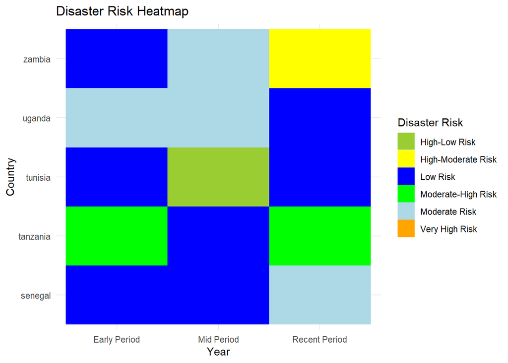

```r
combined_data_africa$Year <- as.factor(combined_data_africa$Temporal_Class)

heatmap_africa <- ggplot(combined_data_africa, aes(x = Year, y = Country, fill = Disaster_Risk)) +
  geom_tile() +
  scale_fill_manual(values = c(
    "Extremely High Risk" = "red",
    "Very High Risk" = "orange",
    "High-Moderate Risk" = "yellow",
    "High-Low Risk" = "yellowgreen",
    "Moderate-High Risk" = "green",
    "Moderate Risk" = "lightblue",
    "Low Risk" = "blue",
    "High Risk" = "purple",
    "Clustered Risk" = "skyblue",
    "Moderately High DataCards Risk" = "pink",
    "Moderately Less DataCards Risk" = "violet",
    "Least DataCards Risk" = "grey",
    "Undefined Risk" = "white"
  )) +
  labs(
    title = "Disaster Risk Heatmap",
    x = "Year",
    y = "Country",
    fill = "Disaster Risk"
  ) +
  theme_minimal()
print(heatmap_africa)
```

Cluster 2

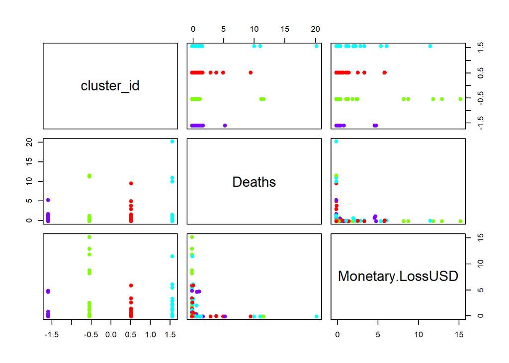

```r
tanzania_c$Country <- "Tanzania"
tunisia_c$Country <- "Tunisia"
senegal_c$Country <- "Sengeal"
zambia_c$Country <- "Zambia"
uganda_c$Country <- "Uganda"

africas <- rbind(tanzania_c,tunisia_c, senegal_c, zambia_c, uganda_c)
africas$cluster_id <- as.integer(as.character(africas$cluster_id))
data_for_clustering <-africas[, c("cluster_id", "Deaths", "Monetary.LossUSD")]

scaled_data <- scale(data_for_clustering)

set.seed(123)
clara_output <- clara(scaled_data, k = 4, samples = 500)
colors <- rainbow(length(unique(clara_output$clustering)))

scaled_data_with_clusters <- cbind(scaled_data, Cluster = clara_output$clustering)

pairs(scaled_data_with_clusters[, -ncol(scaled_data_with_clusters)],
      col = colors[clara_output$clustering], pch = 19)

legend("left", legend = unique(clara_output$clustering), fill = colors, title = "Clusters")
```

## AMERICA

Raw Data Reading

```r
guatemala <- read.csv("guatemala.csv",header=TRUE,na.strings=c(""))
colnames(guatemala) <- gsub("^\\s+|\\s+$", "", colnames(guatemala))#

drepublic <- read.csv("drepublic.csv",header=TRUE,na.strings=c(""))
colnames(drepublic) <- gsub("^\\s+|\\s+$", "", colnames(drepublic))

mexico <- read.csv("mexico.csv",header=TRUE,na.strings=c(""))
colnames(mexico) <- gsub("^\\s+|\\s+$", "", colnames(mexico))
```

Data PreProcessing: Missing Values, Duplicate Values

```r
print("Total Missing Values: ")
```

```
## [1] "Total Missing Values: "
```

```r
print(paste("Guatemala: ",sum(is.na(guatemala))))
```

```
## [1] "Guatemala:  1"
```

```r
print(paste("Drepublic: ",sum(is.na(drepublic))))
```

```
## [1] "Drepublic:  1"
```

```r
print(paste("Mexico: ",sum(is.na(mexico))))
```

```
## [1] "Mexico:  1"
```

```r
guatemala <- na.omit(guatemala, cols = c('Event'))

drepublic <- na.omit(drepublic, cols = c('Event'))

mexico <- na.omit(mexico, cols = c('Event'))
```

```r
print("Total Missing Values: ")
```

```
## [1] "Total Missing Values: "
```

```r
print(paste("Guatemala: ",sum(is.na(guatemala))))
```

```
## [1] "Guatemala:  0"
```

```r
print(paste("Drepublic: ",sum(is.na(drepublic))))
```

```
## [1] "Drepublic:  0"
```

```r
print(paste("Mexico: ",sum(is.na(mexico))))
```

```
## [1] "Mexico:  0"
```

```r
print("Total Duplicate values")
```

```
## [1] "Total Duplicate values"
```

```r
print(paste("Guatemala: ", sum(duplicated(guatemala))))
```

```
## [1] "Guatemala:  0"
```

```r
print(paste("DRepublic: ", sum(duplicated(drepublic))))
```

```
## [1] "DRepublic:  0"
```

```r
print(paste("Mexico: ", sum(duplicated(mexico))))
```

```
## [1] "Mexico:  0"
```

```r
guatemala$Event <- toupper(guatemala$Event)
drepublic$Event <- toupper(drepublic$Event)
mexico$Event <- toupper(mexico$Event)
```

```r
unique_events <- unique(mexico$Event)

translation_dict <- c(
  "HAMBRUNA" = "FAMINE",
  "RACIONAMIENTO" = "RATIONING",
  "ONDA FRÍA" = "COLD WAVE",
  "INTOXICACIÓN" = "INTOXICATION",
  "HUNDIMIENTO" = "SINKING"
)
translate_mexican_to_english <- function(text) {
  cleaned_text <- toupper(trimws(text))
  translated_text <- ifelse(cleaned_text %in% names(translation_dict), translation_dict[[cleaned_text]], text)
  return(translated_text)
}

mexico$Event <- sapply(mexico$Event, translate_mexican_to_english)
```

Data Tranformation

```r
guatemala$Houses.Ruined <- guatemala$Houses.Destroyed + guatemala$Houses.Damaged
guatemala$Affected <-guatemala$Directly.affected + guatemala$Indirectly.Affected

guatemala$Monetary.LossUSD<- guatemala$Losses..USD + guatemala$Losses..Local * (0.13)
guatemala$Monetary.LossUSD <- as.integer(guatemala$Monetary.LossUSD)

guatemala= select(guatemala, -5:-10)
head(guatemala)
```

```
##   Year         Event DataCards Deaths Houses.Ruined Affected Monetary.LossUSD
## 1 1988      ACCIDENT         4      0             4        6                0
## 2 1988    EARTHQUAKE         5      0           190      425            26500
## 3 1988 ELECTRICSTORM         1      5             1        0                0
## 4 1988      EPIDEMIC         7      1             0        0                0
## 5 1988     EXPLOSION         4      0             2        0                0
## 6 1988          FIRE        53      8            53      386          7707842
```

```r
summary(guatemala)
```

```
##      Year              Event             DataCards          Deaths
##  Length:437         Length:437         Min.   :  1.00   Min.   :  0.000
##  Class :character   Class :character   1st Qu.:  2.00   1st Qu.:  0.000
##  Mode  :character   Mode  :character   Median :  4.00   Median :  0.000
##                                        Mean   : 17.28   Mean   :  8.709
##                                        3rd Qu.: 17.00   3rd Qu.:  4.000
##                                        Max.   :423.00   Max.   :417.000
##  Houses.Ruined        Affected       Monetary.LossUSD
##  Min.   :    0.0   Min.   :      0   Min.   :        0
##  1st Qu.:    0.0   1st Qu.:      0   1st Qu.:        0
##  Median :    3.0   Median :     60   Median :        0
##  Mean   :  634.5   Mean   :  29633   Mean   :  2147681
##  3rd Qu.:   94.0   3rd Qu.:   2047   3rd Qu.:    28000
##  Max.   :55952.0   Max.   :2471091   Max.   :213330000
```

```r
drepublic$Houses.Ruined <- drepublic$Houses.Destroyed +drepublic$Houses.Damaged
drepublic$Affected <-drepublic$Directly.affected + drepublic$Indirectly.Affected

drepublic$Monetary.LossUSD<- drepublic$Losses..USD + drepublic$Losses..Local * (0.017)
drepublic$Monetary.LossUSD <- as.integer(drepublic$Monetary.LossUSD)

drepublic= select(drepublic, -5:-10)
head(drepublic)
```

```
##   Year    Event DataCards Deaths Houses.Ruined Affected Monetary.LossUSD
## 1 1966     FIRE        24      2           133     1201            21809
## 2 1966    FLOOD         2     20             1        0                0
## 3 1966   PLAGUE         1      0             0        0                0
## 4 1966    SURGE         1      0             8        0                0
## 5 1967 ACCIDENT         1      0             0        0                0
## 6 1967  DROUGHT         1      0             0        0                0
```

```r
summary(drepublic)
```

```
##      Year              Event             DataCards          Deaths
##  Length:345         Length:345         Min.   : 1.000   Min.   :  0.000
##  Class :character   Class :character   1st Qu.: 1.000   1st Qu.:  0.000
##  Mode  :character   Mode  :character   Median : 3.000   Median :  0.000
##                                        Mean   : 6.122   Mean   :  3.104
##                                        3rd Qu.: 7.000   3rd Qu.:  2.000
##                                        Max.   :55.000   Max.   :111.000
##  Houses.Ruined        Affected        Monetary.LossUSD
##  Min.   :   0.00   Min.   :     0.0   Min.   :       0
##  1st Qu.:   0.00   1st Qu.:     0.0   1st Qu.:       0
##  Median :   0.00   Median :     0.0   Median :       0
##  Mean   :  24.63   Mean   :   703.7   Mean   :  222755
##  3rd Qu.:   2.00   3rd Qu.:     0.0   3rd Qu.:       0
##  Max.   :1100.00   Max.   :112500.0   Max.   :19250000
```

```r
mexico$Houses.Ruined <-mexico$Houses.Destroyed + mexico$Houses.Damaged
mexico$Affected <-mexico$Directly.affected + mexico$Indirectly.Affected

mexico$Monetary.LossUSD<-mexico$Losses..USD + mexico$Losses..Local * (0.060)
mexico$Monetary.LossUSD <- as.integer(mexico$Monetary.LossUSD)
# AS There were 19 values higher than e9
mexico$Monetary.LossUSD[is.na(mexico$Monetary.LossUSD)] <- max(mexico$Monetary.LossUSD, na.rm = TRUE)
mexico= select(mexico, -5:-10)
summary(mexico)
```

```
##      Year              Event             DataCards          Deaths
##  Length:1176        Length:1176        Min.   :  1.00   Min.   :    0.00
##  Class :character   Class :character   1st Qu.:  4.00   1st Qu.:    0.00
##  Mode  :character   Mode  :character   Median : 12.00   Median :    5.00
##                                        Mean   : 36.08   Mean   :   41.34
##                                        3rd Qu.: 34.00   3rd Qu.:   21.00
##                                        Max.   :962.00   Max.   :10057.00
##  Houses.Ruined         Affected        Monetary.LossUSD
##  Min.   :     0.0   Min.   :       0   Min.   :0.000e+00
##  1st Qu.:     0.0   1st Qu.:       0   1st Qu.:0.000e+00
##  Median :     0.0   Median :       0   Median :0.000e+00
##  Mean   :  3528.0   Mean   :  132819   Mean   :2.336e+07
##  3rd Qu.:   100.2   3rd Qu.:    7000   3rd Qu.:4.575e+04
##  Max.   :751071.0   Max.   :50700000   Max.   :1.600e+09
```

Feature Addition 1

```r
add_Event_Severity <- function(data) {
  data$Event_Severity <- data$Deaths / data$DataCards

  a_countries <- c("mexico")
  b_countries <- c("guatemala", "drepublic")

  for (country in a_countries) {
    data$Event_Severity[data$Country == country & data$Event_Severity > 1] <- 1
    data$Event_Severity[data$Country == country & data$Event_Severity < 0.5] <- 0.5
  }

  for (country in b_countries) {
    data$Event_Severity[data$Country == country & data$Event_Severity > 2] <- 2
    data$Event_Severity[data$Country == country & data$Event_Severity < 1] <- 1
  }
  data$Event_Severity <- round(data$Event_Severity * 100)
  return(data$Event_Severity)
}

guatemala$Event_Severity <- add_Event_Severity(guatemala)
drepublic$Event_Severity <- add_Event_Severity(drepublic)
mexico$Event_Severity <- add_Event_Severity(mexico)
```

Feature Addition 2

```r
guatemala$Event_factor<-as.integer(as.factor(guatemala$Event))
drepublic$Event_factor<-as.integer(as.factor(drepublic$Event))
mexico$Event_factor<-as.integer(as.factor(mexico$Event))
```

Write Cleaned csv

```r
write.csv(guatemala, file = "guatemala_cleaned.csv", row.names = FALSE)
write.csv(drepublic, file = "drepublic_cleaned.csv", row.names = FALSE)
write.csv(mexico, file = "mexico_cleaned.csv", row.names = FALSE)
```

Read Cleaned csv

```r
guatemala_c <- read.csv("guatemala_cleaned.csv",header=TRUE)
drepublic_c <- read.csv("drepublic_cleaned.csv",header=TRUE)
mexico_c <- read.csv("mexico_cleaned.csv",header=TRUE)
```

Combining into America

```r
america <- rbind(guatemala_c,drepublic_c,mexico_c)
```

#Preprocessing Visualization America

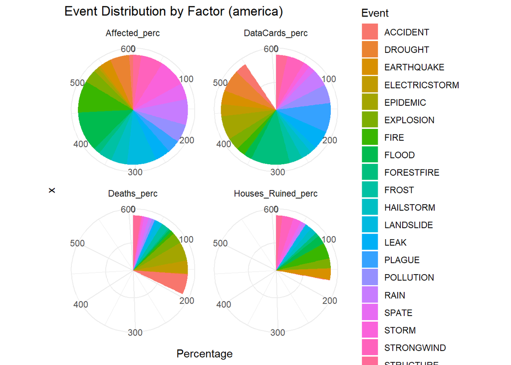

```r
america_perc <- america %>%
  mutate(
    Total = DataCards + Deaths + `Houses.Ruined` + Affected,
    DataCards_perc = DataCards / Total,
    Deaths_perc = Deaths / Total,
    Houses_Ruined_perc = `Houses.Ruined` / Total,
    Affected_perc = Affected / Total
  ) %>%
  select(Event, DataCards_perc, Deaths_perc, Houses_Ruined_perc, Affected_perc)

america_long <- america_perc %>%
  pivot_longer(cols = -Event, names_to = "Factor", values_to = "Percentage")

threshold <- 50

filtered_america_long <- america_long %>%
  group_by(Event) %>%
  summarise(Total_Percentage = sum(Percentage)) %>%
  filter(Total_Percentage > threshold) %>%
  inner_join(america_long, by = "Event") %>%
  ungroup()

ggplot(filtered_america_long, aes(x = "", y = Percentage, fill = Event)) +
  geom_bar(stat = "identity", width = 1) +
  facet_wrap(~Factor) +
  coord_polar(theta = "y") +
  theme_minimal() +
  ggtitle("Event Distribution by Factor (america)")
```

Preprocessing Visualization

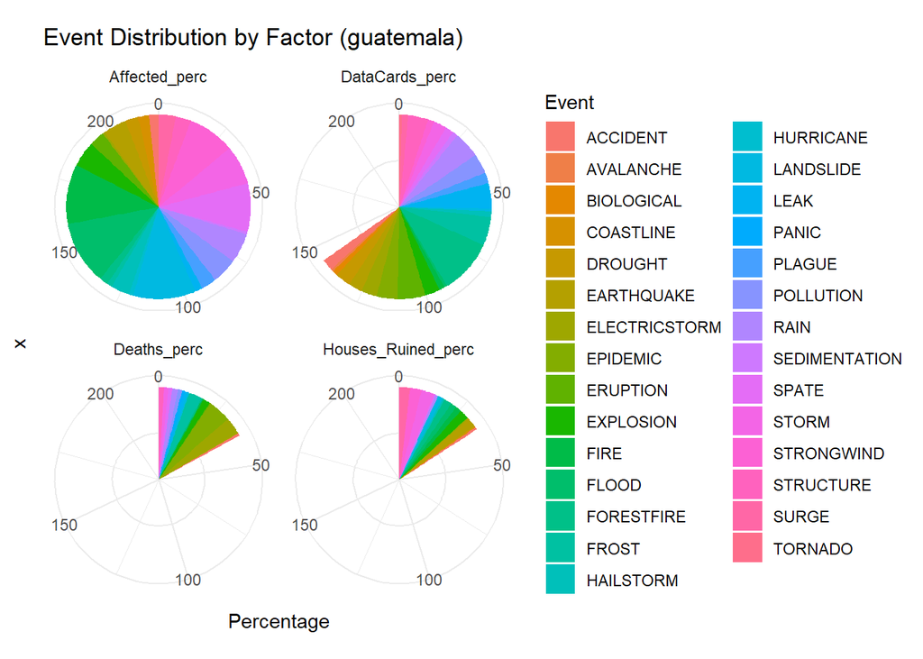

```r
guatemala_c<- guatemala_c %>%
  mutate(Total = DataCards + Deaths + Houses.Ruined + Affected)

 guatemala_c_perc <- guatemala_c %>%
  mutate(
    DataCards_perc = DataCards / Total,
    Deaths_perc = Deaths / Total,
    Houses_Ruined_perc = Houses.Ruined / Total,
    Affected_perc = Affected / Total
  ) %>%
  select(Event, DataCards_perc, Deaths_perc, Houses_Ruined_perc, Affected_perc)

guatemala_c_long <-  guatemala_c_perc %>%
  pivot_longer(cols = -Event, names_to = "Factor", values_to = "Percentage")

ggplot( guatemala_c_long, aes(x = "", y = Percentage, fill = Event)) +
  geom_bar(stat = "identity", width = 1) +
  facet_wrap(~Factor) +  # Separate pie for each factor
  coord_polar(theta = "y") +
  theme_minimal() +
  ggtitle("Event Distribution by Factor (guatemala)")
```

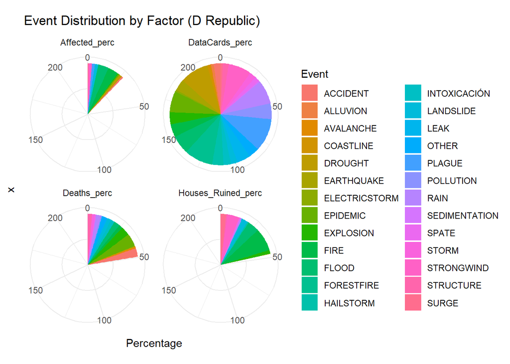

```r
drepublic_c<- drepublic_c %>%
  mutate(Total = DataCards + Deaths + Houses.Ruined + Affected)

drepublic_c_perc <- drepublic_c %>%
  mutate(
    DataCards_perc = DataCards / Total,
    Deaths_perc = Deaths / Total,
    Houses_Ruined_perc = Houses.Ruined / Total,
    Affected_perc = Affected / Total
  ) %>%
  select(Event, DataCards_perc, Deaths_perc, Houses_Ruined_perc, Affected_perc)

 drepublic_c_long <-  drepublic_c_perc %>%
  pivot_longer(cols = -Event, names_to = "Factor", values_to = "Percentage")

ggplot( drepublic_c_long, aes(x = "", y = Percentage, fill = Event)) +
  geom_bar(stat = "identity", width = 1) +
  facet_wrap(~Factor) +  # Separate pie for each factor
  coord_polar(theta = "y") +
  theme_minimal() +
  ggtitle("Event Distribution by Factor (D Republic)")
```

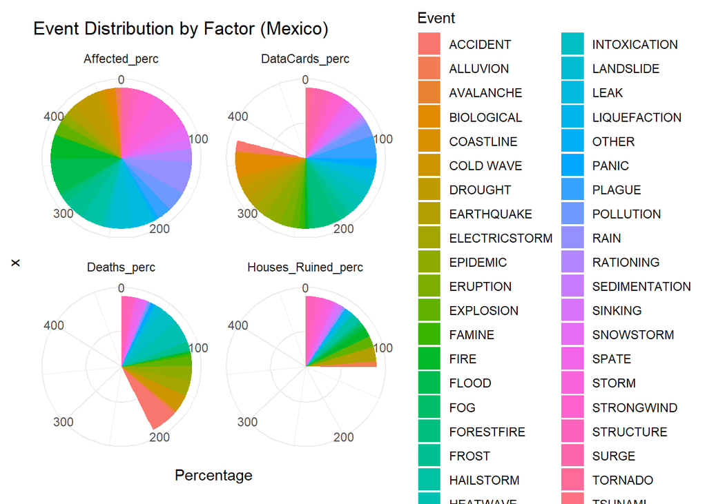

```r
mexico_c<- mexico_c %>%
  mutate(Total = DataCards + Deaths + Houses.Ruined + Affected)

 mexico_c_perc <- mexico_c %>%
  mutate(
    DataCards_perc = DataCards / Total,
    Deaths_perc = Deaths / Total,
    Houses_Ruined_perc = Houses.Ruined / Total,
    Affected_perc = Affected / Total
  ) %>%
  select(Event, DataCards_perc, Deaths_perc, Houses_Ruined_perc, Affected_perc)

 mexico_c_long <-  mexico_c_perc %>%
  pivot_longer(cols = -Event, names_to = "Factor", values_to = "Percentage")

ggplot( mexico_c_long, aes(x = "", y = Percentage, fill = Event)) +
  geom_bar(stat = "identity", width = 1) +
  facet_wrap(~Factor) +  # Separate pie for each factor
  coord_polar(theta = "y") +
  theme_minimal() +
  ggtitle("Event Distribution by Factor (Mexico)")
```

Split(America) and parameter

```r
# Get only numeric Values
numeric_data <- america [, sapply(america , is.numeric)]

# find PCA
scaled_data <- scale(numeric_data)
pca_result <- prcomp(scaled_data, center = TRUE, scale. = TRUE)
summary(pca_result)
```

```
## Importance of components:
##                          PC1    PC2    PC3    PC4    PC5     PC6     PC7    PC8
## Standard deviation     1.400 1.2824 1.0045 0.9999 0.9674 0.88241 0.73187 0.3699
## Proportion of Variance 0.245 0.2056 0.1261 0.1250 0.1170 0.09733 0.06695 0.0171
## Cumulative Proportion  0.245 0.4506 0.5767 0.7016 0.8186 0.91595 0.98290 1.0000
```

```r
formula <- numeric_data$Deaths ~ numeric_data$DataCards + numeric_data$Deaths + numeric_data$Monetary.LossUSD + numeric_data$Event_Severity + numeric_data$Houses.Ruined + numeric_data$Affected
  model <- lm(formula, data = numeric_data)

  vif_result <- car::vif(model)

  cat("\n","VIF results for Deaths", ":\n")
```

```
##
##  VIF results for Deaths :
```

```r
  print(vif_result)
```

```
##                                   GVIF Df GVIF^(1/(2*Df))
## numeric_data$DataCards        1.272887  1        1.128223
## numeric_data$Deaths           1.341378  0             Inf
## numeric_data$Monetary.LossUSD 1.080808  1        1.039619
## numeric_data$Event_Severity   1.027241  1        1.013529
## numeric_data$Houses.Ruined    1.272841  1        1.128203
## numeric_data$Affected         1.034224  1        1.016968
```

```r
  cat("\n")
```

```r
#check for correlation matrix
cor_matrix <- cor(numeric_data)
print("Correlation matrix ")
```

```
## [1] "Correlation matrix "
```

```r
print(cor_matrix)
```

```
##                          Year    DataCards       Deaths Houses.Ruined
## Year              1.000000000  0.218300796 -0.007227151    0.06376128
## DataCards         0.218300796  1.000000000  0.064532028    0.41778207
## Deaths           -0.007227151  0.064532028  1.000000000    0.17163585
## Houses.Ruined     0.063761277  0.417782072  0.171635847    1.00000000
## Affected          0.045180773  0.173947956  0.011633085    0.08851005
## Monetary.LossUSD  0.005882578  0.224343043  0.026248388    0.22750223
## Event_Severity   -0.057051614 -0.024427350  0.857913444    0.13507526
## Event_factor      0.020503795  0.004994227 -0.032928329    0.02583724
##                      Affected Monetary.LossUSD Event_Severity Event_factor
## Year              0.045180773     0.0058825781  -0.0570516145  0.020503795
## DataCards         0.173947956     0.2243430432  -0.0244273495  0.004994227
## Deaths            0.011633085     0.0262483877   0.8579134444 -0.032928329
## Houses.Ruined     0.088510051     0.2275022332   0.1350752596  0.025837241
## Affected          1.000000000     0.0900440808  -0.0021050312  0.033305383
## Monetary.LossUSD  0.090044081     1.0000000000  -0.0000284968  0.011204178
## Event_Severity   -0.002105031    -0.0000284968   1.0000000000 -0.051614101
## Event_factor      0.033305383     0.0112041783  -0.0516141007  1.000000000
```

```r
set.seed(123)
split_indices <- createDataPartition(america$Year, p = 0.7, list = FALSE)

training_data_america  <- numeric_data[split_indices, ]
testing_data_america  <- numeric_data[-split_indices, ]
```

Model 1 enet on death ~ !Event - 28 % accuracy

```r
train_data <- training_data_america
test_data <-  testing_data_america

X_train <- as.matrix(subset(train_data, select =- c(Deaths)))
y_train <- train_data$Deaths
X_test <- as.matrix(subset(test_data, select = - c(Deaths)))
y_test <- test_data$Deaths

X_train_std <- scale(X_train)
X_test_std <- scale(X_test)

enet_model_combined<- cv.glmnet(X_train_std, y_train, alpha = 0.5)

best_lambda <- enet_model_combined$lambda.min

y_pred <- predict(enet_model_combined, newx = X_test_std, s = best_lambda)

mse <- mean((y_pred - y_test)^2)
rsquared <- cor(y_pred, y_test)^2

cat("Best Lambda:", best_lambda, "\n")
```

```
## Best Lambda: 1.346766
```

```r
cat("Mean Squared Error:", mse, "\n")
```

```
## Mean Squared Error: 48470.66
```

```r
cat("R-squared:", rsquared, "\n")
```

```
## R-squared: 0.2887946
```

#Model 2 random forest on death ~ !Event - 44% accuracy

```r
rf_model_complex <- randomForest(
  X_train, y_train,
  ntree = 1000,
  mtry = sqrt(ncol(X_train)),
  max_depth = NULL
)

y_pred_rf_complex <- predict(rf_model_complex, X_test, type = "response")
mse_rf_complex <- mean((y_pred_rf_complex - y_test)^2)
rsquared_rf_complex <- cor(y_pred_rf_complex, y_test)^2

cat("Random Forest- Mean Squared Error:", mse_rf_complex, "\n")
```

```
## Random Forest- Mean Squared Error: 19388.63
```

```r
cat("Random Forest - R-squared:", rsquared_rf_complex, "\n")
```

```
## Random Forest - R-squared: 0.4368699
```

Split(Indivisual)

```r
set.seed(123)
split_indices <- createDataPartition(guatemala_c$Year, p = 0.7, list = FALSE)

training_data_guatemala <- guatemala_c[split_indices, ]
testing_data_guatemala <- guatemala_c[-split_indices, ]
```

```r
set.seed(123)
split_indices <- createDataPartition(drepublic_c$Year, p = 0.7, list = FALSE)

training_data_drepublic <- drepublic_c[split_indices, ]
testing_data_drepublic <- drepublic_c[-split_indices, ]
```

```r
set.seed(123)
split_indices <- createDataPartition(mexico_c$Year, p = 0.7, list = FALSE)

training_data_mexico <- mexico_c[split_indices, ]
testing_data_mexico <- mexico_c[-split_indices, ]
```

PCA VIF AND CORR MATRIX

```r
guatemala_no_event <- guatemala_c[, !names(guatemala_c) %in% c("Event", "Monetary.LossUSD")]
scaled_data <- scale(guatemala_no_event)
pca_result <- prcomp(scaled_data, center = TRUE, scale. = TRUE)
summary(pca_result)
```

```
## Importance of components:
##                           PC1    PC2    PC3    PC4    PC5     PC6     PC7
## Standard deviation     1.7555 1.1722 1.0189 0.9221 0.9026 0.71790 0.57082
## Proportion of Variance 0.3852 0.1717 0.1298 0.1063 0.1018 0.06442 0.04073
## Cumulative Proportion  0.3852 0.5569 0.6867 0.7930 0.8949 0.95927 1.00000
##                              PC8
## Standard deviation     3.716e-16
## Proportion of Variance 0.000e+00
## Cumulative Proportion  1.000e+00
```

```r
formula <- guatemala_c$Deaths ~ guatemala_c$DataCards + guatemala_c$Deaths + guatemala_c$Event_Severity + guatemala_c$Houses.Ruined + guatemala_c$Affected
  model <- lm(formula, data = guatemala_c)

  vif_result <- car::vif(model)

  cat("\n","VIF results for Deaths", ":\n")
```

```
##
##  VIF results for Deaths :
```

```r
  print(vif_result)
```

```
##                                GVIF Df GVIF^(1/(2*Df))
## guatemala_c$DataCards      1.436679  1        1.198616
## guatemala_c$Deaths         1.636645  0             Inf
## guatemala_c$Event_Severity 1.004315  1        1.002155
## guatemala_c$Houses.Ruined  1.502854  1        1.225909
## guatemala_c$Affected       1.432736  1        1.196970
```

```r
  cat("\n")
```

```r
cor_matrix <- cor(guatemala_c[c("DataCards", "Deaths", "Monetary.LossUSD", "Event_Severity", "Houses.Ruined", "Affected")])
print("Correlation matrix ")
```

```
## [1] "Correlation matrix "
```

```r
print(cor_matrix)
```

```
##                    DataCards       Deaths Monetary.LossUSD Event_Severity
## DataCards         1.00000000  0.402737655     0.0208685674   -0.035553869
## Deaths            0.40273766  1.000000000    -0.0031096819    0.373130018
## Monetary.LossUSD  0.02086857 -0.003109682     1.0000000000    0.021475817
## Event_Severity   -0.03555387  0.373130018     0.0214758168    1.000000000
## Houses.Ruined     0.49200689  0.564280096    -0.0003059186    0.029551232
## Affected          0.45523828  0.315533529     0.0084537866   -0.008418778
##                  Houses.Ruined     Affected
## DataCards         0.4920068941  0.455238281
## Deaths            0.5642800959  0.315533529
## Monetary.LossUSD -0.0003059186  0.008453787
## Event_Severity    0.0295512322 -0.008418778
## Houses.Ruined     1.0000000000  0.491910483
## Affected          0.4919104834  1.000000000
```

```r
drepublic_no_event <- drepublic_c[, !names(drepublic_c) %in% c("Event")]
scaled_data <- scale(drepublic_no_event)
pca_result <- prcomp(scaled_data, center = TRUE, scale. = TRUE)
summary(pca_result)
```

```
## Importance of components:
##                           PC1    PC2    PC3    PC4    PC5     PC6     PC7
## Standard deviation     1.4348 1.3305 1.1795 1.0423 0.9754 0.92360 0.77294
## Proportion of Variance 0.2287 0.1967 0.1546 0.1207 0.1057 0.09478 0.06638
## Cumulative Proportion  0.2287 0.4254 0.5800 0.7007 0.8064 0.90120 0.96758
##                            PC8       PC9
## Standard deviation     0.54016 3.392e-16
## Proportion of Variance 0.03242 0.000e+00
## Cumulative Proportion  1.00000 1.000e+00
```

```r
formula <- drepublic_c$Deaths ~ drepublic_c$DataCards +drepublic_c$Monetary.LossUSD +drepublic_c$Deaths + drepublic_c$Event_Severity + drepublic_c$Houses.Ruined + drepublic_c$Affected
  model <- lm(formula, data = drepublic_c)

  vif_result <- car::vif(model)

  cat("\n","VIF results for Deaths", ":\n")
```

```
##
##  VIF results for Deaths :
```

```r
  print(vif_result)
```

```
##                                  GVIF Df GVIF^(1/(2*Df))
## drepublic_c$DataCards        1.247279  1        1.116816
## drepublic_c$Monetary.LossUSD 1.033903  1        1.016810
## drepublic_c$Deaths           1.259997  0             Inf
## drepublic_c$Event_Severity   1.003975  1        1.001986
## drepublic_c$Houses.Ruined    1.206190  1        1.098267
## drepublic_c$Affected         1.008275  1        1.004129
```

```r
  cat("\n")
```

```r
cor_matrix <- cor(drepublic_c[c("DataCards", "Deaths", "Monetary.LossUSD", "Event_Severity", "Houses.Ruined", "Affected")])
print("Correlation matrix ")
```

```
## [1] "Correlation matrix "
```

```r
print(cor_matrix)
```

```
##                    DataCards      Deaths Monetary.LossUSD Event_Severity
## DataCards         1.00000000  0.29337450       0.15397687   -0.057067709
## Deaths            0.29337450  1.00000000      -0.04094509    0.600069054
## Monetary.LossUSD  0.15397687 -0.04094509       1.00000000   -0.030596764
## Event_Severity   -0.05706771  0.60006905      -0.03059676    1.000000000
## Houses.Ruined     0.40372137  0.12288548      -0.02245295   -0.009500601
## Affected          0.08663996  0.01506149       0.00522444   -0.012266156
##                  Houses.Ruined    Affected
## DataCards          0.403721372  0.08663996
## Deaths             0.122885480  0.01506149
## Monetary.LossUSD  -0.022452953  0.00522444
## Event_Severity    -0.009500601 -0.01226616
## Houses.Ruined      1.000000000  0.01372309
## Affected           0.013723091  1.00000000
```

```r
mexico_no_event <- mexico_c[, !names(mexico_c) %in% c("Event")]
scaled_data <- scale(mexico_no_event)
pca_result <- prcomp(scaled_data, center = TRUE, scale. = TRUE)
summary(pca_result)
```

```
## Importance of components:
##                           PC1    PC2    PC3    PC4    PC5     PC6     PC7
## Standard deviation     1.4815 1.3892 1.2112 1.0083 0.9918 0.87856 0.72197
## Proportion of Variance 0.2439 0.2144 0.1630 0.1130 0.1093 0.08576 0.05792
## Cumulative Proportion  0.2439 0.4583 0.6213 0.7342 0.8435 0.92930 0.98722
##                            PC8       PC9
## Standard deviation     0.33920 6.109e-16
## Proportion of Variance 0.01278 0.000e+00
## Cumulative Proportion  1.00000 1.000e+00
```

```r
formula <- mexico_c$Deaths ~ mexico_c$DataCards + mexico_c$Deaths +mexico_c$Monetary.LossUSD+ mexico_c$Event_Severity + mexico_c$Houses.Ruined + mexico_c$Affected
  model <- lm(formula, data = mexico_c)

  vif_result <- car::vif(model)

  cat("\n","VIF results for Deaths", ":\n")
```

```
##
##  VIF results for Deaths :
```

```r
  print(vif_result)
```

```
##                               GVIF Df GVIF^(1/(2*Df))
## mexico_c$DataCards        1.276602  1        1.129868
## mexico_c$Deaths           1.347220  0             Inf
## mexico_c$Monetary.LossUSD 1.077880  1        1.038210
## mexico_c$Event_Severity   1.030450  1        1.015111
## mexico_c$Houses.Ruined    1.277772  1        1.130386
## mexico_c$Affected         1.031723  1        1.015738
```

```r
  cat("\n")
```

```r
cor_matrix <- cor(mexico_c[c("DataCards", "Deaths", "Monetary.LossUSD", "Event_Severity", "Houses.Ruined", "Affected")])
print("Correlation matrix ")
```

```
## [1] "Correlation matrix "
```

```r
print(cor_matrix)
```

```
##                    DataCards      Deaths Monetary.LossUSD Event_Severity
## DataCards         1.00000000 0.047942454      0.220494059   -0.036780210
## Deaths            0.04794245 1.000000000      0.020142729    0.880049571
## Monetary.LossUSD  0.22049406 0.020142729      1.000000000   -0.006312302
## Event_Severity   -0.03678021 0.880049571     -0.006312302    1.000000000
## Houses.Ruined     0.42021967 0.165713685      0.223623226    0.135481248
## Affected          0.16776933 0.007368622      0.086301222   -0.005063216
##                  Houses.Ruined     Affected
## DataCards           0.42021967  0.167769330
## Deaths              0.16571369  0.007368622
## Monetary.LossUSD    0.22362323  0.086301222
## Event_Severity      0.13548125 -0.005063216
## Houses.Ruined       1.00000000  0.083356631
## Affected            0.08335663  1.000000000
```

Regression Model and Visual Guatemala - Model 2- 0.62 death ~ - c(Event, Deaths)

```r
y <- training_data_guatemala$Deaths
X <- subset(training_data_guatemala, select = - c(Event,Deaths))

train_data <- training_data_guatemala
test_data <-  testing_data_guatemala

X_train <- as.matrix(subset(train_data, select = - c(Event,Deaths)))
y_train <- train_data$Deaths
X_test <- as.matrix(subset(test_data, select = - c(Event,Deaths)))
y_test <- test_data$Deaths

rf_model_complex <- randomForest(
  X_train, y_train,
  ntree = 1000,
  mtry = sqrt(ncol(X_train)),
  max_depth = NULL
)

y_pred_rf_complex <- predict(rf_model_complex, X_test, type = "response")
mse_rf_complex <- mean((y_pred_rf_complex - y_test)^2)
rsquared_rf_complex <- cor(y_pred_rf_complex, y_test)^2

cat("Random Forest- Mean Squared Error:", mse_rf_complex, "\n")
```

```
## Random Forest- Mean Squared Error: 465.394
```

```r
cat("Random Forest - R-squared:", rsquared_rf_complex, "\n")
```

```
## Random Forest - R-squared: 0.6250527
```

Dominican Republic model 2 - 0.54 death ~ - c(Event, Deaths) model 1 perform 0.88

```r
y <- training_data_drepublic$Deaths
X <- subset(training_data_drepublic, select =-  c(Event, Deaths))  # Selecting features not to include

train_data <- training_data_drepublic
test_data <-  testing_data_drepublic

X_train <- as.matrix(subset(train_data, select = - c(Event,Deaths)))
y_train <- train_data$Deaths
X_test <- as.matrix(subset(test_data, select = - c(Event,Deaths)))
y_test <- test_data$Deaths

rf_model_complex <- randomForest(
  X_train, y_train,
  ntree = 1000,
  mtry = sqrt(ncol(X_train)),
  max_depth = NULL
)

y_pred_rf_complex <- predict(rf_model_complex, X_test, type = "response")
mse_rf_complex <- mean((y_pred_rf_complex - y_test)^2)
rsquared_rf_complex <- cor(y_pred_rf_complex, y_test)^2

cat("Random Forest- Mean Squared Error:", mse_rf_complex, "\n")
```

```
## Random Forest- Mean Squared Error: 70.45896
```

```r
cat("Random Forest - R-squared:", rsquared_rf_complex, "\n")
```

```
## Random Forest - R-squared: 0.5497015
```

```r
y <- training_data_mexico$Deaths
X <- subset(training_data_mexico, select =-  c(Event, Deaths) )  # Selecting features not to include

train_data <- training_data_mexico
test_data <-  testing_data_mexico

X_train <- as.matrix(subset(train_data, select = - c(Event,Deaths)))
y_train <- train_data$Deaths
X_test <- as.matrix(subset(test_data, select = - c(Event,Deaths)))
y_test <- test_data$Deaths

rf_model_complex <- randomForest(
  X_train, y_train,
  ntree = 1000,
  mtry = sqrt(ncol(X_train)),
  max_depth = NULL
)

y_pred_rf_complex <- predict(rf_model_complex, X_test, type = "response")
mse_rf_complex <- mean((y_pred_rf_complex - y_test)^2)
rsquared_rf_complex <- cor(y_pred_rf_complex, y_test)^2

cat("Random Forest- Mean Squared Error:", mse_rf_complex, "\n")
```

```
## Random Forest- Mean Squared Error: 232842.3
```

```r
cat("Random Forest - R-squared:", rsquared_rf_complex, "\n")
```

```
## Random Forest - R-squared: 0.6684824
```

#Cluster 1

```r
guatemala_c$Severity_Class <- ifelse(guatemala_c$Event_Severity >= mean(guatemala_c$Event_Severity), "High Severity", "Low Severity")

year_quantiles <- quantile(guatemala_c$Year, probs = c(0, 1/3, 2/3, 1))

guatemala_c$Temporal_Class <- cut(guatemala_c$Year,
                                  breaks = year_quantiles,
                                  labels = c("Early Period", "Mid Period", "Recent Period"),
                                  include.lowest = TRUE)

guatemala_c$Combined_Impact <- rowSums(subset(guatemala_c, select =  c(Deaths, Houses.Ruined, Affected, Monetary.LossUSD)))

quantiles <- quantile(guatemala_c$Combined_Impact, probs = c(0, 0.25, 0.75, 1))

guatemala_c$Impact_Class <- cut(guatemala_c$Combined_Impact,
                                breaks = quantiles,
                                labels = c("Minimal Impact", "Moderate Impact", "Severe Impact"),
                                include.lowest = TRUE)


kmeans_result <- kmeans(guatemala_c$DataCards, centers = 4)
guatemala_c$cluster_id <- factor(kmeans_result$cluster)

cluster_means <- aggregate(guatemala_c$DataCards, by = list(guatemala_c$cluster_id), FUN = mean)

sorted_clusters <- cluster_means[order(cluster_means$x),]

label_mapping <- c("Most DataCards", "Moderately High DataCards", "Moderately Less DataCards", "Least DataCards")

guatemala_c$cluster_label <- label_mapping[match(guatemala_c$cluster_id, sorted_clusters$Group.1)]
```

```r
drepublic_c$Severity_Class <- ifelse(drepublic_c$Event_Severity >= mean(drepublic_c$Event_Severity), "High Severity", "Low Severity")

year_quantiles <- quantile(drepublic_c$Year, probs = c(0, 1/3, 2/3, 1))

drepublic_c$Temporal_Class <- cut(drepublic_c$Year,
                                  breaks = year_quantiles,
                                  labels = c("Early Period", "Mid Period", "Recent Period"),
                                  include.lowest = TRUE)

drepublic_c$Combined_Impact <- rowSums(subset(drepublic_c, select =  c(Deaths, Houses.Ruined, Affected, Monetary.LossUSD)))

quantiles <- quantile(drepublic_c$Combined_Impact, probs = c(0, 0.25, 0.75, 1))

quantiles <- unique(quantiles)

labels <- c("Minimal Impact", "Moderate Impact", "Severe Impact", "Very Severe Impact")
drepublic_c$Impact_Class <- cut(drepublic_c$Combined_Impact,
                            breaks = quantiles,
                            labels = labels[1:(length(quantiles) - 1)],
                            include.lowest = TRUE)

kmeans_result <- kmeans(drepublic_c$DataCards, centers = 4)
drepublic_c$cluster_id <- factor(kmeans_result$cluster)

cluster_means <- aggregate(drepublic_c$DataCards, by = list(drepublic_c$cluster_id), FUN = mean)

sorted_clusters <- cluster_means[order(cluster_means$x),]

label_mapping <- c("Most DataCards", "Moderately High DataCards", "Moderately Less DataCards", "Least DataCards")

drepublic_c$cluster_label <- label_mapping[match(drepublic_c$cluster_id, sorted_clusters$Group.1)]
```

```r
mexico_c$Severity_Class <- ifelse(mexico_c$Event_Severity >= mean(mexico_c$Event_Severity), "High Severity", "Low Severity")

year_quantiles <- quantile(mexico_c$Year, probs = c(0, 1/3, 2/3, 1))

mexico_c$Temporal_Class <- cut(mexico_c$Year,
                                  breaks = year_quantiles,
                                  labels = c("Early Period", "Mid Period", "Recent Period"),
                                  include.lowest = TRUE)

mexico_c$Combined_Impact <- rowSums(subset(mexico_c, select =  c(Deaths, Houses.Ruined, Affected, Monetary.LossUSD)))

quantiles <- quantile(mexico_c$Combined_Impact, probs = c(0, 0.25, 0.75, 1))
mexico_c$Impact_Class <- cut(mexico_c$Combined_Impact,
                                breaks = quantiles,
                                labels = c("Minimal Impact", "Moderate Impact", "Severe Impact"),
                                include.lowest = TRUE)


kmeans_result <- kmeans(mexico_c$DataCards, centers = 4)
mexico_c$cluster_id <- factor(kmeans_result$cluster)

cluster_means <- aggregate(mexico_c$DataCards, by = list(mexico_c$cluster_id), FUN = mean)

sorted_clusters <- cluster_means[order(cluster_means$x),]

label_mapping <- c("Most DataCards", "Moderately High DataCards", "Moderately Less DataCards", "Least DataCards")

mexico_c$cluster_label <- label_mapping[match(mexico_c$cluster_id, sorted_clusters$Group.1)]
```

```r
combined_data_america <- rbind(
  data.frame(Country = "Guatemala", Severity_Class = guatemala_c$Severity_Class, Temporal_Class =guatemala_c$Temporal_Class, Impact_Class = guatemala_c$Impact_Class,  cluster_id =  guatemala_c$cluster_label, Year = guatemala_c$Year ),
  data.frame(Country = "Dominican Republic", Severity_Class = drepublic_c$Severity_Class, Temporal_Class =drepublic_c$Temporal_Class, Impact_Class = drepublic_c$Impact_Class, cluster_id =  drepublic_c$cluster_label, Year = drepublic_c$Year),
  data.frame(Country = "Mexico", Severity_Class = mexico_c$Severity_Class, Temporal_Class =mexico_c$Temporal_Class, Impact_Class = mexico_c$Impact_Class, cluster_id =  mexico_c$cluster_label, Year = mexico_c$Year)
)
```

```r
classify_disaster <- function(severity, impact, cluster) {
  risk_level <- character(length = length(severity))

 for (i in 1:length(severity)) {
    if (severity[i] == "High Severity") {
      if (impact[i] == "Very Severe Impact") {
        risk_level[i] <- "Extremely High Risk"
      } else if (impact[i] == "Severe Impact") {
        risk_level[i] <- "Very High Risk"
      } else if (impact[i] == "Moderate Impact") {
        risk_level[i] <- "High-Moderate Risk"
      } else {
        risk_level[i] <- "High-Low Risk"
      }
    } else if (severity[i] == "Low Severity") {
      if (impact[i] == "Severe Impact") {
        risk_level[i] <- "Moderate-High Risk"
      } else if (impact[i] == "Moderate Impact") {
        risk_level[i] <- "Moderate Risk"
      } else {
        risk_level[i] <- "Low Risk"
      }
    } else if (impact[i] == "Severe Impact") {
      risk_level[i] <- "High Risk"
    } else if (cluster[i] == "Most DataCards") {
      risk_level[i] <- "Clustered Risk"
    } else if (cluster[i] == "Moderately High DataCards") {
      risk_level[i] <- "Moderately High DataCards Risk"
    } else if (cluster[i] == "Moderately Less DataCards") {
      risk_level[i] <- "Moderately Less DataCards Risk"
    } else if (cluster[i] == "Least DataCards") {
      risk_level[i] <- "Least DataCards Risk"
    } else {
      risk_level[i] <- "Undefined Risk"
    }
  }

  return(risk_level)
}

combined_data_america$Disaster_Risk <- classify_disaster(
combined_data_america$Severity_Class,
combined_data_america$Impact_Class,
combined_data_america$cluster_id
)
```

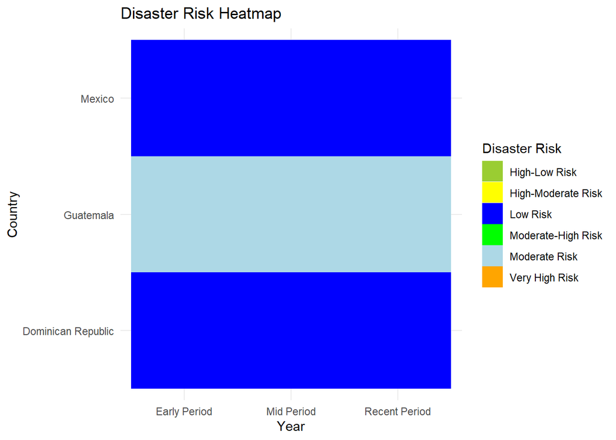

```r
combined_data_america$Year <- as.factor(combined_data_america$Temporal_Class)

heatmap_america <- ggplot(combined_data_america, aes(x = Year, y = Country, fill = Disaster_Risk)) +
  geom_tile() +
  scale_fill_manual(values = c(
    "Extremely High Risk" = "red",
    "Very High Risk" = "orange",
    "High-Moderate Risk" = "yellow",
    "High-Low Risk" = "yellowgreen",
    "Moderate-High Risk" = "green",
    "Moderate Risk" = "lightblue",
    "Low Risk" = "blue",
    "High Risk" = "purple",
    "Clustered Risk" = "skyblue",
    "Moderately High DataCards Risk" = "pink",
    "Moderately Less DataCards Risk" = "violet",
    "Least DataCards Risk" = "grey",
    "Undefined Risk" = "white"
  )) +
  labs(
    title = "Disaster Risk Heatmap",
    x = "Year",
    y = "Country",
    fill = "Disaster Risk"
  ) +
  theme_minimal()
print(heatmap_america)
```

#Cluster 2

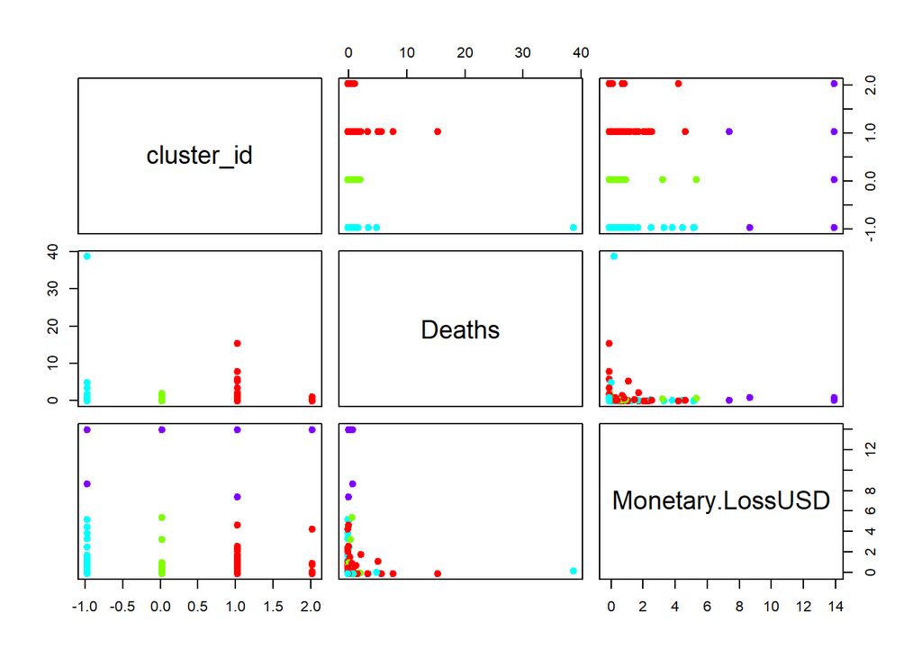

```r
guatemala_c$Country <- "Guatemala"
drepublic_c$Country <- "Drepublic"
mexico_c$Country <- "Mexico"

americas <- rbind(guatemala_c, drepublic_c, mexico_c)
americas$cluster_id <- as.integer(as.character(americas$cluster_id))
data_for_clustering <-americas[, c("cluster_id", "Deaths", "Monetary.LossUSD")]
scaled_data <- scale(data_for_clustering)

set.seed(123)
clara_output <- clara(scaled_data, k = 4, samples = 500)
colors <- rainbow(length(unique(clara_output$clustering)))

scaled_data_with_clusters <- cbind(scaled_data, Cluster = clara_output$clustering)

pairs(scaled_data_with_clusters[, -ncol(scaled_data_with_clusters)],
      col = colors[clara_output$clustering], pch = 19)

legend("left", legend = unique(clara_output$clustering), fill = colors, title = "Clusters")
```

```r
# combine the continents
combined_data <- rbind(transform(asias,Continent = "Asia"),
                       transform(africas, Continent = "Africa"),
                       transform(americas, Continent = "America") )
```

#Visualize the data

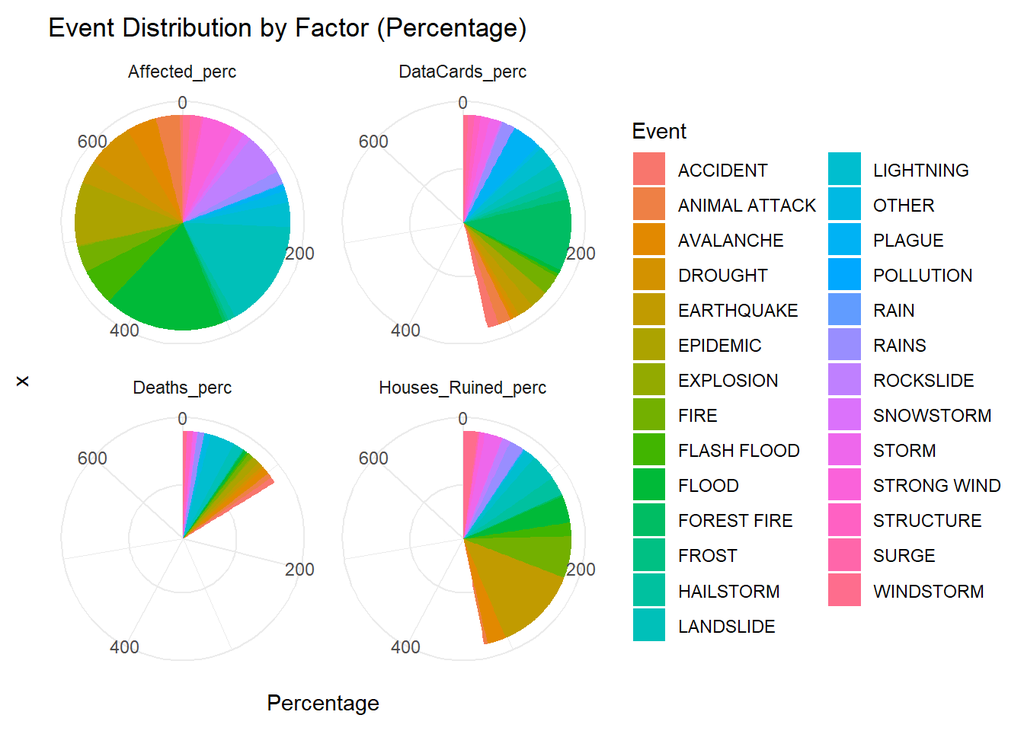

```r
combined_data_perc <- combined_data %>%
  mutate(
    Total = DataCards + Deaths + `Houses.Ruined` + Affected,
    DataCards_perc = DataCards / Total,
    Deaths_perc = Deaths / Total,
    Houses_Ruined_perc = `Houses.Ruined` / Total,
    Affected_perc = Affected / Total
  ) %>%
  select(Event, DataCards_perc, Deaths_perc, Houses_Ruined_perc, Affected_perc)

combined_data_long <- combined_data_perc %>%
  pivot_longer(cols = -Event, names_to = "Factor", values_to = "Percentage")

threshold <- 50

filtered_combined_data_long <- combined_data_long %>%
  group_by(Event) %>%
  summarise(Total_Percentage = sum(Percentage)) %>%
  filter(Total_Percentage > threshold) %>%
  inner_join(asia_long, by = "Event") %>%
  ungroup()

ggplot(filtered_combined_data_long, aes(x = "", y = Percentage, fill = Event)) +
  geom_bar(stat = "identity", width = 1) +
  facet_wrap(~Factor) +
  coord_polar(theta = "y") +
  theme_minimal() +
  ggtitle("Event Distribution by Factor (Percentage)")
```

#Parameters for modelling

```r
# Get only numeric Values
numeric_data <- combined_data[, sapply(combined_data, is.numeric)]

# find PCA
scaled_data <- scale(numeric_data)
pca_result <- prcomp(scaled_data, center = TRUE, scale. = TRUE)
summary(pca_result)
```

```
## Importance of components:
##                           PC1    PC2    PC3    PC4     PC5     PC6     PC7
## Standard deviation     1.5409 1.3533 1.2611 1.1083 1.00347 0.99308 0.94366
## Proportion of Variance 0.2159 0.1665 0.1446 0.1117 0.09154 0.08966 0.08095
## Cumulative Proportion  0.2159 0.3824 0.5269 0.6386 0.73013 0.81978 0.90074
##                            PC8     PC9      PC10      PC11
## Standard deviation     0.86953 0.57950 3.223e-06 1.017e-15
## Proportion of Variance 0.06874 0.03053 0.000e+00 0.000e+00
## Cumulative Proportion  0.96947 1.00000 1.000e+00 1.000e+00
```

```r
formula <- numeric_data$Deaths ~ numeric_data$DataCards + numeric_data$Deaths + numeric_data$Monetary.LossUSD + numeric_data$Event_Severity + numeric_data$Houses.Ruined + numeric_data$Affected+ numeric_data$Total +numeric_data $Combined_Impact
  model <- lm(formula, data = numeric_data)

  vif_result <- car::vif(model)

  cat("\n","VIF results for Deaths", ":\n")
```

```
##
##  VIF results for Deaths :
```

```r
  print(vif_result)
```

```
##                                       GVIF Df GVIF^(1/(2*Df))
## numeric_data$DataCards        1.164196e+00  1    1.078979e+00
## numeric_data$Deaths           9.745189e+20  0             Inf
## numeric_data$Monetary.LossUSD 4.797209e+10  1    2.190253e+05
## numeric_data$Event_Severity   2.008028e+00  1    1.417049e+00
## numeric_data$Houses.Ruined    3.885082e+03  1    6.233043e+01
## numeric_data$Affected         2.000014e+06  1    1.414218e+03
## numeric_data$Total            1.662197e+06  1    1.289262e+03
## numeric_data$Combined_Impact  4.802889e+10  1    2.191549e+05
```

```r
  cat("\n")
```

```r
#check for correlation matrix
cor_matrix <- cor(numeric_data)
print("Correlation matrix ")
```

```
## [1] "Correlation matrix "
```

```r
print(cor_matrix)
```

```
##                          Year    DataCards       Deaths Houses.Ruined
## Year              1.000000000  0.039568043 -0.041416342    0.02458900
## DataCards         0.039568043  1.000000000  0.004226095    0.03167934
## Deaths           -0.041416342  0.004226095  1.000000000    0.26272525
## Houses.Ruined     0.024588998  0.031679337  0.262725249    1.00000000
## Affected          0.025313954  0.034036759  0.125317274    0.12886206
## Monetary.LossUSD -0.009075980  0.015834690  0.050710666    0.07587328
## Event_Severity   -0.108720836 -0.008509646  0.643973330    0.11928375
## Event_factor      0.013333374  0.002825937 -0.025060481   -0.01612091
## Total             0.026180364  0.035498261  0.137066014    0.17188516
## Combined_Impact  -0.008915618  0.016033747  0.051490363    0.07684651
## cluster_id        0.231280556  0.016207832 -0.017435157    0.01554815
##                     Affected Monetary.LossUSD Event_Severity Event_factor
## Year             0.025313954     -0.009075980   -0.108720836  0.013333374
## DataCards        0.034036759      0.015834690   -0.008509646  0.002825937
## Deaths           0.125317274      0.050710666    0.643973330 -0.025060481
## Houses.Ruined    0.128862060      0.075873280    0.119283749 -0.016120911
## Affected         1.000000000      0.094172972    0.100995682  0.012809061
## Monetary.LossUSD 0.094172972      1.000000000    0.073449296 -0.009602342
## Event_Severity   0.100995682      0.073449296    1.000000000 -0.034564352
## Event_factor     0.012809061     -0.009602342   -0.034564352  1.000000000
## Total            0.999052437      0.096909600    0.106247020  0.011992787
## Combined_Impact  0.100036231      0.999982614    0.074035215 -0.009525831
## cluster_id       0.007227836     -0.002959325   -0.039890347 -0.046879872
##                        Total Combined_Impact   cluster_id
## Year             0.026180364    -0.008915618  0.231280556
## DataCards        0.035498261     0.016033747  0.016207832
## Deaths           0.137066014     0.051490363 -0.017435157
## Houses.Ruined    0.171885155     0.076846509  0.015548154
## Affected         0.999052437     0.100036231  0.007227836
## Monetary.LossUSD 0.096909600     0.999982614 -0.002959325
## Event_Severity   0.106247020     0.074035215 -0.039890347
## Event_factor     0.011992787    -0.009525831 -0.046879872
## Total            1.000000000     0.102776840  0.007841939
## Combined_Impact  0.102776840     1.000000000 -0.002911190
## cluster_id       0.007841939    -0.002911190  1.000000000
```

```r
# splitting dataset
set.seed(123)
split_indices <- createDataPartition(numeric_data$Year, p = 0.7, list = FALSE)
training_data_combined <- numeric_data[split_indices, ]
testing_data_combined <- numeric_data[-split_indices, ]
```

#Model 1 enet on MonetaryUSD ~ !MonetaryUSD - 99 % accuracy

```r
train_data <- training_data_combined
test_data <-  testing_data_combined

X_train <- as.matrix(subset(train_data, select =- c(Monetary.LossUSD)))
y_train <- train_data$Monetary.LossUSD
X_test <- as.matrix(subset(test_data, select = - c(Monetary.LossUSD)))
y_test <- test_data$Monetary.LossUSD

X_train_std <- scale(X_train)
X_test_std <- scale(X_test)

enet_model_combined<- cv.glmnet(X_train_std, y_train, alpha = 0.5)

best_lambda <- enet_model_combined$lambda.min

y_pred <- predict(enet_model_combined, newx = X_test_std, s = best_lambda)

mse <- mean((y_pred - y_test)^2)
rsquared <- cor(y_pred, y_test)^2

cat("Best Lambda:", best_lambda, "\n")
```

```
## Best Lambda: 4049919
```

```r
cat("Mean Squared Error:", mse, "\n")
```

```
## Mean Squared Error: 5.069622e+13
```

```r
cat("R-squared:", rsquared, "\n")
```

```
## R-squared: 0.9999863
```

#Visualization of model

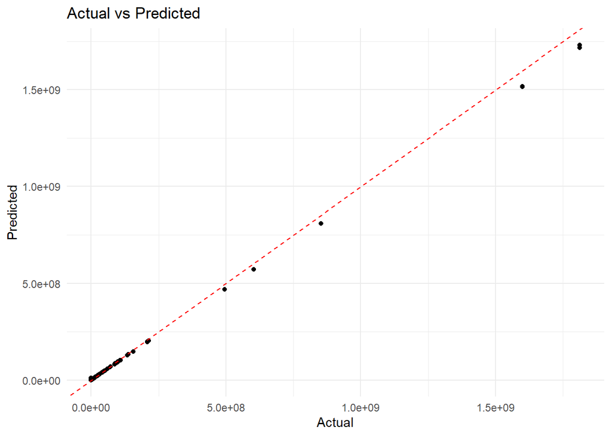

```r
results <- data.frame(
  Actual = y_test,
  Predicted = y_pred
)
ggplot(results, aes(x = Actual, y = s1)) +
  geom_point() +
  geom_abline(intercept = 0, slope = 1, color = "red", linetype = "dashed") +
  labs(x = "Actual", y = "Predicted", title = "Actual vs Predicted") +
  theme_minimal()
```

#Model 2 random forest on death ~ !Event+Death - 85 % accuracy

```r
train_data <- training_data_combined
test_data <-  testing_data_combined

X_train <- as.matrix(subset(train_data, select =- c(Deaths)))
y_train <- train_data$Deaths
X_test <- as.matrix(subset(test_data, select = - c(Deaths)))
y_test <- test_data$Deaths

X_train_std <- scale(X_train)
X_test_std <- scale(X_test)
rf_model_complex <- randomForest(
  X_train, y_train,
  ntree = 1000,
  mtry = sqrt(ncol(X_train)),
  max_depth = NULL
)

y_pred_rf_complex <- predict(rf_model_complex, X_test, type = "response")
mse_rf_complex <- mean((y_pred_rf_complex - y_test)^2)
rsquared_rf_complex <- cor(y_pred_rf_complex, y_test)^2

cat("Random Forest- Mean Squared Error:", mse_rf_complex, "\n")
```

```
## Random Forest- Mean Squared Error: 42974.7
```

```r
cat("Random Forest - R-squared:", rsquared_rf_complex, "\n")
```

```
## Random Forest - R-squared: 0.8525643
```

#Visualization of model

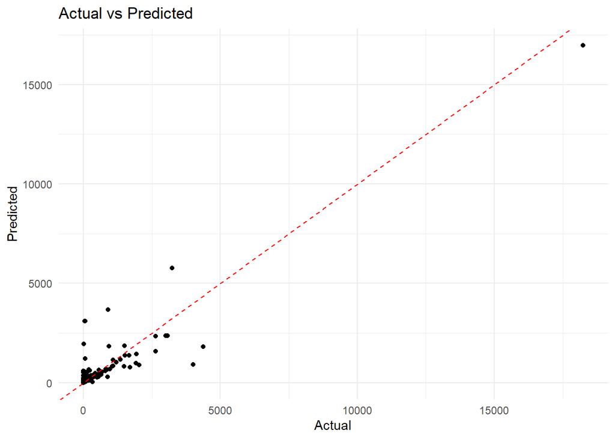

```r
results <- data.frame(
  Actual = y_test,
  Predicted = y_pred_rf_complex
)
ggplot(results, aes(x = Actual, y = Predicted)) +
  geom_point() +
  geom_abline(intercept = 0, slope = 1, color = "red", linetype = "dashed") +
  labs(x = "Actual", y = "Predicted", title = "Actual vs Predicted") +
  theme_minimal()
```

#cluster 1

```r
classify_disaster <- function(severity, impact, cluster) {
  risk_level <- character(length = length(severity))

 for (i in 1:length(severity)) {
    if (severity[i] == "High Severity") {
      if (impact[i] == "Severe Impact") {
        risk_level[i] <- "Moderate-High Risk"
      } else if (impact[i] == "Moderate Impact") {
        risk_level[i] <- "Moderate Risk"
      } else {
        risk_level[i] <- "Low Risk"
      }
    } else if (severity[i] == "Low Severity") {
      if (impact[i] == "Severe Impact") {
        risk_level[i] <- "Moderate-Low Risk"
      } else if (impact[i] == "Moderate Impact") {
        risk_level[i] <- "Low-Moderate Risk"
      } else {
        risk_level[i] <- "Very Low Risk"
      }
    } else {
      risk_level[i] <- "Undefined Risk"
    }
  }

  return(risk_level)
}

  combined_data$Disaster_Class <- classify_disaster(
  combined_data$Severity_Class,
  combined_data$Impact_Class,
  combined_data$cluster_label
)
```

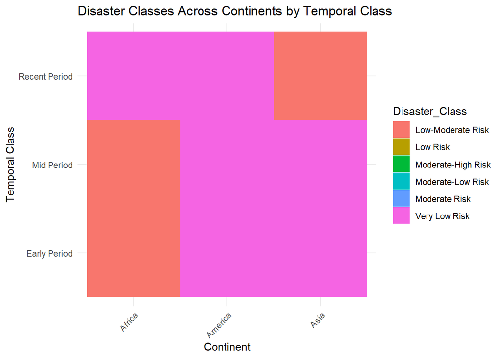

```r
heatmap_disaster_classes <- ggplot(combined_data, aes(x = Continent, y = Temporal_Class, fill = Disaster_Class)) +
  geom_tile() +
  labs(title = "Disaster Classes Across Continents by Temporal Class",
       x = "Continent",
       y = "Temporal Class") +
  theme_minimal() +
  theme(axis.text.x = element_text(angle = 45, hjust = 1))
print(heatmap_disaster_classes)
```

#cluster 2

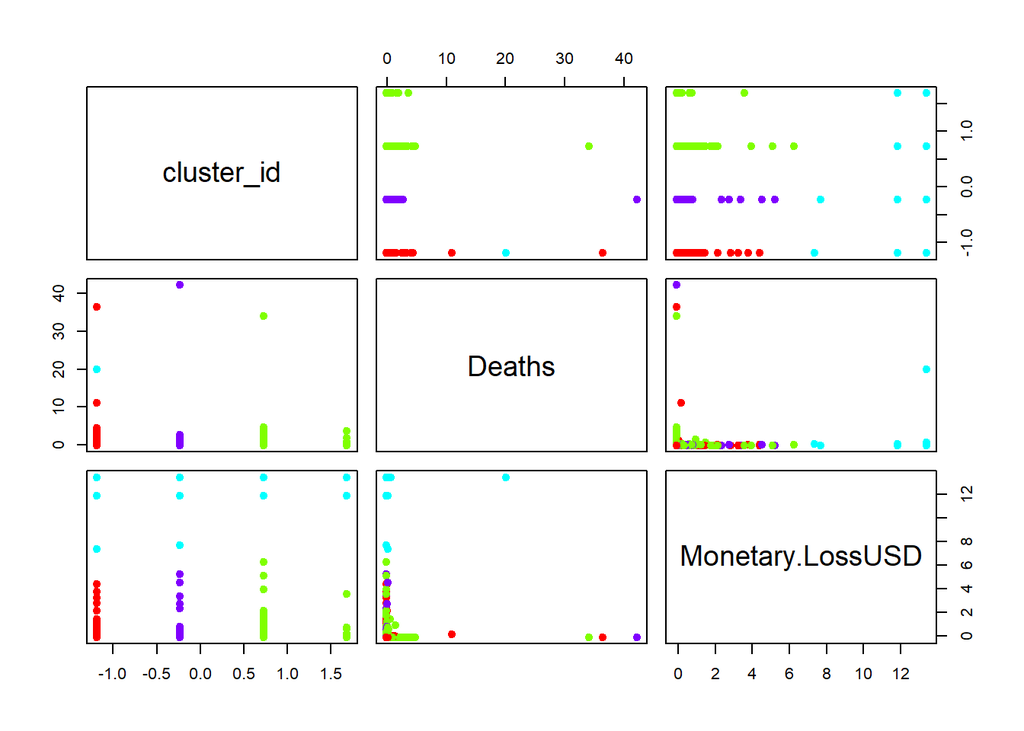

```r
combined_data$cluster_id <- as.integer(as.character(combined_data$cluster_id))
data_for_clustering <- combined_data[, c("cluster_id", "Deaths", "Monetary.LossUSD")]

scaled_data <- scale(data_for_clustering)

set.seed(123)

clara_output <- clara(scaled_data, k = 4, samples = 500)

colors <- rainbow(length(unique(clara_output$clustering)))

scaled_data_with_clusters <- cbind(scaled_data, Cluster = clara_output$clustering)

pairs(scaled_data_with_clusters[, -ncol(scaled_data_with_clusters)],
      col = colors[clara_output$clustering], pch = 19)

legend("topright", legend = unique(clara_output$clustering), fill = colors, title = "Clusters")
```